# Module 10 Weekly Report

Combined export of the latest executed notebooks:

1. `5.0_data_processing_v2_corrected.ipynb`
2. `5.1_modeling_stage1.ipynb`
3. `5.2_stage1_5_and_stage2_modeling.ipynb`

# 5.0 Data Processing

Source notebook: `5.0_data_processing_v2_corrected.ipynb`

# 5.0 Data Processing V2 (2D Cost-Level × Transition Classification)

## Objectives

1. **Data Ingestion & Mapping**: Robust ICD-9/ICD-10 mapping for condition flags across MEPS Panels 18-23 (2013-2019).
2. **Feature Engineering**: Inflation adjustment, medication features, utilization ratios, care phenotype clustering.
3. **2D Target Definition**: 10-class patient classification combining Y1 cost level (Low/Mid/High) with cost transition direction (Improve/Stable/Escalate), with an extra Low_Jumper split.

## Key Design Decision: 2D Classification

A 1D classification using only transition direction groups patients with vastly different cost levels (e.g., Low→Low at $100 and Extreme→Extreme at $50K are both "Stable"). This causes Stage 2 models to struggle with enormous within-group variance.

The 2D approach crosses **Y1 cost level** (3 tiers) with **transition direction**, producing 10 classes where patients share both similar starting costs and similar trajectories. The Low category gets an extra split (MildRise vs Jumper) because low-cost escalators span a wide range.

## Data Requirements

Use panels/files that include both `TOTEXPY1` and `TOTEXPY2` for each person-year. Panels missing either field are skipped during processing.

```python
import pandas as pd
import numpy as np
import matplotlib.pyplot as plt
import seaborn as sns
from pathlib import Path
from sklearn.preprocessing import StandardScaler
from sklearn.cluster import KMeans
from sklearn.metrics import silhouette_score
import warnings

warnings.filterwarnings('ignore')
sns.set_style("whitegrid")
plt.rcParams['figure.dpi'] = 100
plt.rcParams['font.size'] = 11

# --- CONFIGURATION ---
# Use newly parsed data in data/processed_v2 (has Panels 18-21 complete with TOTEXPY1/Y2)
DATA_DIR = Path('../data/processed_v2')
# Fallback to archive for files not yet re-parsed
DATA_DIR_ARCHIVE = Path('../archive_v1/data/processed')
DATA_DIR_NEW = DATA_DIR  # Alias for compatibility
OUTPUT_DIR = Path('../data/processed_v2')
REPORT_DIR = Path('../reports')
OUTPUT_DIR.mkdir(parents=True, exist_ok=True)
REPORT_DIR.mkdir(parents=True, exist_ok=True)
(REPORT_DIR / 'figures').mkdir(exist_ok=True)
(REPORT_DIR / 'tables').mkdir(exist_ok=True)

# Medical CPI Factors (Base 2025)
CPI_FACTORS = {
    2013: 1.45, 2014: 1.41, 2015: 1.37,
    2016: 1.32, 2017: 1.28, 2018: 1.24,
    2019: 1.20, 2020: 1.18
}

# Panel Mapping - IMPORTANT: Panels 22+ have different data structure
# Panels 18-21: Longitudinal files contain BOTH Y1 and Y2 expense data (TOTEXPY1, TOTEXPY2)
# Panels 22+: Longitudinal files only have Y2 data, need Full Year Consolidated for Y1
#
# To use Panel 22: Download HC-201 (2017 Full Year), save as h201.parquet
# To use Panel 23: Download HC-216 (2018 Full Year), save as h216.parquet
#
PANEL_MAP = [
    # All panels now have complete TOTEXPY1 and TOTEXPY2 data
    {'panel': 18, 'long': 'h172', 'cond_y1': 'h162', 'meds_y1': 'h160a', 'year1': 2013, 'naming': 'Y1Y2'},
    {'panel': 19, 'long': 'h183', 'cond_y1': 'h170', 'meds_y1': 'h168a', 'year1': 2014, 'naming': 'Y1Y2'},
    {'panel': 20, 'long': 'h193', 'cond_y1': 'h180', 'meds_y1': 'h178a', 'year1': 2015, 'naming': 'Y1Y2'},
    {'panel': 21, 'long': 'h202', 'cond_y1': 'h190', 'meds_y1': 'h188a', 'year1': 2016, 'naming': 'Y1Y2'},
    {'panel': 22, 'long': 'h210', 'cond_y1': 'h199', 'meds_y1': 'h206a', 'year1': 2017, 'naming': 'Y1Y2'},
    {'panel': 23, 'long': 'h217', 'cond_y1': 'h207', 'meds_y1': 'h206a', 'year1': 2018, 'naming': 'Y1Y2'},
]

ILL_DEFINED_CCS_ICD9 = [str(i) for i in range(245, 260)]

print(f"Setup Complete. Reading from {DATA_DIR}")
print(f"Panels: {[p['panel'] for p in PANEL_MAP]}")
```

```
Setup Complete. Reading from ../data/processed_v2
Panels: [18, 19, 20, 21, 22, 23]
```

```python
def process_panel(pmap):
    """
    Process a single MEPS panel: Load longitudinal data and merge with Conditions/Meds.
    Handles both old (Y1/Y2) and new (year suffix) naming conventions.
    """
    panel = pmap['panel']
    year1 = pmap['year1']
    year2 = year1 + 1
    naming = pmap.get('naming', 'Y1Y2')

    print(f"Processing Panel {panel} ({year1}-{year2})...", end=" ")

    # 1. Load Longitudinal File (check both directories)
    f_long = DATA_DIR / f"{pmap['long']}.parquet"
    if not f_long.exists():
        f_long = DATA_DIR_ARCHIVE / f"{pmap['long']}.parquet"
    if not f_long.exists():
        print(f"SKIP - {pmap['long']}.parquet not found")
        return None
    df_long = pd.read_parquet(f_long)

    # 2. For Panels 22+, check if we need Full Year file for Y1 data
    if naming == 'YEAR' and 'fullyear_y1' in pmap:
        # Check both DATA_DIR and DATA_DIR_NEW for the full year file
        f_fy = DATA_DIR / f"{pmap['fullyear_y1']}.parquet"
        if not f_fy.exists():
            f_fy = DATA_DIR_NEW / f"{pmap['fullyear_y1']}.parquet"

        if f_fy.exists():
            print(f"(merging with {pmap['fullyear_y1']} for Y1)...", end=" ")
            df_fy = pd.read_parquet(f_fy)
            # Merge Y1 expense data from Full Year file
            y1_cols = [c for c in df_fy.columns if 'DUPERSID' in c or f'TOTEXP' in c or 'TOTSLF' in c]
            if y1_cols:
                df_long = df_long.merge(df_fy[['DUPERSID'] + [c for c in y1_cols if c != 'DUPERSID']],
                                        on='DUPERSID', how='left', suffixes=('', '_FY'))
        else:
            # Check if longitudinal file has required Y1 expense columns
            y1_exp_cols = [c for c in df_long.columns if 'TOTEXP' in c and str(year1)[-2:] in c]
            if not y1_exp_cols and 'TOTEXPY1' not in df_long.columns:
                print(f"SKIP - No Y1 expense data (need {pmap['fullyear_y1']}.parquet)")
                return None

    # 3. Conditions (Undiagnosed/Ill-Defined Logic) - check both directories
    f_cond = DATA_DIR / f"{pmap['cond_y1']}.parquet"
    if not f_cond.exists():
        f_cond = DATA_DIR_ARCHIVE / f"{pmap['cond_y1']}.parquet"
    ill_counts = pd.DataFrame({'DUPERSID': [], 'CNT_ILL_DEFINED': []})
    total_conds = pd.DataFrame({'DUPERSID': [], 'CNT_TOTAL_CONDITIONS': []})

    if f_cond.exists():
        df_cond = pd.read_parquet(f_cond)
        mask_ill = pd.Series([False] * len(df_cond))

        if 'CCCODEX' in df_cond.columns:  # ICD-9 (pre-2016)
            df_cond['CCS_CLEAN'] = df_cond['CCCODEX'].astype(str).str.split('.').str[0]
            mask_ill = df_cond['CCS_CLEAN'].isin(ILL_DEFINED_CCS_ICD9)
        elif 'ICD10CDX' in df_cond.columns:  # ICD-10 (2016+)
            mask_ill = df_cond['ICD10CDX'].astype(str).str.startswith('R')

        ill_counts = df_cond[mask_ill].groupby('DUPERSID').size().reset_index(name='CNT_ILL_DEFINED')
        total_conds = df_cond.groupby('DUPERSID').size().reset_index(name='CNT_TOTAL_CONDITIONS')

    df_long = df_long.merge(ill_counts, on='DUPERSID', how='left')
    df_long = df_long.merge(total_conds, on='DUPERSID', how='left')

    # 4. Medications - Enhanced Feature Extraction
    f_meds = DATA_DIR / f"{pmap['meds_y1']}.parquet"
    if not f_meds.exists():
        f_meds = DATA_DIR_ARCHIVE / f"{pmap['meds_y1']}.parquet"

    # Initialize empty medication features dataframe
    med_feats = pd.DataFrame({'DUPERSID': df_long['DUPERSID'].unique()})

    if f_meds.exists():
        df_meds = pd.read_parquet(f_meds)

        # Basic counts
        rx_counts = df_meds.groupby('DUPERSID').size().reset_index(name='CNT_RX_Y1')

        # Unique drugs (polypharmacy indicator)
        if 'RXNDC' in df_meds.columns:
            unique_drugs = df_meds[df_meds['RXNDC'] != '-9'].groupby('DUPERSID')['RXNDC'].nunique().reset_index(name='CNT_UNIQUE_DRUGS')
        else:
            unique_drugs = pd.DataFrame({'DUPERSID': [], 'CNT_UNIQUE_DRUGS': []})

        # Total medication expenditure (find the expenditure column dynamically)
        exp_col = [c for c in df_meds.columns if c.startswith('RXXP') and c.endswith('X')]
        if exp_col:
            df_meds['RX_COST'] = pd.to_numeric(df_meds[exp_col[0]], errors='coerce').fillna(0)
            rx_cost = df_meds.groupby('DUPERSID')['RX_COST'].sum().reset_index(name='TOTAL_RX_COST_Y1')
        else:
            rx_cost = pd.DataFrame({'DUPERSID': [], 'TOTAL_RX_COST_Y1': []})

        # Therapeutic Class Flags (TC1 codes from MEPS Multum Lexicon)
        # TC1=40: Cardiovascular, TC1=57: CNS, TC1=242: Analgesics, TC1=122: Respiratory, TC1=358: GI
        tc_flags = pd.DataFrame({'DUPERSID': df_meds['DUPERSID'].unique()})

        if 'TC1' in df_meds.columns:
            df_meds['TC1_NUM'] = pd.to_numeric(df_meds['TC1'], errors='coerce')

            # Cardiovascular drugs (hypertension, heart disease)
            has_cardio = df_meds[df_meds['TC1_NUM'] == 40].groupby('DUPERSID').size().reset_index(name='_temp')
            has_cardio['HAS_CARDIOVASCULAR_RX'] = 1
            tc_flags = tc_flags.merge(has_cardio[['DUPERSID', 'HAS_CARDIOVASCULAR_RX']], on='DUPERSID', how='left')

            # CNS drugs (includes antidepressants, anxiolytics, etc.)
            has_cns = df_meds[df_meds['TC1_NUM'] == 57].groupby('DUPERSID').size().reset_index(name='_temp')
            has_cns['HAS_CNS_RX'] = 1
            tc_flags = tc_flags.merge(has_cns[['DUPERSID', 'HAS_CNS_RX']], on='DUPERSID', how='left')

            # Pain medications (analgesics - may include opioids)
            has_pain = df_meds[df_meds['TC1_NUM'] == 242].groupby('DUPERSID').size().reset_index(name='_temp')
            has_pain['HAS_PAIN_RX'] = 1
            tc_flags = tc_flags.merge(has_pain[['DUPERSID', 'HAS_PAIN_RX']], on='DUPERSID', how='left')

            # Respiratory drugs (asthma, COPD)
            has_resp = df_meds[df_meds['TC1_NUM'] == 122].groupby('DUPERSID').size().reset_index(name='_temp')
            has_resp['HAS_RESPIRATORY_RX'] = 1
            tc_flags = tc_flags.merge(has_resp[['DUPERSID', 'HAS_RESPIRATORY_RX']], on='DUPERSID', how='left')

            # GI drugs (acid reflux, ulcers, etc.)
            has_gi = df_meds[df_meds['TC1_NUM'] == 358].groupby('DUPERSID').size().reset_index(name='_temp')
            has_gi['HAS_GI_RX'] = 1
            tc_flags = tc_flags.merge(has_gi[['DUPERSID', 'HAS_GI_RX']], on='DUPERSID', how='left')

        # Merge all medication features
        med_feats = med_feats.merge(rx_counts, on='DUPERSID', how='left')
        med_feats = med_feats.merge(unique_drugs, on='DUPERSID', how='left')
        med_feats = med_feats.merge(rx_cost, on='DUPERSID', how='left')
        med_feats = med_feats.merge(tc_flags, on='DUPERSID', how='left')

    df_long = df_long.merge(med_feats, on='DUPERSID', how='left')

    # 5. Fill NaNs and create derived features
    med_cols = ['CNT_RX_Y1', 'CNT_UNIQUE_DRUGS', 'TOTAL_RX_COST_Y1',
                'HAS_CARDIOVASCULAR_RX', 'HAS_CNS_RX', 'HAS_PAIN_RX',
                'HAS_RESPIRATORY_RX', 'HAS_GI_RX']
    for c in med_cols:
        if c in df_long.columns:
            df_long[c] = df_long[c].fillna(0)

    # Polypharmacy flag (5+ unique drugs is a common clinical threshold)
    if 'CNT_UNIQUE_DRUGS' in df_long.columns:
        df_long['POLYPHARMACY_FLAG'] = (df_long['CNT_UNIQUE_DRUGS'] >= 5).astype(int)

    for c in ['CNT_ILL_DEFINED', 'CNT_TOTAL_CONDITIONS']:
        df_long[c] = df_long[c].fillna(0)

    # 6. Map Standard Column Names
    # Two patterns: Y1Y2 (old panels) and YEAR (new panels with year suffix)
    y1s = str(year1)[-2:]  # e.g., '17' for 2017
    y2s = str(year2)[-2:]  # e.g., '18' for 2018

    col_map = {
        # Expenses - try Y1/Y2 format first, then year suffix
        'TOTEXPY1': 'COST_Y1', 'TOTEXPY2': 'COST_Y2',
        f'TOTEXP{y1s}': 'COST_Y1', f'TOTEXP{y2s}': 'COST_Y2',
        # Utilization - Y1/Y2 format
        'ERTOTY1': 'UTIL_ER_Y1', 'IPDISY1': 'UTIL_IP_Y1', 'OBTOTVY1': 'UTIL_OB_Y1', 'RXTOTY1': 'UTIL_RX_Y1',
        # Utilization - year suffix format
        f'ERTOT{y1s}': 'UTIL_ER_Y1', f'IPDIS{y1s}': 'UTIL_IP_Y1', f'OBTOTV{y1s}': 'UTIL_OB_Y1', f'RXTOT{y1s}': 'UTIL_RX_Y1',
        f'ERTOT{y2s}': 'UTIL_ER_Y2', f'IPDIS{y2s}': 'UTIL_IP_Y2', f'OBTOTV{y2s}': 'UTIL_OB_Y2',
        # Demographics
        'SEX': 'SEX', 'RACEV1X': 'RACE', 'RACETHNX': 'RACE',
        'AGE1X': 'AGE_Y1', f'AGE{y2s}X': 'AGE_Y1',  # Use Y2 age for panels 22+
        # Health Status - round based (1,3,5) or (31,42,53)
        'MNHLTH1': 'MNHLTH_RD1', 'MNHLTH3': 'MNHLTH_RD3', 'MNHLTH5': 'MNHLTH_RD5',
        'MNHLTH31': 'MNHLTH_RD1', 'MNHLTH42': 'MNHLTH_RD3', 'MNHLTH53': 'MNHLTH_RD5',
        'RTHLTH1': 'RTHLTH_RD1', 'RTHLTH3': 'RTHLTH_RD3', 'RTHLTH5': 'RTHLTH_RD5',
        'RTHLTH31': 'RTHLTH_RD1', 'RTHLTH42': 'RTHLTH_RD3', 'RTHLTH53': 'RTHLTH_RD5',
        # Chronic Conditions
        'DIABDXY1': 'DIAB_Y1', 'DIABDX': 'DIAB_Y1', f'DIABDX_M{y2s}': 'DIAB_Y1',
        'HIBPDXY1': 'HIBP_Y1', 'HIBPDX': 'HIBP_Y1', f'HIBPDX_M{y2s}': 'HIBP_Y1',
        'CHOLDXY1': 'CHOL_Y1', 'CHOLDX': 'CHOL_Y1', f'CHOLDX_M{y2s}': 'CHOL_Y1',
        'CANCERY1': 'CANCER_Y1', 'CANCERDX': 'CANCER_Y1',
        # SES
        'POVCATY1': 'POVCAT_Y1', f'POVCAT{y2s}': 'POVCAT_Y1',
        'INSCOVY1': 'INSCOV_Y1', f'INSCOV{y2s}': 'INSCOV_Y1',
        'MARRY1X': 'MARRY_Y1', f'MARRY{y2s}X': 'MARRY_Y1',
    }

    for old, new in col_map.items():
        if old in df_long.columns and new not in df_long.columns:
            df_long[new] = df_long[old]

    # 7. Check required columns exist
    required = ['COST_Y1', 'COST_Y2', 'AGE_Y1']
    missing = [c for c in required if c not in df_long.columns or df_long[c].isna().all()]
    if missing:
        print(f"SKIP - Missing required columns: {missing}")
        return None

    df_long['PANEL'] = panel
    df_long['START_YEAR'] = year1

    print(f"OK ({len(df_long):,} rows)")
    return df_long
```

```python
# Process all panels
print("="*60)
print("PROCESSING PANELS")
print("="*60)

all_panels = []
panels_processed = []
panels_skipped = []

for pmap in PANEL_MAP:
    try:
        df_p = process_panel(pmap)
        if df_p is not None:
            all_panels.append(df_p)
            panels_processed.append(pmap['panel'])
        else:
            panels_skipped.append(pmap['panel'])
    except Exception as e:
        print(f"  Panel {pmap['panel']}: ERROR - {e}")
        panels_skipped.append(pmap['panel'])

print("="*60)
print(f"Panels Processed: {panels_processed}")
print(f"Panels Skipped: {panels_skipped}")

if not all_panels:
    raise ValueError("No panels processed! Check data files.")

df = pd.concat(all_panels, ignore_index=True)
print(f"\nCombined Rows: {len(df):,}")

# Filter Adult Cohort (Age >= 18)
if 'AGE_Y1' in df.columns:
    df = df[df['AGE_Y1'] >= 18]
print(f"After Adult Filter (>=18): {len(df):,}")

# Exclude Cancer Y1 (to avoid data leakage)
if 'CANCER_Y1' in df.columns:
    n_cancer = (df['CANCER_Y1'] == 1).sum()
    df = df[df['CANCER_Y1'] != 1]
    print(f"After Cancer Y1 Exclusion: {len(df):,} (removed {n_cancer:,})")

print(f"\n=== Final Cohort Size: {len(df):,} ===")
print(f"Panels included: {sorted(df['PANEL'].unique())}")
print(f"Years: {sorted(df['START_YEAR'].unique())}")
```

```
============================================================
PROCESSING PANELS
============================================================
Processing Panel 18 (2013-2014)... OK (16,714 rows)
Processing Panel 19 (2014-2015)... OK (15,898 rows)
Processing Panel 20 (2015-2016)... OK (17,017 rows)
Processing Panel 21 (2016-2017)... OK (15,617 rows)
Processing Panel 22 (2017-2018)... OK (14,541 rows)
Processing Panel 23 (2018-2019)... OK (14,067 rows)
============================================================
Panels Processed: [18, 19, 20, 21, 22, 23]
Panels Skipped: []

Combined Rows: 93,854
After Adult Filter (>=18): 66,993
After Cancer Y1 Exclusion: 60,602 (removed 6,391)

=== Final Cohort Size: 60,602 ===
Panels included: [np.int64(18), np.int64(19), np.int64(20), np.int64(21), np.int64(22), np.int64(23)]
Years: [np.int64(2013), np.int64(2014), np.int64(2015), np.int64(2016), np.int64(2017), np.int64(2018)]
```

## 6. Data Inspection: Available Features After Processing

Let's visualize which MEPS variables were successfully mapped and are available for modeling.

```python
# Define Feature Groups
feature_groups = {
    'Demographics': ['AGE_Y1', 'SEX', 'RACE', 'MARRY_Y1'],
    'Health Status (Mental)': ['MNHLTH_RD1', 'MNHLTH_RD3', 'MNHLTH_RD5'],
    'Health Status (Physical)': ['RTHLTH_RD1', 'RTHLTH_RD3', 'RTHLTH_RD5'],
    'Chronic Conditions': ['DIAB_Y1', 'HIBP_Y1', 'CHOL_Y1', 'CANCER_Y1'],
    'Utilization (Visits)': ['UTIL_ER_Y1', 'UTIL_IP_Y1', 'UTIL_OP_Y1', 'UTIL_OB_Y1', 'UTIL_RX_Y1'],
    'Cost (Y1/Y2)': ['COST_Y1', 'COST_Y2'],
    'Engineered (Conditions)': ['CNT_TOTAL_CONDITIONS', 'CNT_ILL_DEFINED'],
    'Engineered (Meds)': ['CNT_RX_Y1'],
    'SES': ['POVCAT_Y1', 'INSCOV_Y1']
}

# Check availability
avail_summary = {}
for group, cols in feature_groups.items():
    avail = [c for c in cols if c in df.columns]
    avail_summary[group] = {'available': len(avail), 'total': len(cols), 'cols': avail}
```

### Medication Features (From Prescribed Medicines Files)

We extract clinically meaningful medication patterns from the MEPS Prescribed Medicines files (h160a-h206a).

| Feature | Description | Clinical Significance |
| --- | --- | --- |
| `CNT_RX_Y1` | Total prescription fills | Overall medication burden |
| `CNT_UNIQUE_DRUGS` | Number of different medications | Complexity of regimen |
| `TOTAL_RX_COST_Y1` | Total medication expenditure ($) | Financial burden indicator |
| `POLYPHARMACY_FLAG` | 5+ unique drugs | **High-risk indicator** - associated with adverse drug events |
| `HAS_CARDIOVASCULAR_RX` | Has BP/heart meds (TC1=40) | Hypertension/heart disease treatment |
| `HAS_CNS_RX` | Has CNS drugs (TC1=57) | Neurological/psychiatric treatment |
| `HAS_PAIN_RX` | Has analgesics (TC1=242) | Chronic pain management |
| `HAS_RESPIRATORY_RX` | Has respiratory drugs (TC1=122) | Asthma/COPD treatment |
| `HAS_GI_RX` | Has GI drugs (TC1=358) | Digestive issues treatment |

**Why These Features Matter:**

- **Polypharmacy** (≥5 drugs) is a well-established risk factor for hospitalizations and adverse events
- **Drug class flags** indicate active treatment for specific conditions (more reliable than self-report)
- **Medication cost** captures complexity beyond just counts (expensive drugs often = serious conditions)

*Therapeutic Class codes from MEPS Multum Lexicon Plus drug classification system*

## 7. Feature Engineering

We now engineer derived features:

```python
# 1. Inflation Adjustment
def adjust_cost(row, col):
    year = row['START_YEAR']
    if 'Y2' in col:
        year += 1
    factor = CPI_FACTORS.get(year, 1.0)
    return row[col] * factor

for c in ['COST_Y1', 'COST_Y2']:
    if c in df.columns:
        df[f'{c}_ADJ'] = df.apply(lambda x: adjust_cost(x, c), axis=1)
print("Inflation Adjustment: COST_Y1_ADJ, COST_Y2_ADJ created.")

# 2. Chronic Disease Flags
chronic_cols = ['DIAB_Y1', 'HIBP_Y1', 'CHOL_Y1']
for c in chronic_cols:
    flag_col = f"{c}_FLAG"
    if c in df.columns:
        df[flag_col] = (df[c] == 1).astype(int)
    else:
        df[flag_col] = 0

# 3. Chronic Count
flag_cols = [f"{c}_FLAG" for c in chronic_cols]
df['CHRONIC_COUNT'] = df[flag_cols].sum(axis=1)
print(f"Chronic Flags Created: {flag_cols} -> CHRONIC_COUNT")

# 4. Clean MEPS special missing codes in self-reported health status
health_status_cols = [
    'MNHLTH_RD1', 'MNHLTH_RD3', 'MNHLTH_RD5',
    'RTHLTH_RD1', 'RTHLTH_RD3', 'RTHLTH_RD5',
]
health_status_cols = [c for c in health_status_cols if c in df.columns]
for c in health_status_cols:
    s = pd.to_numeric(df[c], errors='coerce')
    n_special = s.isin([-1, -7, -8, -9]).sum()
    if n_special > 0:
        s = s.mask(s.isin([-1, -7, -8, -9]), np.nan)
        print(f"  {c}: converted {n_special:,} special codes to NaN")
    df[c] = s
if health_status_cols:
    print(f"Health status cleanup complete for {len(health_status_cols)} columns.")

# 5. Utilization Ratios
if 'UTIL_ER_Y1' in df.columns and 'UTIL_OB_Y1' in df.columns:
    df['RATIO_ER_OFFICE'] = df['UTIL_ER_Y1'] / (df['UTIL_OB_Y1'] + 1)
else:
    df['RATIO_ER_OFFICE'] = 0

# 6. 2D Patient Classification: Y1 Cost Level x Transition Direction
all_costs = pd.concat([df['COST_Y1_ADJ'], df['COST_Y2_ADJ']], ignore_index=True)
bp = all_costs.quantile([0.25, 0.50, 0.75, 0.90]).values

BIN_NAMES = {0: 'Low', 1: 'Moderate', 2: 'High', 3: 'Very High', 4: 'Extreme'}

def assign_bin(cost):
    if cost <= bp[0]:
        return 0
    elif cost <= bp[1]:
        return 1
    elif cost <= bp[2]:
        return 2
    elif cost <= bp[3]:
        return 3
    else:
        return 4

df['Y1_BIN'] = df['COST_Y1_ADJ'].apply(assign_bin)
df['Y2_BIN'] = df['COST_Y2_ADJ'].apply(assign_bin)
df['DELTA_BIN'] = df['Y2_BIN'] - df['Y1_BIN']

# Y1 Level: collapse 5 bins into 3 tiers
Y1_LEVEL_MAP = {0: 0, 1: 0, 2: 1, 3: 2, 4: 2}
Y1_LEVEL_NAMES = {0: 'Low', 1: 'Mid', 2: 'High'}
df['Y1_LEVEL'] = df['Y1_BIN'].map(Y1_LEVEL_MAP)

CLASS_NAMES = {
    0: 'Low_Improve',
    1: 'Low_Stable',
    2: 'Low_MildRise',
    3: 'Low_Jumper',
    4: 'Mid_Improve',
    5: 'Mid_Stable',
    6: 'Mid_Escalate',
    7: 'High_Improve',
    8: 'High_Stable',
    9: 'High_Escalate',
}

def assign_risk_class(row):
    lv, delta = row['Y1_LEVEL'], row['DELTA_BIN']
    if lv == 0:
        if delta < 0:
            return 0
        if delta == 0:
            return 1
        if delta == 1:
            return 2
        return 3
    elif lv == 1:
        if delta < 0:
            return 4
        if delta == 0:
            return 5
        return 6
    else:
        if delta < 0:
            return 7
        if delta == 0:
            return 8
        return 9

df['RISK_TIER'] = df.apply(assign_risk_class, axis=1)

print("2D Patient Classification: Y1 Cost Level x Transition Direction")
print()
print("Cost Bin Breakpoints (pooled Y1+Y2 percentiles):")
edges = [0] + list(bp) + [np.inf]
for i in range(5):
    print(f"  Bin {i} ({BIN_NAMES[i]:10s}): ${edges[i]:>10,.0f} - ${edges[i+1]:>10,.0f}")

print()
print("Y1 Level Distribution:")
for lv, lname in Y1_LEVEL_NAMES.items():
    n = (df['Y1_LEVEL'] == lv).sum()
    print(f"  {lname:6s}: {n:>6,} ({n/len(df)*100:.1f}%)")

print()
print("10-Class RISK_TIER Distribution:")
for t, name in CLASS_NAMES.items():
    n = (df['RISK_TIER'] == t).sum()
    mean_y2 = df.loc[df['RISK_TIER'] == t, 'COST_Y2_ADJ'].mean()
    print(f"  {t:2d} ({name:16s}): n={n:>6,} ({n/len(df)*100:.1f}%)  mean_Y2=${mean_y2:>10,.0f}")

# Helper labels used by downstream deep-dive analysis
df['IS_JUMPER'] = (df['DELTA_BIN'] >= 2).astype(int)
df['IS_STABLE_LOW'] = ((df['Y1_BIN'] <= 1) & (df['Y2_BIN'] <= 1)).astype(int)
df['LOG_COST_Y2'] = np.log1p(df['COST_Y2_ADJ'])

print()
print(f"IS_JUMPER (DELTA_BIN >= 2): {df['IS_JUMPER'].sum():,}")
print(f"IS_STABLE_LOW: {df['IS_STABLE_LOW'].sum():,}")
print("Feature Engineering Complete.")
```

```
Inflation Adjustment: COST_Y1_ADJ, COST_Y2_ADJ created.
Chronic Flags Created: ['DIAB_Y1_FLAG', 'HIBP_Y1_FLAG', 'CHOL_Y1_FLAG'] -> CHRONIC_COUNT
  MNHLTH_RD1: converted 240 special codes to NaN
  MNHLTH_RD3: converted 834 special codes to NaN
  MNHLTH_RD5: converted 1,327 special codes to NaN
  RTHLTH_RD1: converted 238 special codes to NaN
  RTHLTH_RD3: converted 823 special codes to NaN
  RTHLTH_RD5: converted 1,324 special codes to NaN
Health status cleanup complete for 6 columns.
2D Patient Classification: Y1 Cost Level x Transition Direction

Cost Bin Breakpoints (pooled Y1+Y2 percentiles):
  Bin 0 (Low       ): $         0 - $       141
  Bin 1 (Moderate  ): $       141 - $     1,273
  Bin 2 (High      ): $     1,273 - $     5,462
  Bin 3 (Very High ): $     5,462 - $    16,665
  Bin 4 (Extreme   ): $    16,665 - $       inf

Y1 Level Distribution:
  Low   : 30,121 (49.7%)
  Mid   : 15,565 (25.7%)
  High  : 14,916 (24.6%)

10-Class RISK_TIER Distribution:
   0 (Low_Improve     ): n= 4,089 (6.7%)  mean_Y2=$        21
   1 (Low_Stable      ): n=15,438 (25.5%)  mean_Y2=$       236
   2 (Low_MildRise    ): n= 7,060 (11.6%)  mean_Y2=$     1,633
   3 (Low_Jumper      ): n= 3,534 (5.8%)  mean_Y2=$    14,002
   4 (Mid_Improve     ): n= 5,268 (8.7%)  mean_Y2=$       484
   5 (Mid_Stable      ): n= 6,220 (10.3%)  mean_Y2=$     2,923
   6 (Mid_Escalate    ): n= 4,077 (6.7%)  mean_Y2=$    18,232
   7 (High_Improve    ): n= 7,310 (12.1%)  mean_Y2=$     3,675
   8 (High_Stable     ): n= 5,841 (9.6%)  mean_Y2=$    29,058
   9 (High_Escalate   ): n= 1,765 (2.9%)  mean_Y2=$    38,199

IS_JUMPER (DELTA_BIN >= 2): 4,690
IS_STABLE_LOW: 22,769
Feature Engineering Complete.
```

## 8. 2D Classification Analysis: Y1 Level × Transition Direction

### 8.1 Transition Heatmap

The heatmap below shows the full 5×5 migration matrix (Y1 bin → Y2 bin). Our 10-class RISK_TIER collapses this into **3 Y1 levels** (Low = bins 0-1, Mid = bin 2, High = bins 3-4) crossed with **transition direction** (Improve/Stable/Escalate). The Low level is further split: MildRise (delta=+1) vs Jumper (delta≥+2), because low-cost escalators span a wide Y2 range.

### 8.2 "The Hidden Risers" (Jumpers)

**Definition:** Patients whose cost bin increased by 2+ levels (e.g., Low → High). These are primarily captured in `Low_Jumper` (class 3) — the most surprising and policy-relevant group.

**Why it matters:** Unlike the old definition (just "Y2 is expensive"), this captures *unexpected escalation* — patients whose costs moved dramatically relative to their starting point.

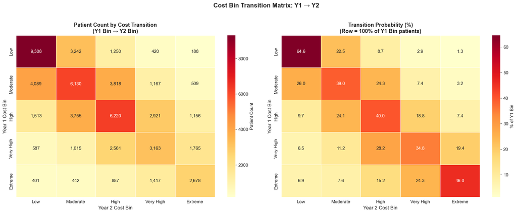

```
10-Class Summary (Y1_Level × Direction):
  Low_Improve     : n= 4,089, Y1=$      505, Y2=$       21, CV=1.85
  Low_Stable      : n=15,438, Y1=$      239, Y2=$      236, CV=1.45
  Low_MildRise    : n= 7,060, Y1=$      380, Y2=$    1,633, CV=0.82
  Low_Jumper      : n= 3,534, Y1=$      333, Y2=$   14,002, CV=2.04
  Mid_Improve     : n= 5,268, Y1=$    2,589, Y2=$      484, CV=0.83
  Mid_Stable      : n= 6,220, Y1=$    2,854, Y2=$    2,923, CV=0.40
  Mid_Escalate    : n= 4,077, Y1=$    3,184, Y2=$   18,232, CV=1.76
  High_Improve    : n= 7,310, Y1=$   21,374, Y2=$    3,675, CV=1.07
  High_Stable     : n= 5,841, Y1=$   28,078, Y2=$   29,058, CV=1.28
  High_Escalate   : n= 1,765, Y1=$   10,261, Y2=$   38,199, CV=0.89
```

```python
# Transition Heatmap: Y1 Bin → Y2 Bin
fig, axes = plt.subplots(1, 2, figsize=(18, 7))

# Panel 1: Count heatmap
ax1 = axes[0]
trans_matrix = pd.crosstab(df['Y1_BIN'], df['Y2_BIN'])
trans_matrix.index = [BIN_NAMES[i] for i in trans_matrix.index]
trans_matrix.columns = [BIN_NAMES[i] for i in trans_matrix.columns]

sns.heatmap(trans_matrix, annot=True, fmt=',d', cmap='YlOrRd', ax=ax1,
            linewidths=0.5, cbar_kws={'label': 'Patient Count'})
ax1.set_xlabel('Year 2 Cost Bin', fontsize=12)
ax1.set_ylabel('Year 1 Cost Bin', fontsize=12)
ax1.set_title('Patient Count by Cost Transition\n(Y1 Bin → Y2 Bin)', fontsize=13, fontweight='bold')

# Panel 2: Percentage heatmap (row-normalized)
ax2 = axes[1]
trans_pct = pd.crosstab(df['Y1_BIN'], df['Y2_BIN'], normalize='index') * 100
trans_pct.index = [BIN_NAMES[i] for i in trans_pct.index]
trans_pct.columns = [BIN_NAMES[i] for i in trans_pct.columns]

sns.heatmap(trans_pct, annot=True, fmt='.1f', cmap='YlOrRd', ax=ax2,
            linewidths=0.5, cbar_kws={'label': '% of Y1 Bin'})
ax2.set_xlabel('Year 2 Cost Bin', fontsize=12)
ax2.set_ylabel('Year 1 Cost Bin', fontsize=12)
ax2.set_title('Transition Probability (%)\n(Row = 100% of Y1 Bin patients)', fontsize=13, fontweight='bold')

plt.suptitle('Cost Bin Transition Matrix: Y1 → Y2', fontsize=15, fontweight='bold', y=1.02)
plt.tight_layout()
plt.savefig(REPORT_DIR / 'figures' / 'transition_heatmap.png', dpi=150, bbox_inches='tight')
plt.show()

# Summary stats for 10-class system
print(f"\n10-Class Summary (Y1_Level × Direction):")
for t, name in CLASS_NAMES.items():
    mask = df['RISK_TIER'] == t
    n = mask.sum()
    mean_y1 = df.loc[mask, 'COST_Y1_ADJ'].mean()
    mean_y2 = df.loc[mask, 'COST_Y2_ADJ'].mean()
    std_y2 = df.loc[mask, 'COST_Y2_ADJ'].std()
    cv = std_y2 / (mean_y2 + 1)
    print(f"  {name:16s}: n={n:>6,}, Y1=${mean_y1:>9,.0f}, Y2=${mean_y2:>9,.0f}, CV={cv:.2f}")
```

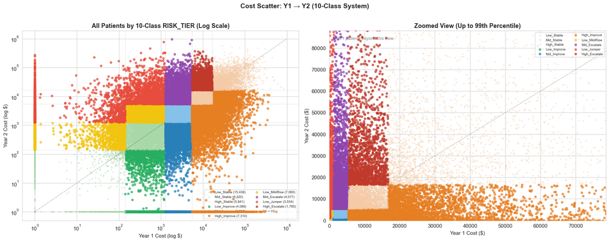

```python
# Viz: Cost Scatter — Color by 10-Class RISK_TIER (Y1 Level × Direction)
class_colors = {
    0: '#27ae60', 1: '#a8d8a8', 2: '#f1c40f', 3: '#e74c3c',
    4: '#2980b9', 5: '#85c1e9', 6: '#8e44ad',
    7: '#e67e22', 8: '#f5cba7', 9: '#c0392b',
}

fig, axes = plt.subplots(1, 2, figsize=(18, 7))

# --- Panel 1: Log-Log Scatter ---
ax1 = axes[0]
x_log = df['COST_Y1_ADJ'].clip(lower=1)
y_log = df['COST_Y2_ADJ'].clip(lower=1)

draw_order = [1, 5, 8, 0, 4, 7, 2, 6, 3, 9]
for t in draw_order:
    mask = df['RISK_TIER'] == t
    if mask.sum() == 0: continue
    is_bg = t in [1, 5, 8]
    ax1.scatter(x_log[mask], y_log[mask], c=class_colors[t], alpha=0.3 if is_bg else 0.7,
                s=6 if is_bg else 18, zorder=t+1, label=f'{CLASS_NAMES[t]} ({mask.sum():,})')

for threshold in bp:
    ax1.axhline(y=max(threshold, 1), color='gray', linestyle=':', linewidth=0.8, alpha=0.5)
    ax1.axvline(x=max(threshold, 1), color='gray', linestyle=':', linewidth=0.8, alpha=0.5)

lims = [1, max(x_log.max(), y_log.max())]
ax1.plot(lims, lims, 'k--', alpha=0.3, linewidth=1, label='Y1 = Y2')
ax1.set_xscale('log'); ax1.set_yscale('log')
ax1.set_xlabel('Year 1 Cost (log $)', fontsize=11)
ax1.set_ylabel('Year 2 Cost (log $)', fontsize=11)
ax1.set_title('All Patients by 10-Class RISK_TIER (Log Scale)', fontsize=13, fontweight='bold')
ax1.legend(loc='lower right', fontsize=7, ncol=2)

# --- Panel 2: Zoomed Linear View ---
ax2 = axes[1]
x_cap = df['COST_Y1_ADJ'].quantile(0.99)
y_cap = df['COST_Y2_ADJ'].quantile(0.99)

for t in draw_order:
    mask = df['RISK_TIER'] == t
    if mask.sum() == 0: continue
    is_bg = t in [1, 5, 8]
    ax2.scatter(df.loc[mask, 'COST_Y1_ADJ'], df.loc[mask, 'COST_Y2_ADJ'],
                c=class_colors[t], alpha=0.3 if is_bg else 0.7,
                s=6 if is_bg else 18, zorder=t+1, label=CLASS_NAMES[t])

ax2.plot([0, max(x_cap, y_cap)], [0, max(x_cap, y_cap)], 'k--', alpha=0.3, linewidth=1)
ax2.set_xlim(0, x_cap); ax2.set_ylim(0, y_cap)
ax2.set_xlabel('Year 1 Cost ($)', fontsize=11)
ax2.set_ylabel('Year 2 Cost ($)', fontsize=11)
ax2.set_title('Zoomed View (Up to 99th Percentile)', fontsize=13, fontweight='bold')
ax2.legend(loc='upper right', fontsize=7, ncol=2)

n_beyond = ((df['COST_Y1_ADJ'] > x_cap) | (df['COST_Y2_ADJ'] > y_cap)).sum()
ax2.text(0.02, 0.97, f'{n_beyond} patients beyond this view', transform=ax2.transAxes,
         fontsize=9, va='top', color='gray', style='italic')

plt.suptitle('Cost Scatter: Y1 → Y2 (10-Class System)', fontsize=14, fontweight='bold', y=1.01)
plt.tight_layout()
plt.savefig(REPORT_DIR / 'figures' / 'transition_scatter.png', dpi=150, bbox_inches='tight')
plt.show()
```

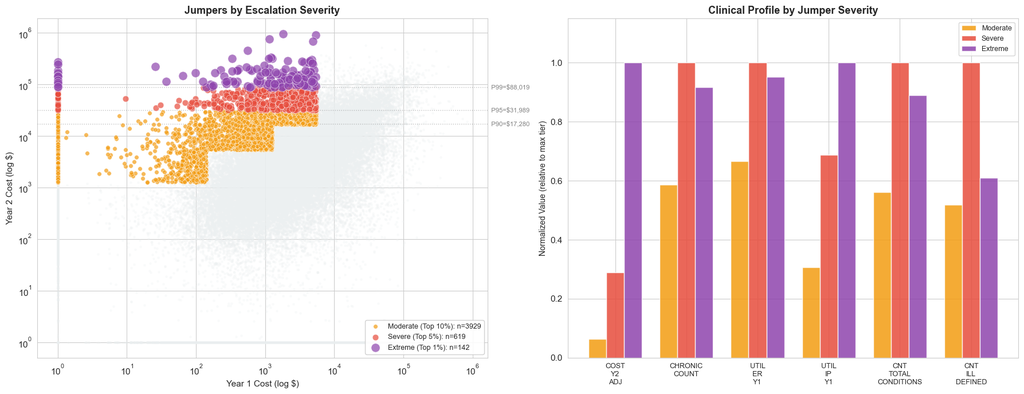

```
Jumper Tier Summary:
                    Count Mean_Y1_Cost Mean_Y2_Cost Median_Y2_Cost Max_Y2_Cost  Mean_Chronic
JUMP_TIER
Moderate (Top 10%)   3929         $822      $10,833         $8,021     $31,933      0.588954
Severe (Top 5%)       619       $2,185      $49,196        $45,362     $87,973      1.004847
Extreme (Top 1%)      142       $1,892     $169,874       $132,533    $956,768      0.922535
```

```python
# Deep Dive: Jumper Tiers by Cost Escalation Magnitude
jumpers = df[df['IS_JUMPER'] == 1].copy()

# Define Jump Tiers based on Y2 cost
y2_p90 = df['COST_Y2_ADJ'].quantile(0.90)
y2_p95 = df['COST_Y2_ADJ'].quantile(0.95)
y2_p99 = df['COST_Y2_ADJ'].quantile(0.99)

def classify_jump(y2_cost):
    if y2_cost >= y2_p99:
        return 'Extreme (Top 1%)'
    elif y2_cost >= y2_p95:
        return 'Severe (Top 5%)'
    else:
        return 'Moderate (Top 10%)'

jumpers['JUMP_TIER'] = jumpers['COST_Y2_ADJ'].apply(classify_jump)

# Tier styling
tier_config = {
    'Moderate (Top 10%)': {'color': '#f39c12', 'size': 30, 'order': 0},
    'Severe (Top 5%)':    {'color': '#e74c3c', 'size': 60, 'order': 1},
    'Extreme (Top 1%)':   {'color': '#8e44ad', 'size': 120, 'order': 2},
}

fig, axes = plt.subplots(1, 2, figsize=(18, 7))

# --- Panel 1: Jumper Scatter by Tier (Log Scale) ---
ax1 = axes[0]

# Background: all non-jumpers
non_j = df[df['IS_JUMPER'] == 0]
ax1.scatter(non_j['COST_Y1_ADJ'].clip(lower=1), non_j['COST_Y2_ADJ'].clip(lower=1),
            c='#ecf0f1', alpha=0.2, s=5, zorder=1)

# Plot each jumper tier (moderate first so extreme is on top)
for tier in ['Moderate (Top 10%)', 'Severe (Top 5%)', 'Extreme (Top 1%)']:
    cfg = tier_config[tier]
    subset = jumpers[jumpers['JUMP_TIER'] == tier]
    ax1.scatter(subset['COST_Y1_ADJ'].clip(lower=1), subset['COST_Y2_ADJ'].clip(lower=1),
                c=cfg['color'], s=cfg['size'], alpha=0.7, edgecolors='white', linewidth=0.5,
                label=f"{tier}: n={len(subset)}", zorder=3 + cfg['order'])

ax1.set_xscale('log')
ax1.set_yscale('log')
ax1.axhline(y=y2_p90, color='gray', linestyle=':', linewidth=1, alpha=0.5)
ax1.axhline(y=y2_p95, color='gray', linestyle=':', linewidth=1, alpha=0.5)
ax1.axhline(y=y2_p99, color='gray', linestyle=':', linewidth=1, alpha=0.5)

# Label thresholds on right edge
for val, label in [(y2_p90, 'P90'), (y2_p95, 'P95'), (y2_p99, 'P99')]:
    ax1.text(ax1.get_xlim()[1] if ax1.get_xlim()[1] > 0 else 500000, val,
             f'  {label}=${val:,.0f}', fontsize=8, va='center', color='gray')

ax1.set_xlabel('Year 1 Cost (log $)', fontsize=11)
ax1.set_ylabel('Year 2 Cost (log $)', fontsize=11)
ax1.set_title('Jumpers by Escalation Severity', fontsize=13, fontweight='bold')
ax1.legend(loc='lower right', fontsize=9, framealpha=0.9)

# --- Panel 2: Jumper Profile Comparison (Bar Chart) ---
ax2 = axes[1]

# Compare key features across tiers
profile_feats = ['COST_Y2_ADJ', 'CHRONIC_COUNT', 'UTIL_ER_Y1', 'UTIL_IP_Y1',
                 'CNT_TOTAL_CONDITIONS', 'CNT_ILL_DEFINED']
profile_feats = [f for f in profile_feats if f in jumpers.columns]

tier_means = jumpers.groupby('JUMP_TIER')[profile_feats].mean()
# Reorder rows
tier_order = ['Moderate (Top 10%)', 'Severe (Top 5%)', 'Extreme (Top 1%)']
tier_means = tier_means.reindex([t for t in tier_order if t in tier_means.index])

# Normalize each feature to [0,1] for comparison
tier_norm = tier_means.copy()
for col in tier_norm.columns:
    col_max = tier_norm[col].max()
    if col_max > 0:
        tier_norm[col] = tier_norm[col] / col_max

# Plot grouped bar chart
x = np.arange(len(profile_feats))
width = 0.25
colors_bar = ['#f39c12', '#e74c3c', '#8e44ad']

for i, (tier, color) in enumerate(zip(tier_order, colors_bar)):
    if tier in tier_norm.index:
        vals = tier_norm.loc[tier].values
        bars = ax2.bar(x + i * width, vals, width, label=tier.split('(')[0].strip(),
                       color=color, edgecolor='white', alpha=0.85)

ax2.set_xticks(x + width)
ax2.set_xticklabels([f.replace('_', '\n') for f in profile_feats], fontsize=9)
ax2.set_ylabel('Normalized Value (relative to max tier)', fontsize=10)
ax2.set_title('Clinical Profile by Jumper Severity', fontsize=13, fontweight='bold')
ax2.legend(fontsize=9)
ax2.set_ylim(0, 1.15)

plt.tight_layout()
plt.savefig(REPORT_DIR / 'figures' / 'jumper_tiers_analysis.png', dpi=150, bbox_inches='tight')
plt.show()

# Print summary table
print("Jumper Tier Summary:")
summary = jumpers.groupby('JUMP_TIER').agg(
    Count=('COST_Y2_ADJ', 'size'),
    Mean_Y1_Cost=('COST_Y1_ADJ', 'mean'),
    Mean_Y2_Cost=('COST_Y2_ADJ', 'mean'),
    Median_Y2_Cost=('COST_Y2_ADJ', 'median'),
    Max_Y2_Cost=('COST_Y2_ADJ', 'max'),
    Mean_Chronic=('CHRONIC_COUNT', 'mean') if 'CHRONIC_COUNT' in jumpers.columns else ('COST_Y1_ADJ', 'size'),
).reindex([t for t in tier_order if t in jumpers['JUMP_TIER'].values])

for col in ['Mean_Y1_Cost', 'Mean_Y2_Cost', 'Median_Y2_Cost', 'Max_Y2_Cost']:
    if col in summary.columns:
        summary[col] = summary[col].apply(lambda x: f'${x:,.0f}')

print(summary.to_string())
```

### Interpretation: Jumper Tier Analysis (Aligned with 2D Target)

**Definition used throughout this project:**

- `IS_JUMPER = 1` when `DELTA_BIN >= 2` (cost-bin increase of at least two bins)
- This is the same escalation concept used in `Low_Jumper` inside the 10-class `RISK_TIER` target

**What the figure above shows:**

**How to read it:**

1. If jumper points concentrate in low-Y1/high-Y2 space, escalation is genuinely sharp, not just high persistent spend.
2. If Severe/Extreme jumpers have higher chronic/utilization burden than Moderate jumpers, Year 1 signals exist before the jump.
3. Overlap with non-jumpers indicates limits of rule-based definitions and motivates probabilistic modeling in Stage 1.

**Modeling implication:**

- Stage 1 predicts the full 10-class transition pattern.
- Stage 2 then models cost *within* those transition classes, rather than treating jumpers as a separate disconnected target.

### 8.2 Feature "Warning Signals"

What distinguishes **Jumpers** from **Stable Low** patients? We compare their Year 1 features to find early indicators.

**Interpretation:**

- A **Relative Risk Ratio > 1** means Jumpers have *higher* average values than Stable Low patients.
- Features with the highest ratios are the strongest "early warning" signals.

```python
# Compare Jumpers vs Stable Low
compare_df = df[(df['IS_JUMPER'] == 1) | (df['IS_STABLE_LOW'] == 1)].copy()

# Features to Compare (only use columns that exist)
candidate_feats = [
    # Demographics & Health Status
    'AGE_Y1', 'CHRONIC_COUNT', 'MNHLTH_RD1', 'RTHLTH_RD1',
    # Healthcare Utilization
    'UTIL_ER_Y1', 'UTIL_IP_Y1', 'UTIL_OB_Y1', 'UTIL_RX_Y1',
    # Condition Complexity
    'CNT_TOTAL_CONDITIONS', 'CNT_ILL_DEFINED',
    # Chronic Disease Flags
    'DIAB_Y1_FLAG', 'HIBP_Y1_FLAG', 'CHOL_Y1_FLAG',
    # Medication Patterns (NEW)
    'CNT_RX_Y1', 'CNT_UNIQUE_DRUGS', 'POLYPHARMACY_FLAG',
    'HAS_CARDIOVASCULAR_RX', 'HAS_CNS_RX', 'HAS_PAIN_RX',
    'HAS_RESPIRATORY_RX', 'HAS_GI_RX', 'TOTAL_RX_COST_Y1'
]
features_to_check = [c for c in candidate_feats if c in compare_df.columns]

print(f"Analyzing {compare_df['IS_JUMPER'].sum()} 'Jumpers' vs {compare_df['IS_STABLE_LOW'].sum()} 'Stable Low' patients.")
print(f"Features Compared: {features_to_check}")

# Calculate Mean Differences
comparison = compare_df.groupby('IS_JUMPER')[features_to_check].mean().T
comparison.columns = ['Stable_Low_Avg', 'Jumper_Avg']
comparison['Rel_Risk_Ratio'] = comparison['Jumper_Avg'] / (comparison['Stable_Low_Avg'] + 0.001)

# Save Table
comparison_sorted = comparison.sort_values('Rel_Risk_Ratio', ascending=False)
comparison_sorted.to_csv(REPORT_DIR / 'tables' / 'feature_risk_ratios.csv')
print(f"Saved feature risk ratios to {REPORT_DIR / 'tables' / 'feature_risk_ratios.csv'}")

display(comparison_sorted.style.background_gradient(cmap='Reds', subset=['Rel_Risk_Ratio']))
```

```
Analyzing 4690 'Jumpers' vs 22769 'Stable Low' patients.
Features Compared: ['AGE_Y1', 'CHRONIC_COUNT', 'MNHLTH_RD1', 'RTHLTH_RD1', 'UTIL_ER_Y1', 'UTIL_IP_Y1', 'UTIL_OB_Y1', 'UTIL_RX_Y1', 'CNT_TOTAL_CONDITIONS', 'CNT_ILL_DEFINED', 'DIAB_Y1_FLAG', 'HIBP_Y1_FLAG', 'CHOL_Y1_FLAG', 'CNT_RX_Y1', 'CNT_UNIQUE_DRUGS', 'POLYPHARMACY_FLAG', 'HAS_CARDIOVASCULAR_RX',…
Saved feature risk ratios to ../reports/tables/feature_risk_ratios.csv
```

|  | Stable_Low_Avg | Jumper_Avg | Rel_Risk_Ratio |
| --- | --- | --- | --- |
| TOTAL_RX_COST_Y1 | 29.269372 | 442.672207 | 15.123559 |
| POLYPHARMACY_FLAG | 0.022311 | 0.189765 | 8.140584 |
| CNT_RX_Y1 | 1.326716 | 7.109595 | 5.354755 |
| UTIL_RX_Y1 | 1.303351 | 5.965885 | 4.573834 |
| HAS_PAIN_RX | 0.017919 | 0.082090 | 4.338978 |
| HAS_GI_RX | 0.039396 | 0.174414 | 4.317632 |
| CNT_UNIQUE_DRUGS | 0.566648 | 2.445416 | 4.307982 |
| HAS_CARDIOVASCULAR_RX | 0.067680 | 0.230064 | 3.349808 |
| UTIL_OB_Y1 | 0.737187 | 2.413006 | 3.268830 |
| DIAB_Y1_FLAG | 0.024902 | 0.083369 | 3.218592 |
| CNT_ILL_DEFINED | 0.059730 | 0.175693 | 2.893002 |
| HAS_RESPIRATORY_RX | 0.027186 | 0.081023 | 2.874590 |
| HAS_CNS_RX | 0.086389 | 0.246269 | 2.818061 |
| CNT_TOTAL_CONDITIONS | 0.949010 | 2.401919 | 2.528310 |
| CHRONIC_COUNT | 0.302077 | 0.653945 | 2.157682 |
| CHOL_Y1_FLAG | 0.120427 | 0.259062 | 2.133480 |
| UTIL_IP_Y1 | 0.001581 | 0.005330 | 2.065203 |
| UTIL_ER_Y1 | 0.048838 | 0.101066 | 2.027879 |
| HIBP_Y1_FLAG | 0.156748 | 0.311514 | 1.974754 |
| AGE_Y1 | 38.199086 | 45.072708 | 1.179911 |
| RTHLTH_RD1 | 2.103061 | 2.317765 | 1.101567 |
| MNHLTH_RD1 | 1.826024 | 1.966709 | 1.076455 |

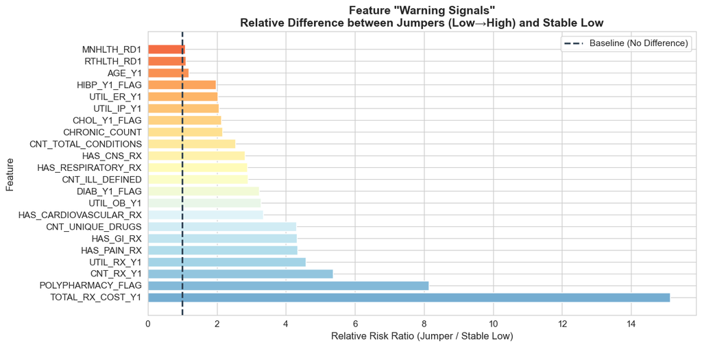

```python
# Visualize Warning Signals
fig, ax = plt.subplots(figsize=(12, 6))

sorted_data = comparison_sorted.reset_index()
colors = plt.cm.RdYlBu_r(np.linspace(0.2, 0.8, len(sorted_data)))

bars = ax.barh(sorted_data['index'], sorted_data['Rel_Risk_Ratio'], color=colors)
ax.axvline(x=1.0, color='#2c3e50', linestyle='--', linewidth=2, label='Baseline (No Difference)')

ax.set_xlabel('Relative Risk Ratio (Jumper / Stable Low)', fontsize=12)
ax.set_ylabel('Feature', fontsize=12)
ax.set_title('Feature "Warning Signals"\nRelative Difference between Jumpers (Low→High) and Stable Low',
             fontsize=14, fontweight='bold')
ax.legend()

plt.tight_layout()
plt.savefig(REPORT_DIR / 'figures' / 'exploratory_risk_ratios.png', dpi=150)
plt.show()
```

### Interpretation: Warning Signal Analysis

The comparison above quantifies which Year 1 features differ between `IS_JUMPER=1` and `IS_STABLE_LOW=1` groups.

Use this table as directional evidence, not a causal claim:

1. Higher chronic burden and diagnosis complexity suggest latent disease progression risk.
2. Higher Rx/utilization intensity can indicate unresolved clinical complexity before large cost jumps.
3. Ill-defined condition counts can flag diagnostic uncertainty that later resolves into high-cost episodes.

**Important guardrail:**

- These are descriptive contrasts from observational data. They should inform feature design and hypothesis generation, not be interpreted as intervention effects.

## 9. Patient Phenotype Clustering

We cluster patients based on **multi-dimensional profiles** combining:

- **Utilization Patterns**: ER, Inpatient, Office, Rx
- **Clinical Complexity**: Chronic conditions, Total conditions
- **Undiagnosed Signals**: Count of ill-defined diagnoses
- **Demographics**: Age

This creates "Care Phenotypes" like:

- **ER Frequent Flyers**: High ER, low primary care
- **Medication Managers**: Many Rx, few visits
- **Complex Chronic**: Multiple conditions, high utilization

### K Selection Strategy (Combined Approach)

**Why NOT just use max Silhouette?**

- Silhouette Score almost always peaks at k=2 (trivial binary split)
- k=2 is not clinically meaningful for patient segmentation

**Our Combined Method:**

1. **Elbow Detection**: Find where Inertia curve "bends" using curvature analysis
2. **Silhouette Validation**: Ensure the chosen k has acceptable cluster separation (> 0.15)
3. **Domain Constraint**: For healthcare phenotypes, k should be in range [3, 7]

```python
# Expanded Features for Clustering (including Medication patterns)
cluster_candidates = [
    # Demographics
    'AGE_Y1',
    # Healthcare Utilization
    'UTIL_ER_Y1', 'UTIL_IP_Y1', 'UTIL_OB_Y1', 'UTIL_RX_Y1',
    # Condition Complexity
    'CNT_TOTAL_CONDITIONS', 'CNT_ILL_DEFINED', 'CHRONIC_COUNT',
    # Medication Patterns (NEW - clinically meaningful)
    'CNT_UNIQUE_DRUGS', 'TOTAL_RX_COST_Y1', 'POLYPHARMACY_FLAG',
    'HAS_CARDIOVASCULAR_RX', 'HAS_CNS_RX', 'HAS_PAIN_RX',
    'HAS_RESPIRATORY_RX', 'HAS_GI_RX',
    # Self-reported Health Status
    'MNHLTH_RD1', 'RTHLTH_RD1'
]

# Use only available columns
cluster_feats = [c for c in cluster_candidates if c in df.columns]
print(f"Clustering Features ({len(cluster_feats)}): {cluster_feats}")

# Prepare Data
X_cluster = df[cluster_feats].copy()
for col in X_cluster.columns:
    if pd.api.types.is_numeric_dtype(X_cluster[col]):
        X_cluster[col] = X_cluster[col].fillna(X_cluster[col].median())
    else:
        X_cluster[col] = X_cluster[col].fillna(0)

scaler = StandardScaler()
X_scaled = scaler.fit_transform(X_cluster)

# Optimization: Run K-Means for range of k
print("\nRunning K-Means Optimization...")
inertia = []
sil_scores = []
k_range = range(2, 10)

for k in k_range:
    km = KMeans(n_clusters=k, random_state=42, n_init=10)
    km.fit(X_scaled)
    inertia.append(km.inertia_)

    if len(df) > 10000:
        sil = silhouette_score(X_scaled, km.labels_, sample_size=5000)
    else:
        sil = silhouette_score(X_scaled, km.labels_)
    sil_scores.append(sil)
    print(f"  k={k}: Inertia={km.inertia_:,.0f}, Silhouette={sil:.3f}")
```

```
Clustering Features (18): ['AGE_Y1', 'UTIL_ER_Y1', 'UTIL_IP_Y1', 'UTIL_OB_Y1', 'UTIL_RX_Y1', 'CNT_TOTAL_CONDITIONS', 'CNT_ILL_DEFINED', 'CHRONIC_COUNT', 'CNT_UNIQUE_DRUGS', 'TOTAL_RX_COST_Y1', 'POLYPHARMACY_FLAG', 'HAS_CARDIOVASCULAR_RX', 'HAS_CNS_RX', 'HAS_PAIN_RX', 'HAS_RESPIRATORY_RX', 'HAS_GI_RX…

Running K-Means Optimization...
  k=2: Inertia=802,336, Silhouette=0.395
  k=3: Inertia=738,339, Silhouette=0.330
  k=4: Inertia=696,926, Silhouette=0.177
  k=5: Inertia=662,367, Silhouette=0.153
  k=6: Inertia=636,553, Silhouette=0.166
  k=7: Inertia=609,761, Silhouette=0.161
  k=8: Inertia=587,193, Silhouette=0.163
  k=9: Inertia=562,238, Silhouette=0.172
```

```python
def find_elbow(k_values, inertia_values):
    """
    Find the elbow point using the "Kneedle" algorithm.

    The elbow is where the rate of decrease sharply changes.
    We use the point of maximum curvature (second derivative).
    """
    k_arr = np.array(list(k_values))
    inertia_arr = np.array(inertia_values)

    # Normalize to [0, 1]
    k_norm = (k_arr - k_arr.min()) / (k_arr.max() - k_arr.min())
    inertia_norm = (inertia_arr - inertia_arr.min()) / (inertia_arr.max() - inertia_arr.min())

    # Calculate distance from each point to the line connecting first and last points
    # Line: from (k_norm[0], inertia_norm[0]) to (k_norm[-1], inertia_norm[-1])
    p1 = np.array([k_norm[0], inertia_norm[0]])
    p2 = np.array([k_norm[-1], inertia_norm[-1]])

    distances = []
    for i in range(len(k_norm)):
        p = np.array([k_norm[i], inertia_norm[i]])
        # Distance from point to line
        d = np.abs(np.cross(p2 - p1, p1 - p)) / np.linalg.norm(p2 - p1)
        distances.append(d)

    # The elbow is the point with maximum distance
    elbow_idx = np.argmax(distances)
    return k_arr[elbow_idx]

# Find elbow point
elbow_k = find_elbow(k_range, inertia)

# Apply domain constraints: k should be in [3, 7] for healthcare phenotypes
MIN_K, MAX_K = 3, 7
if elbow_k < MIN_K:
    elbow_k = MIN_K
    print(f"Elbow k={elbow_k} is too small. Adjusting to minimum domain constraint k={MIN_K}.")
elif elbow_k > MAX_K:
    elbow_k = MAX_K
    print(f"Elbow k={elbow_k} is too large. Adjusting to maximum domain constraint k={MAX_K}.")

# Validate with Silhouette (should be > 0.15 for acceptable separation)
k_idx = list(k_range).index(elbow_k)
elbow_sil = sil_scores[k_idx]

if elbow_sil < 0.15:
    print(f"Warning: Silhouette score at k={elbow_k} is low ({elbow_sil:.3f}).")
    print("Consider reviewing cluster quality or trying different features.")

print(f"\n=== Optimal k Selection ===")
print(f"Elbow Method suggests: k = {elbow_k}")
print(f"Silhouette Score at k={elbow_k}: {elbow_sil:.3f}")
print(f"Domain constraint: [{MIN_K}, {MAX_K}]")
print(f"\nFinal Selected k = {elbow_k}")
```

```
=== Optimal k Selection ===
Elbow Method suggests: k = 5
Silhouette Score at k=5: 0.153
Domain constraint: [3, 7]

Final Selected k = 5
```

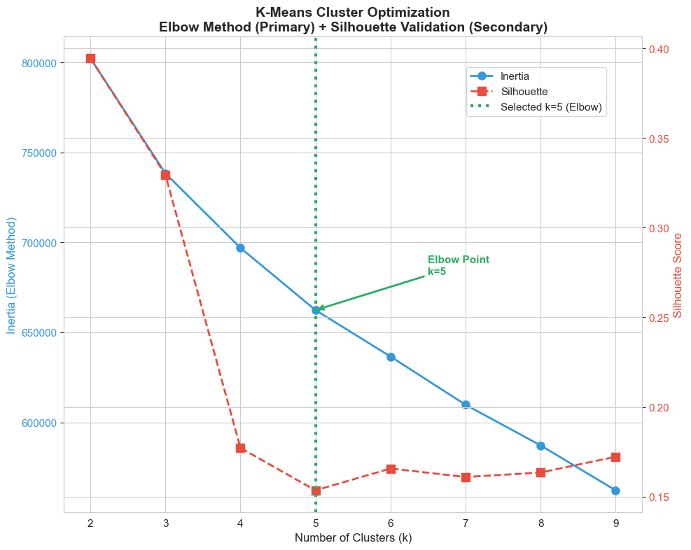

```python
# Dual Axis Plot with Elbow Highlight
fig, ax1 = plt.subplots(figsize=(10, 8))

color1 = '#3498db'
ax1.set_xlabel('Number of Clusters (k)', fontsize=12)
ax1.set_ylabel('Inertia (Elbow Method)', color=color1, fontsize=12)
ax1.plot(k_range, inertia, marker='o', color=color1, linewidth=2, markersize=8, label='Inertia')
ax1.tick_params(axis='y', labelcolor=color1)

ax2 = ax1.twinx()
color2 = '#e74c3c'
ax2.set_ylabel('Silhouette Score', color=color2, fontsize=12)
ax2.plot(k_range, sil_scores, marker='s', linestyle='--', color=color2, linewidth=2, markersize=8, label='Silhouette')
ax2.tick_params(axis='y', labelcolor=color2)

# Highlight the selected k (Elbow-based, not max Silhouette)
ax2.axvline(x=elbow_k, color='#27ae60', linestyle=':', linewidth=3, label=f'Selected k={elbow_k} (Elbow)')

# Add annotation
ax1.annotate(f'Elbow Point\nk={elbow_k}', xy=(elbow_k, inertia[k_idx]),
             xytext=(elbow_k + 1.5, inertia[k_idx] + 20000),
             fontsize=11, color='#27ae60', fontweight='bold',
             arrowprops=dict(arrowstyle='->', color='#27ae60', lw=2))

plt.title('K-Means Cluster Optimization\nElbow Method (Primary) + Silhouette Validation (Secondary)',
          fontsize=14, fontweight='bold')
fig.legend(loc='upper right', bbox_to_anchor=(0.88, 0.88))
plt.tight_layout()
plt.savefig(REPORT_DIR / 'figures' / 'kmeans_optimization.png', dpi=150)
plt.show()
```

### Interpretation: K-Means Optimization (Elbow & Silhouette)

**What the dual-axis plot shows:**

**How to read this:**

**Why we chose k=5 (or the detected value):**

- Balances complexity and interpretability
- Each cluster should represent a distinct "Care Phenotype"
- Clinically meaningful groupings are more useful than statistically optimal but uninterpretable ones

**Important Note:**

- If no clear elbow exists, the data may not have strong natural clusters
- PCA visualization helps confirm whether clusters are visually separable
- DBSCAN (next section) can find clusters of arbitrary shape and identify outliers

```python
# Apply Final Clustering with Elbow-selected k
k_final = elbow_k
km_final = KMeans(n_clusters=k_final, random_state=42, n_init=10)
df['CARE_CLUSTER'] = km_final.fit_predict(X_scaled)

print(f"Applied k={k_final} clusters.")
print(f"\nCluster Distribution:\n{df['CARE_CLUSTER'].value_counts().sort_index()}")
```

```
Applied k=5 clusters.

Cluster Distribution:
CARE_CLUSTER
0    26258
1     9219
2     3248
3     6217
4    15660
Name: count, dtype: int64
```

```python
# Cluster Profile Analysis
cluster_profiles = df.groupby('CARE_CLUSTER')[cluster_feats + ['COST_Y2_ADJ']].mean()
cluster_profiles['COUNT'] = df.groupby('CARE_CLUSTER').size()

print("\n=== Care Phenotype Profiles ===")
display(cluster_profiles.round(2).style.background_gradient(cmap='Blues', axis=0))

# Save profiles
cluster_profiles.to_csv(REPORT_DIR / 'tables' / 'care_cluster_profiles.csv')
print(f"\nSaved cluster profiles to {REPORT_DIR / 'tables' / 'care_cluster_profiles.csv'}")
```

```
=== Care Phenotype Profiles ===
```

| CARE_CLUSTER | AGE_Y1 | UTIL_ER_Y1 | UTIL_IP_Y1 | UTIL_OB_Y1 | UTIL_RX_Y1 | CNT_TOTAL_CONDITIONS | CNT_ILL_DEFINED | CHRONIC_COUNT | CNT_UNIQUE_DRUGS | TOTAL_RX_COST_Y1 | POLYPHARMACY_FLAG | HAS_CARDIOVASCULAR_RX | HAS_CNS_RX | HAS_PAIN_RX | HAS_RESPIRATORY_RX | HAS_GI_RX | MNHLTH_RD1 | RTHLTH_RD1 | COST_Y2_ADJ | COUNT |
| --- | --- | --- | --- | --- | --- | --- | --- | --- | --- | --- | --- | --- | --- | --- | --- | --- | --- | --- | --- | --- |
| 0 | 37.510000 | 0.090000 | 0.030000 | 2.410000 | 1.770000 | 1.270000 | 0.080000 | 0.180000 | 0.750000 | 183.370000 | 0.010000 | 0.040000 | 0.130000 | 0.020000 | 0.040000 | 0.020000 | 1.310000 | 1.540000 | 2680.520000 | 26258 |
| 1 | 63.290000 | 0.200000 | 0.100000 | 7.500000 | 24.650000 | 4.980000 | 0.280000 | 1.940000 | 7.740000 | 2185.690000 | 0.820000 | 0.880000 | 0.430000 | 0.100000 | 0.130000 | 0.870000 | 2.110000 | 2.770000 | 12165.860000 | 9219 |
| 2 | 60.620000 | 1.080000 | 0.650000 | 23.170000 | 70.440000 | 12.410000 | 1.460000 | 1.900000 | 16.520000 | 10206.620000 | 0.990000 | 0.860000 | 0.890000 | 0.550000 | 0.440000 | 0.760000 | 2.910000 | 3.690000 | 33969.440000 | 3248 |
| 3 | 47.100000 | 0.510000 | 0.170000 | 11.990000 | 19.880000 | 5.780000 | 0.580000 | 0.640000 | 6.750000 | 1798.700000 | 0.790000 | 0.330000 | 0.830000 | 0.510000 | 0.340000 | 0.090000 | 2.510000 | 2.770000 | 11551.830000 | 6217 |
| 4 | 43.520000 | 0.160000 | 0.060000 | 2.820000 | 3.220000 | 1.910000 | 0.120000 | 0.560000 | 1.110000 | 297.600000 | 0.010000 | 0.130000 | 0.190000 | 0.030000 | 0.040000 | 0.060000 | 2.700000 | 3.060000 | 3775.240000 | 15660 |

```
Saved cluster profiles to ../reports/tables/care_cluster_profiles.csv
```

### Interpretation: K-Means Cluster Profiles ("Care Phenotypes")

**What the cluster profile table shows:**

- Each row represents a cluster (patient group)
- Columns show mean values for key features within each cluster
- `COST_Y2_ADJ` shows the average Year 2 cost for patients in that cluster
- `COUNT` shows how many patients belong to each cluster

**How to interpret each cluster (example phenotypes):**

| Cluster | Typical Profile | Clinical Label |
| --- | --- | --- |
| **Low Age, Low Chronic, Low Util** | Young, healthy, minimal healthcare use | "Healthy Young Adults" |
| **High Age, High Chronic, High RX** | Elderly with multiple conditions, many medications | "Complex Chronic" |
| **Moderate Age, High ER, Low Office** | ER-dependent, poor primary care engagement | "Crisis Care Seekers" |
| **High Office Visits, Low ER** | Regular check-ups, preventive orientation | "Engaged Patients" |

**Why this matters:**

**Validation check**: Compare mean `COST_Y2_ADJ` across clusters — if clusters have similar costs, they may not be capturing meaningful variation.

## 9.1 Alternative: DBSCAN Clustering (Density-Based)

### Why this section was stabilized

Running DBSCAN on the full cohort can cause kernel crashes on typical laptop memory because density-based neighbor searches scale poorly with sample size in this feature space.

### Stabilized approach used here

1. Fit DBSCAN on a reproducible random subset when the cohort is large.
2. Propagate labels to remaining rows using nearest labeled neighbors within `eps`.
3. Keep unmatched rows as noise (`-1`).

This preserves exploratory value (natural clusters + outlier detection) while avoiding memory-related kernel failure.

```
Large cohort detected (n=60,602).
Using subset for DBSCAN fit: n=15,000.
```

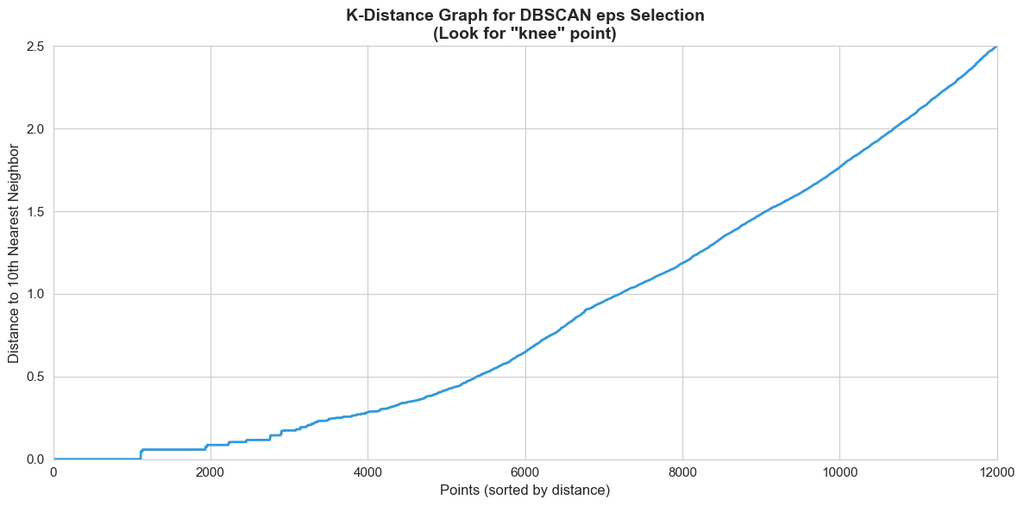

```
Estimated eps (90th percentile): 3.251
```

```python
from sklearn.cluster import DBSCAN
from sklearn.neighbors import NearestNeighbors

# Step 1: Robust eps estimation on a bounded sample to avoid kernel OOM
min_samples = 10  # Reasonable for healthcare data
MAX_DBSCAN_POINTS = 15000

n_total = len(X_scaled)
if n_total > MAX_DBSCAN_POINTS:
    rng = np.random.RandomState(42)
    dbscan_sample_idx = np.sort(rng.choice(n_total, size=MAX_DBSCAN_POINTS, replace=False))
    X_dbscan = X_scaled[dbscan_sample_idx]
    dbscan_is_sampled = True
    print(f"Large cohort detected (n={n_total:,}).")
    print(f"Using subset for DBSCAN fit: n={len(dbscan_sample_idx):,}.")
else:
    dbscan_sample_idx = np.arange(n_total)
    X_dbscan = X_scaled
    dbscan_is_sampled = False
    print(f"Using full cohort for DBSCAN fit: n={n_total:,}.")

# Calculate distances to k nearest neighbors on working matrix
nn = NearestNeighbors(n_neighbors=min_samples, algorithm='ball_tree')
nn.fit(X_dbscan)
distances, _ = nn.kneighbors(X_dbscan)

# Sort the distances to the k-th neighbor
k_distances = np.sort(distances[:, min_samples - 1])

# Plot k-distance graph
fig, ax = plt.subplots(figsize=(12, 6))
ax.plot(range(len(k_distances)), k_distances, color='#3498db', linewidth=2)
ax.set_xlabel('Points (sorted by distance)', fontsize=12)
ax.set_ylabel(f'Distance to {min_samples}th Nearest Neighbor', fontsize=12)
ax.set_title('K-Distance Graph for DBSCAN eps Selection\n(Look for "knee" point)', fontsize=14, fontweight='bold')

# Zoom to relevant region
cutoff = max(int(len(k_distances) * 0.8), 1)
ax.set_xlim(0, cutoff)
ax.set_ylim(0, k_distances[cutoff - 1])

plt.tight_layout()
plt.savefig(REPORT_DIR / 'figures' / 'dbscan_k_distance.png', dpi=150)
plt.show()

# Estimate eps from the upper tail of k-distances
eps_estimate = np.percentile(k_distances, 90)
print()
print(f"Estimated eps (90th percentile): {eps_estimate:.3f}")
```

```python
# Step 2: Run DBSCAN on working matrix, then map labels back to full cohort
# n_jobs=1 is intentionally used for stability on limited-memory environments.
dbscan = DBSCAN(eps=eps_estimate, min_samples=min_samples, algorithm='ball_tree', n_jobs=1)
sample_labels = dbscan.fit_predict(X_dbscan)

# Initialize all rows as noise
labels_full = np.full(len(df), -1, dtype=int)
labels_full[dbscan_sample_idx] = sample_labels

# If sampled fit was used, propagate labels to non-sampled rows by nearest non-noise sampled point
if dbscan_is_sampled:
    all_idx = np.arange(len(df))
    nonsample_idx = all_idx[~np.isin(all_idx, dbscan_sample_idx)]
    core_mask = sample_labels != -1

    print(f"DBSCAN fitted on sample: {len(dbscan_sample_idx):,} rows")
    print(f"Rows to map back: {len(nonsample_idx):,}")

    if core_mask.any() and len(nonsample_idx) > 0:
        nn_map = NearestNeighbors(n_neighbors=1, algorithm='ball_tree')
        nn_map.fit(X_dbscan[core_mask])
        dists, inds = nn_map.kneighbors(X_scaled[nonsample_idx])

        nearest_labels = sample_labels[core_mask][inds[:, 0]]
        mapped_labels = np.where(dists[:, 0] <= eps_estimate, nearest_labels, -1)
        labels_full[nonsample_idx] = mapped_labels.astype(int)

        mapped_pct = (mapped_labels != -1).mean() * 100
        print(f"Mapped non-sampled rows to clusters within eps: {mapped_pct:.1f}%")
    else:
        print("No non-noise sampled cores available for mapping; non-sampled rows kept as noise.")

df['DBSCAN_CLUSTER'] = labels_full

# Analyze results
n_clusters_dbscan = len(set(df['DBSCAN_CLUSTER'])) - (1 if -1 in df['DBSCAN_CLUSTER'].values else 0)
n_noise = (df['DBSCAN_CLUSTER'] == -1).sum()
noise_pct = n_noise / len(df) * 100

print("=== DBSCAN Results ===")
print(f"eps = {eps_estimate:.3f}, min_samples = {min_samples}")
print(f"Number of Clusters: {n_clusters_dbscan}")
print(f"Noise Points: {n_noise:,} ({noise_pct:.1f}%)")
print()
print("Cluster Distribution:")
print(df['DBSCAN_CLUSTER'].value_counts().sort_index())
```

```
DBSCAN fitted on sample: 15,000 rows
Rows to map back: 45,602
Mapped non-sampled rows to clusters within eps: 95.2%
=== DBSCAN Results ===
eps = 3.251, min_samples = 10
Number of Clusters: 2
Noise Points: 3,035 (5.0%)

Cluster Distribution:
DBSCAN_CLUSTER
-1     3035
 0    52485
 1     5082
Name: count, dtype: int64
```

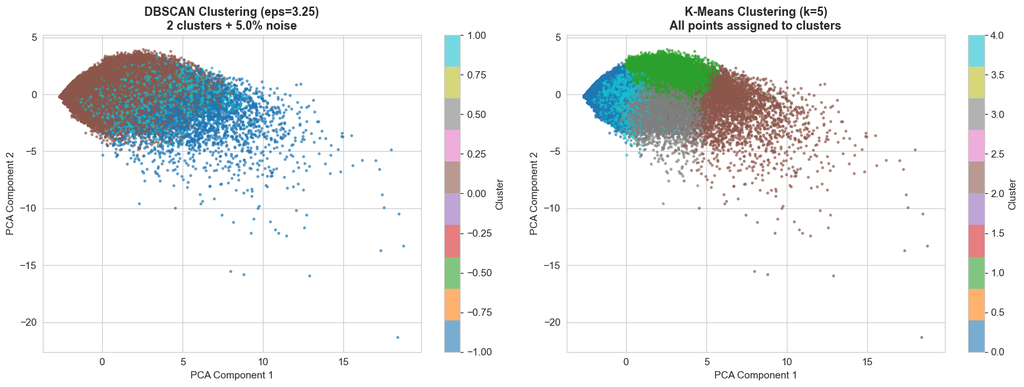

```python
# Step 3: Visualize DBSCAN clusters using PCA
from sklearn.decomposition import PCA

# Reduce to 2D for visualization
pca = PCA(n_components=2)
X_pca = pca.fit_transform(X_scaled)

# Plot
fig, axes = plt.subplots(1, 2, figsize=(16, 6))

# DBSCAN
ax1 = axes[0]
scatter1 = ax1.scatter(X_pca[:, 0], X_pca[:, 1],
                       c=df['DBSCAN_CLUSTER'], cmap='tab10', s=5, alpha=0.6)
ax1.set_xlabel('PCA Component 1', fontsize=11)
ax1.set_ylabel('PCA Component 2', fontsize=11)
ax1.set_title(f'DBSCAN Clustering (eps={eps_estimate:.2f})\n{n_clusters_dbscan} clusters + {noise_pct:.1f}% noise',
              fontsize=13, fontweight='bold')
plt.colorbar(scatter1, ax=ax1, label='Cluster')

# K-Means for comparison
ax2 = axes[1]
scatter2 = ax2.scatter(X_pca[:, 0], X_pca[:, 1],
                       c=df['CARE_CLUSTER'], cmap='tab10', s=5, alpha=0.6)
ax2.set_xlabel('PCA Component 1', fontsize=11)
ax2.set_ylabel('PCA Component 2', fontsize=11)
ax2.set_title(f'K-Means Clustering (k={k_final})\nAll points assigned to clusters',
              fontsize=13, fontweight='bold')
plt.colorbar(scatter2, ax=ax2, label='Cluster')

plt.tight_layout()
plt.savefig(REPORT_DIR / 'figures' / 'dbscan_vs_kmeans.png', dpi=150)
plt.show()
```

```python
# DBSCAN Cluster Profile Analysis
dbscan_profiles = df.groupby('DBSCAN_CLUSTER')[cluster_feats + ['COST_Y2_ADJ']].mean()
dbscan_profiles['COUNT'] = df.groupby('DBSCAN_CLUSTER').size()
dbscan_profiles['PCT'] = (dbscan_profiles['COUNT'] / len(df) * 100).round(1)

print("=== DBSCAN Cluster Profiles (Original Features) ===")
print("Note: Cluster -1 = Noise (atypical patients)\n")
display(dbscan_profiles.round(2).style.background_gradient(cmap='RdYlGn_r', axis=0, subset=['COST_Y2_ADJ']))

# Save profiles
dbscan_profiles.to_csv(REPORT_DIR / 'tables' / 'dbscan_cluster_profiles.csv')
print(f"\nSaved DBSCAN profiles to {REPORT_DIR / 'tables' / 'dbscan_cluster_profiles.csv'}")
```

```
=== DBSCAN Cluster Profiles (Original Features) ===
Note: Cluster -1 = Noise (atypical patients)
```

| DBSCAN_CLUSTER | AGE_Y1 | UTIL_ER_Y1 | UTIL_IP_Y1 | UTIL_OB_Y1 | UTIL_RX_Y1 | CNT_TOTAL_CONDITIONS | CNT_ILL_DEFINED | CHRONIC_COUNT | CNT_UNIQUE_DRUGS | TOTAL_RX_COST_Y1 | POLYPHARMACY_FLAG | HAS_CARDIOVASCULAR_RX | HAS_CNS_RX | HAS_PAIN_RX | HAS_RESPIRATORY_RX | HAS_GI_RX | MNHLTH_RD1 | RTHLTH_RD1 | COST_Y2_ADJ | COUNT | PCT |
| --- | --- | --- | --- | --- | --- | --- | --- | --- | --- | --- | --- | --- | --- | --- | --- | --- | --- | --- | --- | --- | --- |
| -1 | 57.210000 | 1.430000 | 0.880000 | 26.730000 | 58.060000 | 10.470000 | 1.310000 | 1.500000 | 14.000000 | 10600.820000 | 0.890000 | 0.670000 | 0.800000 | 0.490000 | 0.420000 | 0.570000 | 2.780000 | 3.500000 | 34475.810000 | 3035 | 5.000000 |
| 0 | 44.030000 | 0.150000 | 0.050000 | 3.960000 | 7.520000 | 2.430000 | 0.170000 | 0.610000 | 2.390000 | 624.240000 | 0.190000 | 0.230000 | 0.260000 | 0.080000 | 0.000000 | 0.180000 | 1.940000 | 2.260000 | 5093.780000 | 52485 | 86.600000 |
| 1 | 50.170000 | 0.260000 | 0.060000 | 7.400000 | 20.720000 | 5.150000 | 0.370000 | 0.970000 | 7.090000 | 1775.330000 | 0.620000 | 0.430000 | 0.490000 | 0.190000 | 1.000000 | 0.320000 | 2.180000 | 2.680000 | 10199.080000 | 5082 | 8.400000 |

```
Saved DBSCAN profiles to ../reports/tables/dbscan_cluster_profiles.csv
```

### Interpretation: DBSCAN vs K-Means

**Key differences:**

| Aspect | K-Means | DBSCAN |
| --- | --- | --- |
| Cluster Assignment | All points assigned | Low-density points can remain noise (`-1`) |
| Cluster Shape | Spherical bias | Density-based, arbitrary shapes |
| Outlier Handling | No explicit outlier class | Explicit noise detection |

**Implementation note for this notebook:**

- DBSCAN is fit on a bounded sample for stability, then labels are propagated to the remaining rows by nearest-neighbor mapping within `eps`.
- Treat DBSCAN labels as exploratory segmentation features, not ground-truth clinical strata.

## 10. Save Final Dataset

```python
# Final Column Selection
save_cols = [
    'DUPERSID', 'PANEL', 'START_YEAR',
    # Demographics
    'AGE_Y1', 'SEX', 'RACE', 'MARRY_Y1', 'POVCAT_Y1', 'INSCOV_Y1',
    # Health Status
    'MNHLTH_RD1', 'RTHLTH_RD1',
    # Chronic Disease Flags
    'DIAB_Y1_FLAG', 'HIBP_Y1_FLAG', 'CHOL_Y1_FLAG', 'CHRONIC_COUNT',
    # Healthcare Utilization
    'UTIL_ER_Y1', 'UTIL_IP_Y1', 'UTIL_OB_Y1', 'UTIL_RX_Y1',
    # Condition Complexity
    'CNT_TOTAL_CONDITIONS', 'CNT_ILL_DEFINED',
    # Medication Features (NEW)
    'CNT_RX_Y1', 'CNT_UNIQUE_DRUGS', 'TOTAL_RX_COST_Y1', 'POLYPHARMACY_FLAG',
    'HAS_CARDIOVASCULAR_RX', 'HAS_CNS_RX', 'HAS_PAIN_RX',
    'HAS_RESPIRATORY_RX', 'HAS_GI_RX',
    # Engineered Ratios
    'RATIO_ER_OFFICE',
    # Targets & 2D Classification
    'COST_Y1_ADJ', 'COST_Y2_ADJ', 'LOG_COST_Y2',
    'Y1_BIN', 'Y2_BIN', 'DELTA_BIN', 'Y1_LEVEL', 'RISK_TIER',
    # Analysis Labels (both clustering methods)
    'IS_JUMPER', 'IS_STABLE_LOW', 'CARE_CLUSTER', 'DBSCAN_CLUSTER'
]

# Keep only available columns
final_cols = [c for c in save_cols if c in df.columns]
df_final = df[final_cols].copy()

# Save
save_path = OUTPUT_DIR / 'model_ready_v2.parquet'
df_final.to_parquet(save_path)

print(f"\n=== Final Dataset Saved ===")
print(f"Path: {save_path}")
print(f"Rows: {len(df_final):,}")
print(f"Columns ({len(final_cols)}): {final_cols}")
```

```
=== Final Dataset Saved ===
Path: ../data/processed_v2/model_ready_v2.parquet
Rows: 60,602
Columns (43): ['DUPERSID', 'PANEL', 'START_YEAR', 'AGE_Y1', 'SEX', 'RACE', 'MARRY_Y1', 'POVCAT_Y1', 'INSCOV_Y1', 'MNHLTH_RD1', 'RTHLTH_RD1', 'DIAB_Y1_FLAG', 'HIBP_Y1_FLAG', 'CHOL_Y1_FLAG', 'CHRONIC_COUNT', 'UTIL_ER_Y1', 'UTIL_IP_Y1', 'UTIL_OB_Y1', 'UTIL_RX_Y1', 'CNT_TOTAL_CONDITIONS', 'CNT_ILL_DEFIN…
```

## Summary: Data Processing & Feature Engineering (Notebook 5.0)

### What Was Done

1. Panel-level MEPS data were ingested and harmonized into a single modeling table.
2. Costs were inflation-adjusted (`COST_Y1_ADJ`, `COST_Y2_ADJ`) and core clinical/utilization features were engineered.
3. Medication-derived features were added from prescribed-medicines files (counts, cost, polypharmacy, therapeutic classes).
4. Special MEPS missing codes in self-reported health fields (`-1/-7/-8/-9`) were converted to `NaN` for proper downstream imputation.
5. A 10-class 2D transition target (`RISK_TIER`) was built from:
   - Y1 level: Low/Mid/High
   - Direction: Improve/Stable/Escalate
   - Low-level split: MildRise vs Jumper
6. Clustering features were standardized and segmented into care-phenotype labels (`CARE_CLUSTER`, `DBSCAN_CLUSTER`).

### Key Target/Helper Variables

- `RISK_TIER`: 10-class Stage 1 classification target.
- `DELTA_BIN`: Cost-bin movement from Y1 to Y2.
- `IS_JUMPER`: `DELTA_BIN >= 2` (aligned with escalation logic used in Stage 1/2 analysis).
- `LOG_COST_Y2`: Log-transformed Stage 2 regression target helper.

### Output

- Main output file: `../data/processed_v2/model_ready_v2.parquet`
- Table includes original fields plus engineered features, targets, and clustering labels.

### Next Steps

1. Notebook 5.1: Train and interpret the 10-class Stage 1 transition classifier.
2. Notebook 5.2: Build Stage 1.5 enrichment features and Stage 2 expenditure models using leakage-safe routing.

# 5.1 Stage 1 Modeling

Source notebook: `5.1_modeling_stage1.ipynb`

# 5.1 Stage 1: 2D Cost-Level x Transition Classification

**Goal:** Predict each patient's 2D risk class (Y1 cost level x transition direction) from Year 1 features, and generate a continuous `LATENT_RISK_SCORE` for downstream modeling.

**Why 2D?** A 1D transition system groups patients with vastly different cost levels together (e.g., Low->Low at $100 and Extreme->Extreme at $50K are both "Stable"). The 2D system crosses 3 Y1 levels with transition direction, ensuring each class has similar starting cost AND trajectory.

**10-Class Target (`RISK_TIER`):**

- 0 = Low_Improve (Y1 low, cost dropped)
- 1 = Low_Stable (Y1 low, same bin)
- 2 = Low_MildRise (Y1 low, +1 bin)
- 3 = Low_Jumper (Y1 low, +2 or more bins)
- 4 = Mid_Improve (Y1 mid, cost dropped)
- 5 = Mid_Stable (Y1 mid, same bin)
- 6 = Mid_Escalate (Y1 mid, cost increased)
- 7 = High_Improve (Y1 high, cost dropped)
- 8 = High_Stable (Y1 high, same bin)
- 9 = High_Escalate (Y1 high, cost increased)

**Features used:** Demographics (6), Health Status (2), Chronic Conditions (4), Utilization (4), Engineered (3), Medication (9), Clusters (2), Y1 Cost (1).

**Key implication:** Y1 cost is still an important predictor, but transition direction is not determined by cost alone. Clinical/utilization context is needed to separate Improve/Stable/Escalate outcomes within each Y1 level.

```python
import pandas as pd
import numpy as np
import matplotlib.pyplot as plt
import seaborn as sns
from pathlib import Path
import warnings
import json
from datetime import datetime

# Sklearn
from sklearn.model_selection import train_test_split, StratifiedKFold, GroupKFold
from sklearn.base import clone
from sklearn.linear_model import LogisticRegression
from sklearn.ensemble import RandomForestClassifier, GradientBoostingClassifier
from sklearn.metrics import (
    classification_report, confusion_matrix, roc_auc_score,
    f1_score, accuracy_score, brier_score_loss, precision_recall_curve
)
from sklearn.calibration import calibration_curve
from sklearn.isotonic import IsotonicRegression

# Notebook display
from IPython.display import display

# Boosting Models
from xgboost import XGBClassifier

# LightGBM is optional - install with: pip install lightgbm
try:
    from lightgbm import LGBMClassifier
    LIGHTGBM_AVAILABLE = True
    print("LightGBM loaded successfully.")
except ImportError:
    LIGHTGBM_AVAILABLE = False
    print("Note: LightGBM not installed. Using sklearn GradientBoosting as alternative.")
    print("To install: pip install lightgbm")

warnings.filterwarnings('ignore')
sns.set_style('whitegrid')
plt.rcParams['figure.dpi'] = 100
plt.rcParams['font.size'] = 11
np.random.seed(42)

# Explicit run version marker (shown at top of Run All output)
STAGE1_NOTEBOOK_VERSION = 'stage1_decisionlayer_v2026_03_17_r1'

# Resolve repo root robustly (works when cwd is repo root or notebooks/)
CWD = Path.cwd()
if (CWD / 'data' / 'processed_v2').exists():
    REPO_ROOT = CWD
elif (CWD.parent / 'data' / 'processed_v2').exists():
    REPO_ROOT = CWD.parent
else:
    REPO_ROOT = CWD

DATA_PATH = REPO_ROOT / 'data' / 'processed_v2' / 'model_ready_v2.parquet'
OUTPUT_STAGE1_PATH = REPO_ROOT / 'data' / 'processed_v2' / 'model_ready_stage1.parquet'
REPORT_DIR = REPO_ROOT / 'reports'
CANONICAL_NB_PATH = REPO_ROOT / 'notebooks' / '5.1_modeling_stage1.ipynb'
(REPORT_DIR / 'figures').mkdir(parents=True, exist_ok=True)
(REPORT_DIR / 'tables').mkdir(parents=True, exist_ok=True)

print("\nSetup complete.")
print(f"Stage1 notebook version: {STAGE1_NOTEBOOK_VERSION}")
print(f"Canonical notebook path: {CANONICAL_NB_PATH}")
print("Important: run this canonical file (not *.bak backups).")
print(f"Repo root: {REPO_ROOT}")
print(f"Input data: {DATA_PATH}")
print(f"Stage 1 output: {OUTPUT_STAGE1_PATH}")
```

```
Note: LightGBM not installed. Using sklearn GradientBoosting as alternative.
To install: pip install lightgbm

Setup complete.
Stage1 notebook version: stage1_decisionlayer_v2026_03_17_r1
Canonical notebook path: /Users/duanduan/Documents/NEU/ALY6980/healthcare_repo/notebooks/5.1_modeling_stage1.ipynb
Important: run this canonical file (not *.bak backups).
Repo root: /Users/duanduan/Documents/NEU/ALY6980/healthcare_repo
Input data: /Users/duanduan/Documents/NEU/ALY6980/healthcare_repo/data/processed_v2/model_ready_v2.parquet
Stage 1 output: /Users/duanduan/Documents/NEU/ALY6980/healthcare_repo/data/processed_v2/model_ready_stage1.parquet
```

## 1. Load Processed Data

```python
# Load data from preprocessing notebook
df = pd.read_parquet(DATA_PATH)
print(f"Loaded {len(df):,} rows, {len(df.columns)} columns")
print(f"\nColumns: {list(df.columns)}")

CLASS_NAMES = {
    0: 'Low_Improve',   1: 'Low_Stable',    2: 'Low_MildRise',  3: 'Low_Jumper',
    4: 'Mid_Improve',   5: 'Mid_Stable',    6: 'Mid_Escalate',
    7: 'High_Improve',  8: 'High_Stable',   9: 'High_Escalate',
}

print(f"\n{'='*60}")
print("TARGET DISTRIBUTION (RISK_TIER — 2D: Y1 Level × Direction)")
print('='*60)
tier_counts = df['RISK_TIER'].value_counts().sort_index()
tier_pct = (tier_counts / len(df) * 100).round(1)
for tier, count in tier_counts.items():
    label = CLASS_NAMES.get(tier, f'Unknown_{tier}')
    print(f"  {tier:2d} ({label:16s}): {count:>6,} ({tier_pct[tier]}%)")

print(f"\n2D classes: Y1 cost level (Low/Mid/High) × transition direction.")
```

```
Loaded 60,602 rows, 43 columns
```

```
Columns: ['DUPERSID', 'PANEL', 'START_YEAR', 'AGE_Y1', 'SEX', 'RACE', 'MARRY_Y1', 'POVCAT_Y1', 'INSCOV_Y1', 'MNHLTH_RD1', 'RTHLTH_RD1', 'DIAB_Y1_FLAG', 'HIBP_Y1_FLAG', 'CHOL_Y1_FLAG', 'CHRONIC_COUNT', 'UTIL_ER_Y1', 'UTIL_IP_Y1', 'UTIL_OB_Y1', 'UTIL_RX_Y1', 'CNT_TOTAL_CONDITIONS', 'CNT_ILL_DEFINED', …

============================================================
TARGET DISTRIBUTION (RISK_TIER — 2D: Y1 Level × Direction)
============================================================
   0 (Low_Improve     ):  4,089 (6.7%)
   1 (Low_Stable      ): 15,438 (25.5%)
   2 (Low_MildRise    ):  7,060 (11.6%)
   3 (Low_Jumper      ):  3,534 (5.8%)
   4 (Mid_Improve     ):  5,268 (8.7%)
   5 (Mid_Stable      ):  6,220 (10.3%)
   6 (Mid_Escalate    ):  4,077 (6.7%)
   7 (High_Improve    ):  7,310 (12.1%)
   8 (High_Stable     ):  5,841 (9.6%)
   9 (High_Escalate   ):  1,765 (2.9%)

2D classes: Y1 cost level (Low/Mid/High) × transition direction.
```

## 2. Feature Selection & Preparation

We use **Year 1 features only** to predict Year 2 outcomes (no data leakage).

### Feature Groups

| Group | Features | Rationale |
| --- | --- | --- |
| Demographics | AGE, SEX, RACE, MARRY, POVCAT, INSCOV | Basic patient characteristics & SES |
| Health Status | MNHLTH_RD1, RTHLTH_RD1 | Self-reported health & trajectory |
| Chronic Conditions | DIAB, HIBP, CHOL flags, CHRONIC_COUNT | Established disease burden |
| Utilization | ER, IP, OB, RX visits | Care-seeking behavior |
| Condition Complexity | CNT_CONDITIONS, ILL_DEFINED | Medical complexity signals |
| **Medication (NEW)** | **CNT_UNIQUE_DRUGS, POLYPHARMACY, Drug Class Flags** | **Rx patterns = reliable disease markers** |
| Clusters | CARE_CLUSTER, DBSCAN_CLUSTER | Patient phenotype groupings |

### Why Medication Features Matter

- **Polypharmacy (≥5 drugs)**: Strong predictor of hospitalizations and adverse events
- **Drug Class Flags**: More reliable than self-reported conditions (reflects active treatment)
- **CNS/Pain Rx**: May indicate mental health burden or chronic pain (high-cost drivers)
- **Cardiovascular Rx**: Captures hypertension/heart disease being actively managed

```python
# Define feature sets by category
DEMOGRAPHIC_FEATS = ['AGE_Y1', 'SEX', 'RACE', 'MARRY_Y1', 'POVCAT_Y1', 'INSCOV_Y1']
HEALTH_FEATS = ['MNHLTH_RD1', 'RTHLTH_RD1']
CHRONIC_FEATS = ['DIAB_Y1_FLAG', 'HIBP_Y1_FLAG', 'CHOL_Y1_FLAG', 'CHRONIC_COUNT']
UTILIZATION_FEATS = ['UTIL_ER_Y1', 'UTIL_IP_Y1', 'UTIL_OB_Y1', 'UTIL_RX_Y1']
ENGINEERED_FEATS = ['CNT_TOTAL_CONDITIONS', 'CNT_ILL_DEFINED', 'RATIO_ER_OFFICE']

# Medication Features (NEW - clinically meaningful drug patterns)
MEDICATION_FEATS = [
    'CNT_RX_Y1', 'CNT_UNIQUE_DRUGS', 'TOTAL_RX_COST_Y1', 'POLYPHARMACY_FLAG',
    'HAS_CARDIOVASCULAR_RX', 'HAS_CNS_RX', 'HAS_PAIN_RX',
    'HAS_RESPIRATORY_RX', 'HAS_GI_RX'
]

CLUSTER_FEATS = ['CARE_CLUSTER', 'DBSCAN_CLUSTER']
COST_FEATS = ['COST_Y1_ADJ']  # Year 1 cost is allowed (not leakage)

# Combine all features
ALL_FEATURES = (
    DEMOGRAPHIC_FEATS + HEALTH_FEATS + CHRONIC_FEATS +
    UTILIZATION_FEATS + ENGINEERED_FEATS + MEDICATION_FEATS +
    CLUSTER_FEATS + COST_FEATS
)

# Filter to available columns
available_features = [f for f in ALL_FEATURES if f in df.columns]
missing_features = [f for f in ALL_FEATURES if f not in df.columns]

print(f"Features Available: {len(available_features)}")
print(f"Features Missing: {missing_features}")

# Target
TARGET = 'RISK_TIER'

# Keep raw feature matrix (preprocessing is fit on train folds only)
X_raw = df[available_features].copy()
y = df[TARGET].copy().astype(int)

FEATURE_GROUPS = {
    'Demographic': DEMOGRAPHIC_FEATS,
    'Health': HEALTH_FEATS,
    'Chronic': CHRONIC_FEATS,
    'Utilization': UTILIZATION_FEATS,
    'Engineered': ENGINEERED_FEATS,
    'Medication': MEDICATION_FEATS,
    'Clusters': CLUSTER_FEATS,
    'Cost': COST_FEATS,
}

print(f"\nX_raw shape: {X_raw.shape}")
print(f"y shape: {y.shape}")
print(f"\nFeatures used: {available_features}")
```

```
Features Available: 31
Features Missing: []

X_raw shape: (60602, 31)
y shape: (60602,)

Features used: ['AGE_Y1', 'SEX', 'RACE', 'MARRY_Y1', 'POVCAT_Y1', 'INSCOV_Y1', 'MNHLTH_RD1', 'RTHLTH_RD1', 'DIAB_Y1_FLAG', 'HIBP_Y1_FLAG', 'CHOL_Y1_FLAG', 'CHRONIC_COUNT', 'UTIL_ER_Y1', 'UTIL_IP_Y1', 'UTIL_OB_Y1', 'UTIL_RX_Y1', 'CNT_TOTAL_CONDITIONS', 'CNT_ILL_DEFINED', 'RATIO_ER_OFFICE', 'CNT_RX_Y1…
```

```python
# Leakage-safe preprocessing helpers
print("=== Preprocessing (leakage-safe) ===")

def fit_preprocessor(X_fit: pd.DataFrame):
    """Fit preprocessing state using train data only."""
    num_cols = X_fit.select_dtypes(include=[np.number]).columns.tolist()
    cat_cols = [c for c in X_fit.columns if c not in num_cols]

    median_map = X_fit[num_cols].median() if num_cols else pd.Series(dtype=float)

    cat_maps = {}
    for c in cat_cols:
        values = X_fit[c].astype(str).fillna('__MISSING__').unique().tolist()
        cat_maps[c] = {v: i for i, v in enumerate(values)}

    return {
        'num_cols': num_cols,
        'cat_cols': cat_cols,
        'median_map': median_map,
        'cat_maps': cat_maps,
        'columns': X_fit.columns.tolist(),
    }


def apply_preprocessor(X_in: pd.DataFrame, prep: dict):
    """Apply train-fitted preprocessing to any split."""
    X_out = X_in.copy()

    # Keep column order deterministic
    X_out = X_out.reindex(columns=prep['columns'])

    for c in prep['num_cols']:
        X_out[c] = pd.to_numeric(X_out[c], errors='coerce')
        X_out[c] = X_out[c].fillna(prep['median_map'][c])

    for c in prep['cat_cols']:
        mapped = X_out[c].astype(str).map(prep['cat_maps'][c])
        X_out[c] = mapped.fillna(-1).astype(int)

    if 'DBSCAN_CLUSTER' in X_out.columns:
        X_out['DBSCAN_CLUSTER'] = X_out['DBSCAN_CLUSTER'].astype(int)

    return X_out

print("Preprocessor helper functions ready.")
```

```
=== Preprocessing (leakage-safe) ===
Preprocessor helper functions ready.
```

## 3. Train-Test Split

**Split Strategy**:

```python
# Panel-aware split (hold out latest panel)
if 'PANEL' in df.columns:
    available_panels = sorted(df['PANEL'].unique())
    print(f"Available Panels in data: {available_panels}")

    if len(available_panels) >= 2:
        test_panel = max(available_panels)
        train_panels = [p for p in available_panels if p != test_panel]

        train_mask = df['PANEL'].isin(train_panels)
        test_mask = df['PANEL'] == test_panel

        X_train_raw, X_test_raw = X_raw[train_mask].copy(), X_raw[test_mask].copy()
        y_train, y_test = y[train_mask].copy(), y[test_mask].copy()

        if len(X_test_raw) == 0:
            print(f"Warning: Panel {test_panel} has no samples. Using random split...")
            X_train_raw, X_test_raw, y_train, y_test = train_test_split(
                X_raw, y, test_size=0.2, random_state=42, stratify=y
            )
            print(f"Random Split: Train={len(X_train_raw):,}, Test={len(X_test_raw):,}")
        else:
            print(f"\n=== Temporal Split (Panel-based) ===")
            print(f"  Train: Panels {train_panels} ({len(X_train_raw):,} samples)")
            print(f"  Test:  Panel {test_panel} ({len(X_test_raw):,} samples)")
    else:
        X_train_raw, X_test_raw, y_train, y_test = train_test_split(
            X_raw, y, test_size=0.2, random_state=42, stratify=y
        )
        print(f"Single panel only. Random Split: Train={len(X_train_raw):,}, Test={len(X_test_raw):,}")
else:
    X_train_raw, X_test_raw, y_train, y_test = train_test_split(
        X_raw, y, test_size=0.2, random_state=42, stratify=y
    )
    print(f"Random Split (no PANEL column): Train={len(X_train_raw):,}, Test={len(X_test_raw):,}")

# Fit preprocessing on train only, then transform both
main_prep = fit_preprocessor(X_train_raw)
X_train = apply_preprocessor(X_train_raw, main_prep)
X_test = apply_preprocessor(X_test_raw, main_prep)

# Baseline
majority_acc = y_test.value_counts(normalize=True).max()
print(f"\nMajority-class baseline accuracy (test): {majority_acc:.4f}")

# Class distribution check
print(f"\nTrain Target Distribution:")
print(y_train.value_counts(normalize=True).sort_index().round(3))
print(f"\nTest Target Distribution:")
print(y_test.value_counts(normalize=True).sort_index().round(3))
```

```
Available Panels in data: [18, 19, 20, 21, 22, 23]

=== Temporal Split (Panel-based) ===
  Train: Panels [18, 19, 20, 21, 22] (51,464 samples)
  Test:  Panel 23 (9,138 samples)

Majority-class baseline accuracy (test): 0.2149

Train Target Distribution:
RISK_TIER
0    0.069
1    0.262
2    0.119
3    0.059
4    0.086
5    0.101
6    0.066
7    0.117
8    0.093
9    0.028
Name: proportion, dtype: float64

Test Target Distribution:
RISK_TIER
0    0.057
1    0.215
2    0.101
3    0.053
4    0.093
5    0.113
6    0.073
7    0.143
8    0.116
9    0.036
Name: proportion, dtype: float64
```

## 4. Modeling Strategy: Global Baseline + Hierarchical Optimization

We evaluate two Stage 1 strategies:

1. **Global 10-class model** (baseline): directly predict `RISK_TIER`.
2. **Hierarchical model** (optimized):
- `Level` is derived from Year 1 context (`Y1_LEVEL`) and treated as known at prediction time.
- A separate **direction model per level** predicts within-level transitions.
- Final 10-class prediction is reconstructed from `(level, direction)`.

This split improves interpretability:

- Level and direction errors can be analyzed separately.
- Feature importance can be reported per level-specific direction model.

```python
# Define streamlined global baseline models (10-class direct classification)
n_classes = y.nunique()

global_models = {
    'Logistic Regression': LogisticRegression(
        max_iter=3000,
        class_weight='balanced',
        random_state=42
    ),
    'Random Forest': RandomForestClassifier(
        n_estimators=250,
        max_depth=12,
        class_weight='balanced',
        random_state=42,
        n_jobs=-1
    ),
    'XGBoost': XGBClassifier(
        n_estimators=220,
        max_depth=6,
        learning_rate=0.08,
        objective='multi:softprob',
        num_class=n_classes,
        eval_metric='mlogloss',
        random_state=42,
        n_jobs=-1
    ),
}

# Hierarchical definitions
LEVEL_TO_TIERS = {
    0: [0, 1, 2, 3],      # Low: Improve, Stable, MildRise, Jumper
    1: [4, 5, 6],         # Mid: Improve, Stable, Escalate
    2: [7, 8, 9],         # High: Improve, Stable, Escalate
}

LEVEL_NAMES = {0: 'Low', 1: 'Mid', 2: 'High'}

LEVEL_LOCAL_CLASS_NAMES = {
    0: {0: 'Improve', 1: 'Stable', 2: 'MildRise', 3: 'Jumper'},
    1: {0: 'Improve', 1: 'Stable', 2: 'Escalate'},
    2: {0: 'Improve', 1: 'Stable', 2: 'Escalate'},
}

TIER_TO_LOCAL = {
    lvl: {tier: i for i, tier in enumerate(tiers)}
    for lvl, tiers in LEVEL_TO_TIERS.items()
}
LOCAL_TO_TIER = {
    lvl: {i: tier for i, tier in enumerate(tiers)}
    for lvl, tiers in LEVEL_TO_TIERS.items()
}

print(f"Global models to benchmark: {list(global_models.keys())}")
print("Hierarchical route: level-known + level-specific direction RandomForest")
```

```
Global models to benchmark: ['Logistic Regression', 'Random Forest', 'XGBoost']
Hierarchical route: level-known + level-specific direction RandomForest
```

```python
# Train global baseline models and hierarchical model; compare performance
global_results = []
trained_global_models = {}
global_preds = {}
global_probas = {}

for name, model in global_models.items():
    print(f"\n{'='*60}")
    print(f"Training Global Model: {name}")
    print('='*60)

    model.fit(X_train, y_train)
    trained_global_models[name] = model

    y_pred = model.predict(X_test)
    y_pred_proba = model.predict_proba(X_test)

    accuracy = accuracy_score(y_test, y_pred)
    f1_macro = f1_score(y_test, y_pred, average='macro')
    f1_weighted = f1_score(y_test, y_pred, average='weighted')

    try:
        roc_auc = roc_auc_score(y_test, y_pred_proba, multi_class='ovr', average='weighted')
    except Exception:
        roc_auc = np.nan

    global_results.append({
        'Model': name,
        'Strategy': 'Global-10Class',
        'Accuracy': accuracy,
        'F1 (Macro)': f1_macro,
        'F1 (Weighted)': f1_weighted,
        'ROC-AUC (OvR)': roc_auc
    })

    global_preds[name] = y_pred
    global_probas[name] = y_pred_proba

    print(f"  Accuracy:    {accuracy:.4f}")
    print(f"  F1 Macro:    {f1_macro:.4f}")
    print(f"  F1 Weighted: {f1_weighted:.4f}")
    print(f"  ROC-AUC:     {roc_auc:.4f}")

# Hierarchical model (level-known + direction model per level)
print(f"\n{'='*60}")
print("Training Hierarchical Model")
print('='*60)

level_train = df.loc[X_train.index, 'Y1_LEVEL'].astype(int)
level_test = df.loc[X_test.index, 'Y1_LEVEL'].astype(int)

hier_direction_models = {}
hier_level_train_counts = {}

def build_direction_model():
    return RandomForestClassifier(
        n_estimators=300,
        max_depth=12,
        class_weight='balanced',
        random_state=42,
        n_jobs=-1
    )

for lvl, tiers in LEVEL_TO_TIERS.items():
    idx_tr = level_train == lvl
    X_l_tr = X_train.loc[idx_tr]
    y_l_global = y_train.loc[idx_tr]
    y_l_local = y_l_global.map(TIER_TO_LOCAL[lvl]).astype(int)

    hier_level_train_counts[lvl] = len(X_l_tr)

    if y_l_local.nunique() <= 1:
        hier_direction_models[lvl] = {
            'model': None,
            'constant_local_class': int(y_l_local.iloc[0]),
            'tiers': tiers,
            'train_n': len(X_l_tr)
        }
        print(f"  Level={LEVEL_NAMES[lvl]}: constant class only (n={len(X_l_tr):,})")
    else:
        mdl = build_direction_model()
        mdl.fit(X_l_tr, y_l_local)
        hier_direction_models[lvl] = {
            'model': mdl,
            'constant_local_class': None,
            'tiers': tiers,
            'train_n': len(X_l_tr)
        }
        print(f"  Level={LEVEL_NAMES[lvl]}: trained direction model (n={len(X_l_tr):,}, classes={sorted(y_l_local.unique())})")

# Predict hierarchical on test
y_pred_hier = np.full(len(X_test), -1, dtype=int)
y_proba_hier = np.zeros((len(X_test), len(CLASS_NAMES)), dtype=float)

for lvl, bundle in hier_direction_models.items():
    idx_te = np.where(level_test.values == lvl)[0]
    if len(idx_te) == 0:
        continue

    X_l_te = X_test.iloc[idx_te]
    tiers = bundle['tiers']

    if bundle['model'] is None:
        local_pred = np.full(len(idx_te), bundle['constant_local_class'], dtype=int)
        local_proba = np.zeros((len(idx_te), len(tiers)), dtype=float)
        local_proba[:, bundle['constant_local_class']] = 1.0
    else:
        mdl = bundle['model']
        pred_raw = mdl.predict_proba(X_l_te)
        local_proba = np.zeros((len(idx_te), len(tiers)), dtype=float)
        for k, cls_local in enumerate(mdl.classes_):
            local_proba[:, int(cls_local)] = pred_raw[:, k]
        local_pred = local_proba.argmax(axis=1)

    for local_i, tier in LOCAL_TO_TIER[lvl].items():
        y_proba_hier[idx_te, tier] = local_proba[:, local_i]

    y_pred_hier[idx_te] = np.array([LOCAL_TO_TIER[lvl][int(lp)] for lp in local_pred], dtype=int)

hier_accuracy = accuracy_score(y_test, y_pred_hier)
hier_f1_macro = f1_score(y_test, y_pred_hier, average='macro')
hier_f1_weighted = f1_score(y_test, y_pred_hier, average='weighted')

try:
    hier_roc_auc = roc_auc_score(y_test, y_proba_hier, multi_class='ovr', average='weighted')
except Exception:
    hier_roc_auc = np.nan

hier_row = {
    'Model': 'Hierarchical(LevelKnown+DirectionRF)',
    'Strategy': 'Hierarchical',
    'Accuracy': hier_accuracy,
    'F1 (Macro)': hier_f1_macro,
    'F1 (Weighted)': hier_f1_weighted,
    'ROC-AUC (OvR)': hier_roc_auc,
}

print(f"  Accuracy:    {hier_accuracy:.4f}")
print(f"  F1 Macro:    {hier_f1_macro:.4f}")
print(f"  F1 Weighted: {hier_f1_weighted:.4f}")
print(f"  ROC-AUC:     {hier_roc_auc:.4f}")

# Merge comparison table
global_results_df = pd.DataFrame(global_results)
results_df = pd.concat([global_results_df, pd.DataFrame([hier_row])], ignore_index=True)
results_df = results_df.sort_values('F1 (Macro)', ascending=False)

print("\n" + "="*70)
print("STAGE 1 BENCHMARK RESULTS (GLOBAL VS HIERARCHICAL)")
print("="*70)
display(results_df.style.highlight_max(
    axis=0,
    subset=['Accuracy', 'F1 (Macro)', 'F1 (Weighted)', 'ROC-AUC (OvR)'],
    props='background-color: #90EE90'
))

# Select pipeline with performance tolerance for interpretability
best_global = global_results_df.sort_values('F1 (Macro)', ascending=False).iloc[0]
best_global_name = best_global['Model']
best_global_f1 = best_global['F1 (Macro)']

# Prefer hierarchical if it is close enough (<=0.02 macro-F1 loss) for interpretability
if hier_f1_macro >= best_global_f1 - 0.02:
    selected_pipeline = 'Hierarchical'
    selected_model_name = 'Hierarchical(LevelKnown+DirectionRF)'
    y_pred_best = y_pred_hier
    y_proba_best = y_proba_hier
    best_model = None
else:
    selected_pipeline = 'Global'
    selected_model_name = best_global_name
    y_pred_best = global_preds[best_global_name]
    y_proba_best = global_probas[best_global_name]
    best_model = trained_global_models[best_global_name]

print("\n=== Statistical Summary: Model Selection ===")
print(f"Majority-class baseline (test): {majority_acc:.4f}")
print(f"Best global model: {best_global_name} (Macro-F1={best_global_f1:.4f})")
print(f"Hierarchical model Macro-F1: {hier_f1_macro:.4f}")
print(f"Selected pipeline: {selected_pipeline} -> {selected_model_name}")
print("Interpretation: hierarchical model is selected when performance is close enough and explanation quality is better.")

# Controlled ablations for hypothesis testing (global RF fixed)
ablation_rows = []
def eval_subset(cols, label):
    cols = [c for c in cols if c in X_raw.columns]
    Xtr_raw_sub = X_train_raw[cols].copy()
    Xte_raw_sub = X_test_raw[cols].copy()

    prep_sub = fit_preprocessor(Xtr_raw_sub)
    Xtr_sub = apply_preprocessor(Xtr_raw_sub, prep_sub)
    Xte_sub = apply_preprocessor(Xte_raw_sub, prep_sub)

    m = RandomForestClassifier(
        n_estimators=300,
        max_depth=12,
        class_weight='balanced',
        random_state=42,
        n_jobs=-1
    )
    m.fit(Xtr_sub, y_train)
    yp = m.predict(Xte_sub)

    ablation_rows.append({
        'Setup': label,
        'N_Features': len(cols),
        'Accuracy': accuracy_score(y_test, yp),
        'F1 (Macro)': f1_score(y_test, yp, average='macro'),
        'F1 (Weighted)': f1_score(y_test, yp, average='weighted'),
    })

full_feats = available_features.copy()
no_cost_feats = [c for c in full_feats if c != 'COST_Y1_ADJ']
no_cluster_feats = [c for c in full_feats if c not in ['CARE_CLUSTER', 'DBSCAN_CLUSTER']]

eval_subset(['COST_Y1_ADJ'], 'Cost only')
eval_subset(no_cost_feats, 'All except COST_Y1_ADJ')
eval_subset(no_cluster_feats, 'All except clusters')
eval_subset(full_feats, 'All features')

ablation_df = pd.DataFrame(ablation_rows).sort_values('F1 (Macro)', ascending=False)
print("\n=== Controlled Ablation (Global RF, same split) ===")
display(ablation_df)

ab_full = ablation_df.loc[ablation_df['Setup'] == 'All features', 'F1 (Macro)'].iloc[0]
ab_cost = ablation_df.loc[ablation_df['Setup'] == 'Cost only', 'F1 (Macro)'].iloc[0]
ab_nocluster = ablation_df.loc[ablation_df['Setup'] == 'All except clusters', 'F1 (Macro)'].iloc[0]
print(f"Cost-only / Full F1-Macro ratio: {ab_cost / max(ab_full, 1e-12):.3f}")
print(f"Cluster contribution (Full - NoCluster) F1-Macro: {ab_full - ab_nocluster:.4f}")
```

```
============================================================
Training Global Model: Logistic Regression
============================================================
```

```
  Accuracy:    0.4324
  F1 Macro:    0.3737
  F1 Weighted: 0.4280
  ROC-AUC:     0.8873

============================================================
Training Global Model: Random Forest
============================================================
```

```
  Accuracy:    0.4918
  F1 Macro:    0.4366
  F1 Weighted: 0.4868
  ROC-AUC:     0.9211

============================================================
Training Global Model: XGBoost
============================================================
```

```
  Accuracy:    0.5301
  F1 Macro:    0.4010
  F1 Weighted: 0.4853
  ROC-AUC:     0.9230

============================================================
Training Hierarchical Model
============================================================
```

```
  Level=Low: trained direction model (n=26,227, classes=[0, 1, 2, 3])
```

```
  Level=Mid: trained direction model (n=13,014, classes=[0, 1, 2])
```

```
  Level=High: trained direction model (n=12,223, classes=[0, 1, 2])
  Accuracy:    0.4923
  F1 Macro:    0.4349
  F1 Weighted: 0.4867
  ROC-AUC:     0.9219

======================================================================
STAGE 1 BENCHMARK RESULTS (GLOBAL VS HIERARCHICAL)
======================================================================
```

|  | Model | Strategy | Accuracy | F1 (Macro) | F1 (Weighted) | ROC-AUC (OvR) |
| --- | --- | --- | --- | --- | --- | --- |
| 1 | Random Forest | Global-10Class | 0.491793 | 0.436647 | 0.486806 | 0.921061 |
| 3 | Hierarchical(LevelKnown+DirectionRF) | Hierarchical | 0.492340 | 0.434854 | 0.486674 | 0.921853 |
| 2 | XGBoost | Global-10Class | 0.530094 | 0.400981 | 0.485320 | 0.922980 |
| 0 | Logistic Regression | Global-10Class | 0.432370 | 0.373724 | 0.427995 | 0.887286 |

```
=== Statistical Summary: Model Selection ===
Majority-class baseline (test): 0.2149
Best global model: Random Forest (Macro-F1=0.4366)
Hierarchical model Macro-F1: 0.4349
Selected pipeline: Hierarchical -> Hierarchical(LevelKnown+DirectionRF)
Interpretation: hierarchical model is selected when performance is close enough and explanation quality is better.
```

```
=== Controlled Ablation (Global RF, same split) ===
```

|  | Setup | N_Features | Accuracy | F1 (Macro) | F1 (Weighted) |
| --- | --- | --- | --- | --- | --- |
| 3 | All features | 31 | 0.491355 | 0.436146 | 0.486385 |
| 2 | All except clusters | 29 | 0.489494 | 0.434616 | 0.484826 |
| 0 | Cost only | 1 | 0.399869 | 0.367302 | 0.402586 |
| 1 | All except COST_Y1_ADJ | 30 | 0.368680 | 0.304722 | 0.365915 |

```
Cost-only / Full F1-Macro ratio: 0.842
Cluster contribution (Full - NoCluster) F1-Macro: 0.0015
```

### Interpretation: Benchmark and Selection

**What this benchmark is answering**

We are not asking whether Stage 1 can perfectly predict all 10 tiers. We are asking whether Year 1 information contains **usable transition signal beyond baseline cost**, and whether that signal is strong enough to support Stage 2 routing.

**What the results mean in practice**

- The selected hierarchical pipeline is kept because it is nearly tied with the best global model on macro-F1, while being easier to explain in healthcare terms: patients stay within their observed Year 1 cost level, and the model focuses on the harder problem of **direction of movement**.
- The controlled ablation is the key diagnostic. It shows how much of Stage 1 comes from `COST_Y1_ADJ` alone and how much incremental value comes from utilization, chronic burden, medication complexity, and engineered features.
- If the full model beats the cost-only model, that gap is the evidence that we found predictors **outside Y1 cost persistence**. Those non-cost predictors matter more for the report than squeezing a few extra points from threshold tuning.

## 5. Selected Pipeline Analysis

The confusion matrix and class diagnostics below are based on the **selected Stage 1 pipeline** from the benchmark step.

```
Selected Pipeline: Hierarchical
Selected Model Name: Hierarchical(LevelKnown+DirectionRF)
```

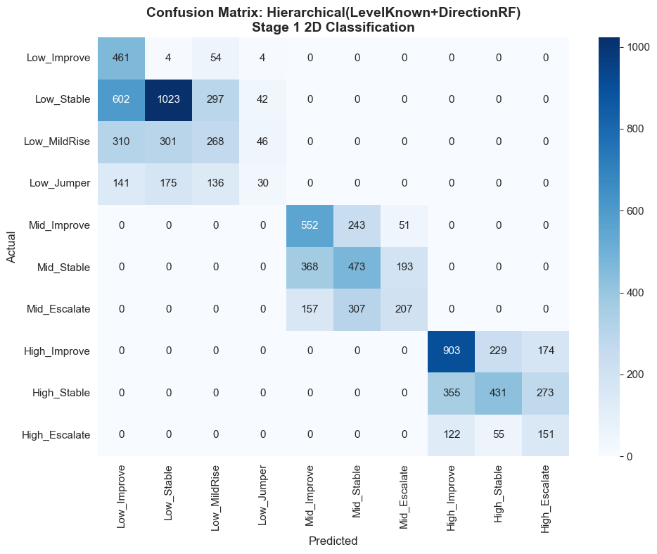

```
==================================================
CLASSIFICATION REPORT
==================================================
               precision    recall  f1-score   support

  Low_Improve       0.30      0.88      0.45       523
   Low_Stable       0.68      0.52      0.59      1964
 Low_MildRise       0.35      0.29      0.32       925
   Low_Jumper       0.25      0.06      0.10       482
  Mid_Improve       0.51      0.65      0.57       846
   Mid_Stable       0.46      0.46      0.46      1034
 Mid_Escalate       0.46      0.31      0.37       671
 High_Improve       0.65      0.69      0.67      1306
  High_Stable       0.60      0.41      0.49      1059
High_Escalate       0.25      0.46      0.33       328

     accuracy                           0.49      9138
    macro avg       0.45      0.47      0.43      9138
 weighted avg       0.52      0.49      0.49      9138


=== KEY METRICS: LEVEL vs DIRECTION ===
```

|  | Task | Accuracy | Macro-F1 |
| --- | --- | --- | --- |
| 0 | LEVEL (3-class) | 1.000000 | 1.000000 |
| 1 | DIRECTION (3-class) | 0.512257 | 0.497189 |

```
Interpretation: LEVEL is expected to be easier; DIRECTION is the true challenge.

=== Within-Level Direction Performance ===
```

|  | Level | N | Accuracy | Macro-F1 |
| --- | --- | --- | --- | --- |
| 0 | Low | 3894 | 0.457627 | 0.365287 |
| 1 | Mid | 2551 | 0.482948 | 0.467660 |
| 2 | High | 2693 | 0.551430 | 0.494806 |

```
=== Rare Class Diagnostics ===
  Low_Jumper      : precision=0.246, recall=0.062, f1=0.099, support=482
  High_Escalate   : precision=0.253, recall=0.460, f1=0.326, support=328

Top confusion pairs (count, row_pct):
  Low_Stable       -> Low_Improve     :  602 (0.307)
  Mid_Stable       -> Mid_Improve     :  368 (0.356)
  High_Stable      -> High_Improve    :  355 (0.335)
  Low_MildRise     -> Low_Improve     :  310 (0.335)
  Mid_Escalate     -> Mid_Stable      :  307 (0.458)
  Low_MildRise     -> Low_Stable      :  301 (0.325)
  Low_Stable       -> Low_MildRise    :  297 (0.151)
  High_Stable      -> High_Escalate   :  273 (0.258)
```

```python
# Analyze selected Stage 1 pipeline
print(f"Selected Pipeline: {selected_pipeline}")
print(f"Selected Model Name: {selected_model_name}")

class_labels = [CLASS_NAMES[i] for i in sorted(df['RISK_TIER'].unique())]

fig, ax = plt.subplots(figsize=(10, 8))
cm = confusion_matrix(y_test, y_pred_best, labels=sorted(CLASS_NAMES.keys()))
sns.heatmap(cm, annot=True, fmt='d', cmap='Blues', ax=ax,
            xticklabels=class_labels, yticklabels=class_labels)
ax.set_xlabel('Predicted', fontsize=12)
ax.set_ylabel('Actual', fontsize=12)
ax.set_title(f'Confusion Matrix: {selected_model_name}\nStage 1 2D Classification', fontsize=14, fontweight='bold')
plt.tight_layout()
plt.savefig(REPORT_DIR / 'figures' / 'confusion_matrix_Random_Forest.png', dpi=150)
plt.show()

print("\n" + "="*50)
print("CLASSIFICATION REPORT")
print("="*50)
print(classification_report(y_test, y_pred_best, target_names=class_labels))

# Task decomposition: Level vs Direction
LEVEL_MAP = {
    0: 'Low', 1: 'Low', 2: 'Low', 3: 'Low',
    4: 'Mid', 5: 'Mid', 6: 'Mid',
    7: 'High', 8: 'High', 9: 'High',
}

DIRECTION3_MAP = {
    0: 'Improve', 1: 'Stable', 2: 'Escalate', 3: 'Escalate',
    4: 'Improve', 5: 'Stable', 6: 'Escalate',
    7: 'Improve', 8: 'Stable', 9: 'Escalate',
}

y_level_true = y_test.map(LEVEL_MAP)
y_level_pred = pd.Series(y_pred_best, index=y_test.index).map(LEVEL_MAP)
y_dir_true = y_test.map(DIRECTION3_MAP)
y_dir_pred = pd.Series(y_pred_best, index=y_test.index).map(DIRECTION3_MAP)

level_acc = accuracy_score(y_level_true, y_level_pred)
level_f1 = f1_score(y_level_true, y_level_pred, average='macro')
dir_acc = accuracy_score(y_dir_true, y_dir_pred)
dir_f1 = f1_score(y_dir_true, y_dir_pred, average='macro')

print("\n=== KEY METRICS: LEVEL vs DIRECTION ===")
decomp_df = pd.DataFrame([
    {'Task': 'LEVEL (3-class)', 'Accuracy': level_acc, 'Macro-F1': level_f1},
    {'Task': 'DIRECTION (3-class)', 'Accuracy': dir_acc, 'Macro-F1': dir_f1},
])
display(decomp_df)
print("Interpretation: LEVEL is expected to be easier; DIRECTION is the true challenge.")

# Within-level direction performance
within_rows = []
for lvl, tiers in LEVEL_TO_TIERS.items():
    m = y_test.isin(tiers)
    acc_lvl = accuracy_score(y_test[m], np.array(y_pred_best)[m.values])
    f1_lvl = f1_score(y_test[m], np.array(y_pred_best)[m.values], labels=tiers, average='macro')
    within_rows.append({
        'Level': LEVEL_NAMES[lvl],
        'N': int(m.sum()),
        'Accuracy': acc_lvl,
        'Macro-F1': f1_lvl,
    })

print("\n=== Within-Level Direction Performance ===")
display(pd.DataFrame(within_rows))

# Rare class diagnostics
report_df = pd.DataFrame(classification_report(y_test, y_pred_best, output_dict=True)).T
print("\n=== Rare Class Diagnostics ===")
for cls in [3, 9]:
    label = CLASS_NAMES[cls]
    print(f"  {label:16s}: precision={report_df.loc[str(cls), 'precision']:.3f}, "
          f"recall={report_df.loc[str(cls), 'recall']:.3f}, "
          f"f1={report_df.loc[str(cls), 'f1-score']:.3f}, support={int(report_df.loc[str(cls), 'support'])}")

# Top confusion pairs
pairs = []
for i in range(cm.shape[0]):
    row_total = cm[i].sum()
    for j in range(cm.shape[1]):
        if i == j:
            continue
        count = cm[i, j]
        if count > 0 and row_total > 0:
            pairs.append((count, i, j, count / row_total))

pairs = sorted(pairs, reverse=True)[:8]
print("\nTop confusion pairs (count, row_pct):")
for count, i, j, pct in pairs:
    print(f"  {CLASS_NAMES[i]:16s} -> {CLASS_NAMES[j]:16s}: {count:4d} ({pct:.3f})")
```

## 5.1A Stage 1 Policy Screening: Keep Only Reportable Operating Points

The original notebook evaluated many policy variants. That is useful during development, but it is not useful in the report if several variants are non-actionable or visually indistinguishable.

This revised section keeps a simple narrative:

**Why we are dropping the rest from the narrative**

- We do not keep variants whose rare-class recall/precision trade-off is too extreme to guide action.
- We do not keep multiple policy variants that tell the same story with slightly different thresholds.
- We do not use the low-recall baseline rare-class performance as an operational recommendation. It stays only as a benchmark reference.

**Decision rule for downstream use**

- Stage 2 routing keeps the **baseline hard class probabilities** as the default input, because overall routing quality matters more than forcing a threshold policy that degrades global classification.
- If the team wants an operational screening view for `High_Escalate`, use the retained calibrated screening scenario as a sensitivity analysis, not as the default routing rule.

```python
# Stage 1 policy screening: retain only reportable operating points

FOCUS_CLASSES = [3, 9]  # Low_Jumper, High_Escalate
DEFAULT_POLICY_CONSTRAINTS = {
    'Low_Jumper_Precision': 0.30,
    'High_Escalate_Recall': 0.55,
    'Abstain_Rate': 0.15,
}

POLICY_SCENARIOS = {
    'Balanced': DEFAULT_POLICY_CONSTRAINTS,
    'Conservative': {
        'Low_Jumper_Precision': 0.36,
        'High_Escalate_Recall': 0.50,
        'Abstain_Rate': 0.15,
    },
    'Aggressive': {
        'Low_Jumper_Precision': 0.22,
        'High_Escalate_Recall': 0.62,
        'Abstain_Rate': 0.20,
    },
}

LEVEL_MAP = {
    0: 'Low', 1: 'Low', 2: 'Low', 3: 'Low',
    4: 'Mid', 5: 'Mid', 6: 'Mid',
    7: 'High', 8: 'High', 9: 'High',
}
DIRECTION3_MAP = {
    0: 'Improve', 1: 'Stable', 2: 'Escalate', 3: 'Escalate',
    4: 'Improve', 5: 'Stable', 6: 'Escalate',
    7: 'Improve', 8: 'Stable', 9: 'Escalate',
}


def precision_recall_for_class(y_true_s, y_pred_s, cls):
    y_true_bin = (y_true_s == cls)
    y_pred_bin = (y_pred_s == cls)
    tp = int((y_true_bin & y_pred_bin).sum())
    fp = int((~y_true_bin & y_pred_bin).sum())
    fn = int((y_true_bin & ~y_pred_bin).sum())
    precision = tp / max(tp + fp, 1)
    recall = tp / max(tp + fn, 1)
    return precision, recall


def multiclass_ece(y_true_arr, proba, n_bins=15):
    y_true_arr = np.asarray(y_true_arr)
    proba = np.asarray(proba)
    pred = proba.argmax(axis=1)
    conf = proba.max(axis=1)
    corr = (pred == y_true_arr).astype(float)
    bins = np.linspace(0.0, 1.0, n_bins + 1)
    ece = 0.0
    for i in range(n_bins):
        lo, hi = bins[i], bins[i + 1]
        m = (conf >= lo) & (conf < hi if i < n_bins - 1 else conf <= hi)
        if m.sum() == 0:
            continue
        ece += np.abs(corr[m].mean() - conf[m].mean()) * (m.sum() / len(y_true_arr))
    return float(ece)


def apply_decision_policy(proba, thresholds, tau_maxprob, tau_margin):
    hard_pred = proba.argmax(axis=1)

    scaled = proba.copy()
    for cls, thr in thresholds.items():
        scaled[:, cls] = scaled[:, cls] / max(thr, 1e-6)

    policy_raw = scaled.argmax(axis=1)

    sorted_prob = np.sort(proba, axis=1)
    max_prob = sorted_prob[:, -1]
    margin = sorted_prob[:, -1] - sorted_prob[:, -2]

    review_flag = (max_prob < tau_maxprob) | (margin < tau_margin)
    policy_pred = policy_raw.copy()
    policy_pred[review_flag] = -1
    eval_pred = np.where(review_flag, hard_pred, policy_raw)

    return {
        'hard_pred': hard_pred,
        'policy_pred': policy_pred,
        'eval_pred': eval_pred,
        'review_flag': review_flag.astype(int),
        'max_prob': max_prob,
        'margin': margin,
    }


def fit_binary_calibrator(x, y_bin, method):
    x = np.asarray(x).reshape(-1)
    y_bin = np.asarray(y_bin).astype(int)
    if np.unique(y_bin).size < 2:
        return None

    if method == 'isotonic':
        model = IsotonicRegression(out_of_bounds='clip')
        model.fit(x, y_bin)
        return model

    if method == 'platt':
        model = LogisticRegression(max_iter=1000, solver='lbfgs')
        model.fit(x.reshape(-1, 1), y_bin)
        return model

    raise ValueError(f'Unknown calibrator: {method}')


def apply_binary_calibrator(model, x, method):
    x = np.asarray(x).reshape(-1)
    if model is None:
        return x
    if method == 'isotonic':
        return model.predict(x)
    if method == 'platt':
        return model.predict_proba(x.reshape(-1, 1))[:, 1]
    raise ValueError(f'Unknown calibrator: {method}')


def calibrate_focus_classes(val_proba, y_val, test_proba, focus_classes, method):
    val_cal = val_proba.copy()
    test_cal = test_proba.copy()

    for cls in focus_classes:
        y_bin = (y_val.values == cls).astype(int)
        model = fit_binary_calibrator(val_proba[:, cls], y_bin, method)
        val_cal[:, cls] = apply_binary_calibrator(model, val_proba[:, cls], method)
        test_cal[:, cls] = apply_binary_calibrator(model, test_proba[:, cls], method)

    val_cal = val_cal / np.clip(val_cal.sum(axis=1, keepdims=True), 1e-12, None)
    test_cal = test_cal / np.clip(test_cal.sum(axis=1, keepdims=True), 1e-12, None)
    return val_cal, test_cal


def summarize_prediction_bundle(name, narrative_role, operational_use, y_true_s, policy_out, y_proba_s):
    y_eval = pd.Series(policy_out['eval_pred'], index=y_true_s.index)
    y_hard = pd.Series(policy_out['hard_pred'], index=y_true_s.index)

    row = {
        'Experiment': name,
        'NarrativeRole': narrative_role,
        'OperationalUse': operational_use,
        'Accuracy': accuracy_score(y_true_s, y_eval),
        'F1_Macro_10Class': f1_score(y_true_s, y_eval, average='macro'),
        'F1_Weighted_10Class': f1_score(y_true_s, y_eval, average='weighted'),
    }

    y_true_level = y_true_s.map(LEVEL_MAP)
    y_pred_level = y_eval.map(LEVEL_MAP)
    y_true_dir = y_true_s.map(DIRECTION3_MAP)
    y_pred_dir = y_eval.map(DIRECTION3_MAP)

    row['Level_Acc'] = accuracy_score(y_true_level, y_pred_level)
    row['Level_F1_Macro'] = f1_score(y_true_level, y_pred_level, average='macro')
    row['Direction_Acc'] = accuracy_score(y_true_dir, y_pred_dir)
    row['Direction_F1_Macro'] = f1_score(y_true_dir, y_pred_dir, average='macro')

    for cls, key in [(3, 'Low_Jumper'), (9, 'High_Escalate')]:
        p, r = precision_recall_for_class(y_true_s, y_eval, cls)
        row[f'{key}_Precision'] = p
        row[f'{key}_Recall'] = r

    y_onehot = np.zeros((len(y_true_s), len(CLASS_NAMES)), dtype=float)
    y_onehot[np.arange(len(y_true_s)), y_true_s.values] = 1.0
    row['Brier_Multi'] = np.mean(np.sum((y_proba_s - y_onehot) ** 2, axis=1))
    row['ECE_Multi'] = multiclass_ece(y_true_s.values, y_proba_s)
    row['Abstain_Rate'] = float(policy_out['review_flag'].mean())
    row['Hard_vs_Eval_Agreement'] = float((y_hard.values == y_eval.values).mean())

    row['Low_Jumper_F1'] = (
        2 * row['Low_Jumper_Precision'] * row['Low_Jumper_Recall']
        / max(row['Low_Jumper_Precision'] + row['Low_Jumper_Recall'], 1e-12)
    )
    row['High_Escalate_F1'] = (
        2 * row['High_Escalate_Precision'] * row['High_Escalate_Recall']
        / max(row['High_Escalate_Precision'] + row['High_Escalate_Recall'], 1e-12)
    )
    row['Operationally_Actionable'] = (
        row['High_Escalate_Recall'] >= 0.55
        and row['High_Escalate_Precision'] >= 0.20
        and row['Low_Jumper_Recall'] >= 0.20
    )
    return row
```

```python
def optimize_policy(val_proba, y_val, focus_classes, constraints):
    cls_a, cls_b = focus_classes

    thr_a_grid = np.linspace(
        max(np.quantile(val_proba[:, cls_a], 0.55), 1e-4),
        max(np.quantile(val_proba[:, cls_a], 0.985), 0.20),
        10
    )
    thr_b_grid = np.linspace(
        max(np.quantile(val_proba[:, cls_b], 0.55), 1e-4),
        max(np.quantile(val_proba[:, cls_b], 0.985), 0.20),
        10
    )
    tau_max_grid = [0.24, 0.28, 0.32]
    tau_margin_grid = [0.03, 0.05, 0.07]

    best = None
    best_obj = -1e18

    for t_a in thr_a_grid:
        for t_b in thr_b_grid:
            for tau_max in tau_max_grid:
                for tau_margin in tau_margin_grid:
                    policy = apply_decision_policy(
                        val_proba,
                        thresholds={cls_a: float(t_a), cls_b: float(t_b)},
                        tau_maxprob=float(tau_max),
                        tau_margin=float(tau_margin),
                    )
                    y_eval = pd.Series(policy['eval_pred'], index=y_val.index)

                    f1_macro = f1_score(y_val, y_eval, average='macro')
                    dir_f1 = f1_score(
                        y_val.map(DIRECTION3_MAP),
                        y_eval.map(DIRECTION3_MAP),
                        average='macro'
                    )
                    p3, r3 = precision_recall_for_class(y_val, y_eval, cls_a)
                    p9, r9 = precision_recall_for_class(y_val, y_eval, cls_b)
                    abstain = float(policy['review_flag'].mean())

                    penalty = 0.0
                    penalty += max(constraints['Low_Jumper_Precision'] - p3, 0.0) * 2.5
                    penalty += max(constraints['High_Escalate_Recall'] - r9, 0.0) * 2.0
                    penalty += max(abstain - constraints['Abstain_Rate'], 0.0) * 1.5

                    obj = 0.90 * f1_macro + 0.70 * dir_f1 + 0.50 * r9 + 0.20 * r3 - 0.60 * abstain - penalty

                    row = {
                        'thresholds': {cls_a: float(t_a), cls_b: float(t_b)},
                        'tau_maxprob': float(tau_max),
                        'tau_margin': float(tau_margin),
                        'low_jumper_precision': float(p3),
                        'low_jumper_recall': float(r3),
                        'high_escalate_precision': float(p9),
                        'high_escalate_recall': float(r9),
                        'abstain_rate': abstain,
                        'objective': float(obj),
                    }
                    if obj > best_obj:
                        best_obj = obj
                        best = row

    return best


def make_boundary_mask(frame, pct=0.05):
    if 'Y1_BIN' not in frame.columns or 'COST_Y1_ADJ' not in frame.columns:
        return pd.Series(False, index=frame.index)

    bvals = frame['Y1_BIN'].dropna().astype(int)
    uniq = sorted(bvals.unique())
    boundaries = []
    for b in uniq:
        if (b + 1) not in set(uniq):
            continue
        left = frame.loc[frame['Y1_BIN'] == b, 'COST_Y1_ADJ']
        right = frame.loc[frame['Y1_BIN'] == (b + 1), 'COST_Y1_ADJ']
        if len(left) > 0 and len(right) > 0:
            boundaries.append((left.max() + right.min()) / 2)

    if len(boundaries) == 0:
        return pd.Series(False, index=frame.index)

    bvals = np.array(boundaries)
    dist = np.min(
        np.abs(frame['COST_Y1_ADJ'].values[:, None] - bvals[None, :])
        / np.clip(bvals[None, :], 1e-6, None),
        axis=1,
    )
    return pd.Series(dist <= pct, index=frame.index)


def make_corner_masks(frame, y_true):
    util_rx = frame['UTIL_RX_Y1'] if 'UTIL_RX_Y1' in frame.columns else pd.Series(0, index=frame.index)
    total_cond = frame['CNT_TOTAL_CONDITIONS'] if 'CNT_TOTAL_CONDITIONS' in frame.columns else pd.Series(0, index=frame.index)
    poly = frame['POLYPHARMACY_FLAG'] if 'POLYPHARMACY_FLAG' in frame.columns else pd.Series(0, index=frame.index)
    dbscan = frame['DBSCAN_CLUSTER'] if 'DBSCAN_CLUSTER' in frame.columns else pd.Series(0, index=frame.index)

    util_total = (
        frame['UTIL_ER_Y1'].fillna(0) + frame['UTIL_IP_Y1'].fillna(0)
        + frame['UTIL_OB_Y1'].fillna(0) + frame['UTIL_RX_Y1'].fillna(0)
    ) if set(['UTIL_ER_Y1', 'UTIL_IP_Y1', 'UTIL_OB_Y1', 'UTIL_RX_Y1']).issubset(frame.columns) else pd.Series(0, index=frame.index)

    masks = {
        'Boundary_Y1Cost_5pct': make_boundary_mask(frame, pct=0.05),
        'DBSCAN_Noise': (dbscan == -1),
        'Polypharmacy': (poly == 1),
        'Sparse_Util_Cond': ((util_rx == 0) & (total_cond <= 1)),
        'Extreme_HighCost_95pct': (
            frame['COST_Y1_ADJ'] >= frame['COST_Y1_ADJ'].quantile(0.95)
        ) if 'COST_Y1_ADJ' in frame.columns else pd.Series(False, index=frame.index),
        'Zero_Utilization': (util_total == 0),
        'True_Low_Jumper': (y_true == 3),
        'True_High_Escalate': (y_true == 9),
    }
    return masks


def targeted_sample_weights(frame):
    w = pd.Series(1.0, index=frame.index)
    masks = make_corner_masks(frame, pd.Series(index=frame.index, data=np.zeros(len(frame), dtype=int)))
    for key, mult in [
        ('Boundary_Y1Cost_5pct', 1.25),
        ('DBSCAN_Noise', 1.20),
        ('Polypharmacy', 1.20),
        ('Sparse_Util_Cond', 1.20),
    ]:
        m = masks[key]
        w.loc[m] = w.loc[m] * mult
    return w.clip(upper=2.5)


tr_sub_idx, va_idx = train_test_split(
    X_train.index,
    test_size=0.25,
    random_state=42,
    stratify=y_train
)

X_sub_raw = X_raw.loc[tr_sub_idx].copy()
X_val_raw = X_raw.loc[va_idx].copy()
y_sub = y.loc[tr_sub_idx].copy()
y_val = y.loc[va_idx].copy()

exp_prep = fit_preprocessor(X_sub_raw)
X_sub = apply_preprocessor(X_sub_raw, exp_prep)
X_val = apply_preprocessor(X_val_raw, exp_prep)
X_test_exp = apply_preprocessor(X_test_raw, exp_prep)

level_sub = df.loc[tr_sub_idx, 'Y1_LEVEL'].astype(int)
level_val = df.loc[va_idx, 'Y1_LEVEL'].astype(int)
level_train = df.loc[X_train.index, 'Y1_LEVEL'].astype(int)
level_test = df.loc[X_test.index, 'Y1_LEVEL'].astype(int)
```

```python
boost_map = {0: {3: 2.8}, 1: {2: 1.9}, 2: {2: 2.2}}


def build_weighted_direction_model(y_local, lvl):
    counts = y_local.value_counts().to_dict()
    n = len(y_local)
    k = y_local.nunique()
    cw = {int(cls): n / max(k * cnt, 1) for cls, cnt in counts.items()}
    for cls_local, mult in boost_map.get(lvl, {}).items():
        if cls_local in cw:
            cw[cls_local] = cw[cls_local] * mult
    return RandomForestClassifier(
        n_estimators=340,
        max_depth=13,
        class_weight=cw,
        random_state=42,
        n_jobs=-1,
    )


def train_hier_models(X_tr_proc, y_tr_s, level_tr_s, raw_frame, targeted=False):
    models = {}
    for lvl, tiers in LEVEL_TO_TIERS.items():
        m = level_tr_s == lvl
        X_l = X_tr_proc.loc[m]
        y_local = y_tr_s.loc[m].map(TIER_TO_LOCAL[lvl]).astype(int)

        if len(X_l) == 0:
            models[lvl] = {'model': None, 'constant_local': 0, 'tiers': tiers}
            continue

        if y_local.nunique() <= 1:
            models[lvl] = {'model': None, 'constant_local': int(y_local.iloc[0]), 'tiers': tiers}
            continue

        mdl = build_weighted_direction_model(y_local, lvl)
        if targeted:
            sw = targeted_sample_weights(raw_frame.loc[X_l.index])
            mdl.fit(X_l, y_local, sample_weight=sw.values)
        else:
            mdl.fit(X_l, y_local)

        models[lvl] = {'model': mdl, 'constant_local': None, 'tiers': tiers}
    return models


def predict_hier_models(models, X_proc, level_s):
    proba = np.zeros((len(X_proc), len(CLASS_NAMES)), dtype=float)
    pred = np.full(len(X_proc), -1, dtype=int)

    for lvl, bundle in models.items():
        loc = np.where(level_s.values == lvl)[0]
        if len(loc) == 0:
            continue

        X_l = X_proc.iloc[loc]
        tiers = bundle['tiers']

        if bundle['model'] is None:
            local_proba = np.zeros((len(loc), len(tiers)), dtype=float)
            local_proba[:, bundle['constant_local']] = 1.0
        else:
            raw = bundle['model'].predict_proba(X_l)
            local_proba = np.zeros((len(loc), len(tiers)), dtype=float)
            for k, cls_local in enumerate(bundle['model'].classes_):
                local_proba[:, int(cls_local)] = raw[:, k]

        for local_i, tier in LOCAL_TO_TIER[lvl].items():
            proba[loc, tier] = local_proba[:, local_i]

        pred[loc] = np.array([LOCAL_TO_TIER[lvl][int(x)] for x in local_proba.argmax(axis=1)], dtype=int)

    proba = proba / np.clip(proba.sum(axis=1, keepdims=True), 1e-12, None)
    return pred, proba


experiment_rows = []
experiment_preds_eval = {}
experiment_preds_policy = {}
experiment_review_flags = {}
experiment_probas = {}
calibration_rows = []
policy_rows = []

baseline_pred_series = pd.Series(y_pred_best, index=y_test.index)
baseline_proba = y_proba_best.copy()
baseline_policy_out = {
    'hard_pred': baseline_pred_series.values,
    'policy_pred': baseline_pred_series.values,
    'eval_pred': baseline_pred_series.values,
    'review_flag': np.zeros(len(baseline_pred_series), dtype=int),
    'max_prob': baseline_proba.max(axis=1),
    'margin': np.sort(baseline_proba, axis=1)[:, -1] - np.sort(baseline_proba, axis=1)[:, -2],
}

experiment_rows.append(
    summarize_prediction_bundle(
        'Baseline_Selected',
        narrative_role='Overall benchmark for routing',
        operational_use='Use for default Stage 2 routing only',
        y_true_s=y_test,
        policy_out=baseline_policy_out,
        y_proba_s=baseline_proba,
    )
)
experiment_preds_eval['Baseline_Selected'] = pd.Series(baseline_policy_out['eval_pred'], index=y_test.index)
experiment_preds_policy['Baseline_Selected'] = pd.Series(baseline_policy_out['policy_pred'], index=y_test.index)
experiment_review_flags['Baseline_Selected'] = pd.Series(baseline_policy_out['review_flag'], index=y_test.index)
experiment_probas['Baseline_Selected'] = baseline_proba

# Hierarchical targeted sensitivity test
hier_targeted = train_hier_models(X_train, y_train, level_train, X_train_raw, targeted=True)
pred_e2, proba_e2 = predict_hier_models(hier_targeted, X_test, level_test)
e2_out = {
    'hard_pred': pred_e2,
    'policy_pred': pred_e2,
    'eval_pred': pred_e2,
    'review_flag': np.zeros(len(pred_e2), dtype=int),
    'max_prob': proba_e2.max(axis=1),
    'margin': np.sort(proba_e2, axis=1)[:, -1] - np.sort(proba_e2, axis=1)[:, -2],
}
experiment_rows.append(
    summarize_prediction_bundle(
        'Hier_Targeted',
        narrative_role='Rare-class sensitivity test',
        operational_use='Do not use as default routing; inspect as recall stress test',
        y_true_s=y_test,
        policy_out=e2_out,
        y_proba_s=proba_e2,
    )
)
experiment_preds_eval['Hier_Targeted'] = pd.Series(e2_out['eval_pred'], index=y_test.index)
experiment_preds_policy['Hier_Targeted'] = pd.Series(e2_out['policy_pred'], index=y_test.index)
experiment_review_flags['Hier_Targeted'] = pd.Series(e2_out['review_flag'], index=y_test.index)
experiment_probas['Hier_Targeted'] = proba_e2

# Calibrated global screening sensitivity test
if 'XGBoost' in trained_global_models:
    gxgb = trained_global_models['XGBoost']
else:
    gxgb = trained_global_models[best_global_name]

gxgb_local = clone(gxgb)
gxgb_local.fit(X_sub, y_sub)
val_proba_g = gxgb_local.predict_proba(X_val)
test_proba_g = gxgb_local.predict_proba(X_test)

cal_candidates = {}
for method in ['isotonic', 'platt']:
    val_cal, test_cal = calibrate_focus_classes(val_proba_g, y_val, test_proba_g, FOCUS_CLASSES, method)
    row = {
        'Experiment': 'Global_Calibrated',
        'Calibrator': method,
        'Val_ECE': multiclass_ece(y_val.values, val_cal),
        'Val_Brier_Multi': np.mean(np.sum((np.eye(len(CLASS_NAMES))[y_val.values] - val_cal) ** 2, axis=1)),
        'Val_Direction_F1': f1_score(
            y_val.map(DIRECTION3_MAP),
            pd.Series(val_cal.argmax(axis=1), index=y_val.index).map(DIRECTION3_MAP),
            average='macro'
        ),
    }
    calibration_rows.append(row)
    cal_candidates[method] = {'val': val_cal, 'test': test_cal, 'score': row['Val_ECE'] + 0.20 * row['Val_Brier_Multi']}
```

```python
best_method = min(cal_candidates, key=lambda k: cal_candidates[k]['score'])
val_cal_g = cal_candidates[best_method]['val']
test_cal_g = cal_candidates[best_method]['test']
cfg_g = optimize_policy(val_cal_g, y_val, FOCUS_CLASSES, POLICY_SCENARIOS['Balanced'])
policy_rows.append({
    'Experiment': 'Global_Calibrated',
    'Scenario': 'Balanced',
    'threshold_low_jumper': cfg_g['thresholds'][3],
    'threshold_high_escalate': cfg_g['thresholds'][9],
    'tau_maxprob': cfg_g['tau_maxprob'],
    'tau_margin': cfg_g['tau_margin'],
    'Low_Jumper_Precision_Val': cfg_g['low_jumper_precision'],
    'Low_Jumper_Recall_Val': cfg_g['low_jumper_recall'],
    'High_Escalate_Precision_Val': cfg_g['high_escalate_precision'],
    'High_Escalate_Recall_Val': cfg_g['high_escalate_recall'],
    'Abstain_Rate_Val': cfg_g['abstain_rate'],
    'Calibrator': best_method,
})

e4_out = apply_decision_policy(
    test_cal_g,
    cfg_g['thresholds'],
    cfg_g['tau_maxprob'],
    cfg_g['tau_margin']
)
experiment_rows.append(
    summarize_prediction_bundle(
        'Global_Calibrated',
        narrative_role='Optional escalation-screening sensitivity test',
        operational_use='Use only if recall for High_Escalate is prioritized over precision',
        y_true_s=y_test,
        policy_out=e4_out,
        y_proba_s=test_cal_g,
    )
)
experiment_preds_eval['Global_Calibrated'] = pd.Series(e4_out['eval_pred'], index=y_test.index)
experiment_preds_policy['Global_Calibrated'] = pd.Series(e4_out['policy_pred'], index=y_test.index)
experiment_review_flags['Global_Calibrated'] = pd.Series(e4_out['review_flag'], index=y_test.index)
experiment_probas['Global_Calibrated'] = test_cal_g

full_exp_df = pd.DataFrame(experiment_rows)
report_order = ['Baseline_Selected', 'Hier_Targeted', 'Global_Calibrated']
exp_df = (
    full_exp_df[full_exp_df['Experiment'].isin(report_order)]
    .copy()
    .set_index('Experiment')
    .loc[report_order]
    .reset_index()
)

display_cols = [
    'Experiment', 'NarrativeRole', 'Accuracy', 'F1_Macro_10Class', 'Direction_F1_Macro',
    'Low_Jumper_Precision', 'Low_Jumper_Recall', 'High_Escalate_Precision',
    'High_Escalate_Recall', 'Abstain_Rate', 'OperationalUse'
]
print("\n=== Stage 1 Reportable Operating Points ===")
display(exp_df[display_cols])

exp_path = REPORT_DIR / 'tables' / 'stage1_experiment_results.csv'
exp_df.to_csv(exp_path, index=False)
print(f"Experiment results saved to: {exp_path}")

calib_df = pd.DataFrame(calibration_rows)
calib_df.to_csv(REPORT_DIR / 'tables' / 'stage1_calibration_report.csv', index=False)
print(f"Calibration report saved to: {REPORT_DIR / 'tables' / 'stage1_calibration_report.csv'}")

policy_df = pd.DataFrame(policy_rows)
policy_df.to_csv(REPORT_DIR / 'tables' / 'stage1_threshold_policy.csv', index=False)
print(f"Threshold policy saved to: {REPORT_DIR / 'tables' / 'stage1_threshold_policy.csv'}")

operating_cols = [
    'Experiment', 'NarrativeRole', 'F1_Macro_10Class', 'Direction_F1_Macro',
    'Low_Jumper_Precision', 'Low_Jumper_Recall', 'High_Escalate_Precision',
    'High_Escalate_Recall', 'Abstain_Rate', 'Operationally_Actionable'
]
op_df = exp_df[operating_cols].copy()
op_df.to_csv(REPORT_DIR / 'tables' / 'stage1_operating_points.csv', index=False)
print(f"Operating points saved to: {REPORT_DIR / 'tables' / 'stage1_operating_points.csv'}")

print("\nInterpretation note:")
print("  - Baseline_Selected is the default routing model because it preserves overall 10-class performance.")
print("  - Global_Calibrated is kept only as a screening sensitivity test for rare escalation capture.")
print("  - Hier_Targeted is retained only to show the recall/precision trade-off under aggressive rare-class weighting.")

# Corner-case suite: compare retained operational screen vs baseline
print("\n=== Corner-Case Test Suite ===")
test_df = df.loc[X_test.index].copy()
corner_masks = make_corner_masks(test_df, y_test)

corner_rows = []
for exp_name in ['Baseline_Selected', 'Hier_Targeted', 'Global_Calibrated']:
    pred_eval_s = experiment_preds_eval[exp_name]
    for case_name, mask in corner_masks.items():
        idx = mask[mask].index
        n = len(idx)
        if n < 30:
            continue

        y_true_case = y_test.loc[idx]
        y_pred_case = pred_eval_s.loc[idx]

        p3, r3 = precision_recall_for_class(y_true_case, y_pred_case, 3)
        p9, r9 = precision_recall_for_class(y_true_case, y_pred_case, 9)

        corner_rows.append({
            'Experiment': exp_name,
            'CornerCase': case_name,
            'N': n,
            'Accuracy': accuracy_score(y_true_case, y_pred_case),
            'F1_Macro_10Class': f1_score(y_true_case, y_pred_case, average='macro') if y_true_case.nunique() > 1 else np.nan,
            'Direction_F1_Macro': f1_score(y_true_case.map(DIRECTION3_MAP), y_pred_case.map(DIRECTION3_MAP), average='macro') if y_true_case.nunique() > 1 else np.nan,
            'Low_Jumper_Precision': p3,
            'Low_Jumper_Recall': r3,
            'High_Escalate_Precision': p9,
            'High_Escalate_Recall': r9,
        })

corner_df = pd.DataFrame(corner_rows).sort_values(['CornerCase', 'Experiment'])
display(corner_df)
corner_path = REPORT_DIR / 'tables' / 'stage1_corner_case_results.csv'
corner_df.to_csv(corner_path, index=False)
print(f"Corner-case results saved to: {corner_path}")

rng = np.random.default_rng(42)


def bootstrap_ci_diff(y_true_s, pred_a_s, pred_b_s, metric_fn, n_boot=200):
    idx = np.arange(len(y_true_s))
    diffs = []
    for _ in range(n_boot):
        bs = rng.choice(idx, size=len(idx), replace=True)
        yb = y_true_s.iloc[bs]
        pa = pred_a_s.iloc[bs]
        pb = pred_b_s.iloc[bs]
        diffs.append(metric_fn(yb, pb) - metric_fn(yb, pa))
    lo, hi = np.quantile(diffs, [0.025, 0.975])
    return float(np.mean(diffs)), float(lo), float(hi)


def metric_dir_f1(y_true_s, y_pred_s):
    if y_true_s.nunique() <= 1:
        return np.nan
    return f1_score(y_true_s.map(DIRECTION3_MAP), y_pred_s.map(DIRECTION3_MAP), average='macro')
```

```python
def metric_highesc_recall(y_true_s, y_pred_s):
    return precision_recall_for_class(y_true_s, y_pred_s, 9)[1]


base_pred = experiment_preds_eval['Baseline_Selected']
screen_pred = experiment_preds_eval['Global_Calibrated']

lift_rows = []
for case_name, mask in corner_masks.items():
    idx = mask[mask].index
    if len(idx) < 30:
        continue

    y_case = y_test.loc[idx]
    base_case = base_pred.loc[idx]
    screen_case = screen_pred.loc[idx]

    base_dir = metric_dir_f1(y_case, base_case)
    screen_dir = metric_dir_f1(y_case, screen_case)

    d_mean, d_lo, d_hi = bootstrap_ci_diff(
        y_case,
        base_case,
        screen_case,
        metric_fn=metric_dir_f1,
        n_boot=200,
    )

    base_r9 = metric_highesc_recall(y_case, base_case)
    screen_r9 = metric_highesc_recall(y_case, screen_case)

    r9_mean, r9_lo, r9_hi = bootstrap_ci_diff(
        y_case,
        base_case,
        screen_case,
        metric_fn=metric_highesc_recall,
        n_boot=200,
    )

    lift_rows.append({
        'CornerCase': case_name,
        'N': int(len(idx)),
        'ComparedExperiment': 'Global_Calibrated',
        'Baseline_Direction_F1': base_dir,
        'Screening_Direction_F1': screen_dir,
        'Lift_Direction_F1': screen_dir - base_dir if pd.notnull(base_dir) and pd.notnull(screen_dir) else np.nan,
        'Lift_Direction_F1_BootMean': d_mean,
        'Lift_Direction_F1_CI_Low': d_lo,
        'Lift_Direction_F1_CI_High': d_hi,
        'Baseline_HighEsc_Recall': base_r9,
        'Screening_HighEsc_Recall': screen_r9,
        'Lift_HighEsc_Recall': screen_r9 - base_r9,
        'Lift_HighEsc_Recall_BootMean': r9_mean,
        'Lift_HighEsc_Recall_CI_Low': r9_lo,
        'Lift_HighEsc_Recall_CI_High': r9_hi,
    })

slice_lift_df = pd.DataFrame(lift_rows).sort_values('CornerCase')
display(slice_lift_df)
slice_lift_path = REPORT_DIR / 'tables' / 'stage1_slice_lift_table.csv'
slice_lift_df.to_csv(slice_lift_path, index=False)
print(f"Slice lift table saved to: {slice_lift_path}")

# Default OOF routing stays with hard predictions; policy variants are screening diagnostics only.
SELECTED_POLICY_FOR_OOF = {
    'source_experiment': 'Baseline_Selected_HardOnly',
    'thresholds': {},
    'tau_maxprob': 0.0,
    'tau_margin': 0.0,
}

print("\nSelected policy template for OOF:")
print(SELECTED_POLICY_FOR_OOF)
```

```
=== Stage 1 Reportable Operating Points ===
```

|  | Experiment | NarrativeRole | Accuracy | F1_Macro_10Class | Direction_F1_Macro | Low_Jumper_Precision | Low_Jumper_Recall | High_Escalate_Precision | High_Escalate_Recall | Abstain_Rate | OperationalUse |
| --- | --- | --- | --- | --- | --- | --- | --- | --- | --- | --- | --- |
| 0 | Baseline_Selected | Overall benchmark for routing | 0.492340 | 0.434854 | 0.497189 | 0.245902 | 0.062241 | 0.252508 | 0.460366 | 0.000000 | Use for default Stage 2 routing only |
| 1 | Hier_Targeted | Rare-class sensitivity test | 0.427336 | 0.402552 | 0.482713 | 0.167668 | 0.578838 | 0.245261 | 0.631098 | 0.000000 | Do not use as default routing; inspect as reca... |
| 2 | Global_Calibrated | Optional escalation-screening sensitivity test | 0.477895 | 0.403888 | 0.485972 | 0.176056 | 0.207469 | 0.222139 | 0.905488 | 0.070584 | Use only if recall for High_Escalate is priori... |

```
Experiment results saved to: /Users/duanduan/Documents/NEU/ALY6980/healthcare_repo/reports/tables/stage1_experiment_results.csv
Calibration report saved to: /Users/duanduan/Documents/NEU/ALY6980/healthcare_repo/reports/tables/stage1_calibration_report.csv
Threshold policy saved to: /Users/duanduan/Documents/NEU/ALY6980/healthcare_repo/reports/tables/stage1_threshold_policy.csv
Operating points saved to: /Users/duanduan/Documents/NEU/ALY6980/healthcare_repo/reports/tables/stage1_operating_points.csv

Interpretation note:
  - Baseline_Selected is the default routing model because it preserves overall 10-class performance.
  - Global_Calibrated is kept only as a screening sensitivity test for rare escalation capture.
  - Hier_Targeted is retained only to show the recall/precision trade-off under aggressive rare-class weighting.

=== Corner-Case Test Suite ===
```

|  | Experiment | CornerCase | N | Accuracy | F1_Macro_10Class | Direction_F1_Macro | Low_Jumper_Precision | Low_Jumper_Recall | High_Escalate_Precision | High_Escalate_Recall |
| --- | --- | --- | --- | --- | --- | --- | --- | --- | --- | --- |
| 0 | Baseline_Selected | Boundary_Y1Cost_5pct | 475 | 0.423158 | 0.356457 | 0.439430 | 0.000000 | 0.000000 | 0.314286 | 0.458333 |
| 16 | Global_Calibrated | Boundary_Y1Cost_5pct | 475 | 0.364211 | 0.338902 | 0.449131 | 0.113924 | 0.473684 | 0.196078 | 0.833333 |
| 8 | Hier_Targeted | Boundary_Y1Cost_5pct | 475 | 0.406316 | 0.348219 | 0.430031 | 0.162500 | 0.684211 | 0.296296 | 0.666667 |
| 1 | Baseline_Selected | DBSCAN_Noise | 538 | 0.633829 | 0.395351 | 0.515220 | 1.000000 | 1.000000 | 0.222222 | 0.200000 |
| 17 | Global_Calibrated | DBSCAN_Noise | 538 | 0.626394 | 0.442931 | 0.571315 | 0.500000 | 1.000000 | 0.314607 | 0.933333 |
| 9 | Hier_Targeted | DBSCAN_Noise | 538 | 0.637546 | 0.448828 | 0.553214 | 0.500000 | 1.000000 | 0.318182 | 0.466667 |
| 4 | Baseline_Selected | Extreme_HighCost_95pct | 457 | 0.735230 | 0.728490 | 0.728490 | 0.000000 | 0.000000 | 0.000000 | 0.000000 |
| 20 | Global_Calibrated | Extreme_HighCost_95pct | 457 | 0.748359 | 0.742661 | 0.742661 | 0.000000 | 0.000000 | 0.000000 | 0.000000 |
| 12 | Hier_Targeted | Extreme_HighCost_95pct | 457 | 0.730853 | 0.724003 | 0.724003 | 0.000000 | 0.000000 | 0.000000 | 0.000000 |
| 2 | Baseline_Selected | Polypharmacy | 2718 | 0.480868 | 0.322124 | 0.490798 | 0.105263 | 0.068966 | 0.257290 | 0.635593 |
| 18 | Global_Calibrated | Polypharmacy | 2718 | 0.445916 | 0.340268 | 0.459067 | 0.182796 | 0.586207 | 0.248284 | 0.919492 |
| 10 | Hier_Targeted | Polypharmacy | 2718 | 0.441133 | 0.285703 | 0.459179 | 0.145631 | 0.517241 | 0.250970 | 0.822034 |
| 3 | Baseline_Selected | Sparse_Util_Cond | 2975 | 0.544202 | 0.304842 | 0.475020 | 0.282051 | 0.039855 | 0.000000 | 0.000000 |
| 19 | Global_Calibrated | Sparse_Util_Cond | 2975 | 0.562689 | 0.310763 | 0.495339 | 0.159509 | 0.094203 | 0.076923 | 0.400000 |
| 11 | Hier_Targeted | Sparse_Util_Cond | 2975 | 0.416134 | 0.298320 | 0.501325 | 0.155992 | 0.547101 | 0.000000 | 0.000000 |
| 7 | Baseline_Selected | True_High_Escalate | 328 | 0.460366 | NaN | NaN | 0.000000 | 0.000000 | 1.000000 | 0.460366 |
| 23 | Global_Calibrated | True_High_Escalate | 328 | 0.905488 | NaN | NaN | 0.000000 | 0.000000 | 1.000000 | 0.905488 |
| 15 | Hier_Targeted | True_High_Escalate | 328 | 0.631098 | NaN | NaN | 0.000000 | 0.000000 | 1.000000 | 0.631098 |
| 6 | Baseline_Selected | True_Low_Jumper | 482 | 0.062241 | NaN | NaN | 1.000000 | 0.062241 | 0.000000 | 0.000000 |
| 22 | Global_Calibrated | True_Low_Jumper | 482 | 0.207469 | NaN | NaN | 1.000000 | 0.207469 | 0.000000 | 0.000000 |
| 14 | Hier_Targeted | True_Low_Jumper | 482 | 0.578838 | NaN | NaN | 1.000000 | 0.578838 | 0.000000 | 0.000000 |
| 5 | Baseline_Selected | Zero_Utilization | 1839 | 0.630778 | 0.349256 | 0.492360 | 0.200000 | 0.015957 | 0.000000 | 0.000000 |
| 21 | Global_Calibrated | Zero_Utilization | 1839 | 0.638934 | 0.299276 | 0.498042 | 0.108696 | 0.026596 | 0.000000 | 0.000000 |
| 13 | Hier_Targeted | Zero_Utilization | 1839 | 0.435019 | 0.344481 | 0.548735 | 0.148666 | 0.622340 | 0.000000 | 0.000000 |

```
Corner-case results saved to: /Users/duanduan/Documents/NEU/ALY6980/healthcare_repo/reports/tables/stage1_corner_case_results.csv
```

|  | CornerCase | N | ComparedExperiment | Baseline_Direction_F1 | Screening_Direction_F1 | Lift_Direction_F1 | Lift_Direction_F1_BootMean | Lift_Direction_F1_CI_Low | Lift_Direction_F1_CI_High | Baseline_HighEsc_Recall | Screening_HighEsc_Recall | Lift_HighEsc_Recall | Lift_HighEsc_Recall_BootMean | Lift_HighEsc_Recall_CI_Low | Lift_HighEsc_Recall_CI_High |
| --- | --- | --- | --- | --- | --- | --- | --- | --- | --- | --- | --- | --- | --- | --- | --- |
| 0 | Boundary_Y1Cost_5pct | 475 | Global_Calibrated | 0.439430 | 0.449131 | 0.009701 | 0.014977 | -0.033866 | 0.060835 | 0.458333 | 0.833333 | 0.375000 | 0.371558 | 0.117647 | 0.632039 |
| 1 | DBSCAN_Noise | 538 | Global_Calibrated | 0.515220 | 0.571315 | 0.056095 | 0.055992 | -0.004145 | 0.125097 | 0.200000 | 0.933333 | 0.733333 | 0.733489 | 0.521739 | 0.923077 |
| 4 | Extreme_HighCost_95pct | 457 | Global_Calibrated | 0.728490 | 0.742661 | 0.014171 | 0.013191 | -0.015431 | 0.041507 | 0.000000 | 0.000000 | 0.000000 | 0.000000 | 0.000000 | 0.000000 |
| 2 | Polypharmacy | 2718 | Global_Calibrated | 0.490798 | 0.459067 | -0.031731 | -0.032077 | -0.051504 | -0.014322 | 0.635593 | 0.919492 | 0.283898 | 0.286551 | 0.215197 | 0.349811 |
| 3 | Sparse_Util_Cond | 2975 | Global_Calibrated | 0.475020 | 0.495339 | 0.020318 | 0.020030 | 0.001935 | 0.036216 | 0.000000 | 0.400000 | 0.400000 | 0.431322 | 0.000000 | 1.000000 |
| 7 | True_High_Escalate | 328 | Global_Calibrated | NaN | NaN | NaN | NaN | NaN | NaN | 0.460366 | 0.905488 | 0.445122 | 0.446113 | 0.384146 | 0.503125 |
| 6 | True_Low_Jumper | 482 | Global_Calibrated | NaN | NaN | NaN | NaN | NaN | NaN | 0.000000 | 0.000000 | 0.000000 | 0.000000 | 0.000000 | 0.000000 |
| 5 | Zero_Utilization | 1839 | Global_Calibrated | 0.492360 | 0.498042 | 0.005682 | 0.004513 | -0.016563 | 0.025473 | 0.000000 | 0.000000 | 0.000000 | 0.000000 | 0.000000 | 0.000000 |

```
Slice lift table saved to: /Users/duanduan/Documents/NEU/ALY6980/healthcare_repo/reports/tables/stage1_slice_lift_table.csv

Selected policy template for OOF:
{'source_experiment': 'Baseline_Selected_HardOnly', 'thresholds': {}, 'tau_maxprob': 0.0, 'tau_margin': 0.0}
```

## 6. Feature Importance and Interpretability

Interpretability is reported at two levels:

1. **Global aggregated importance** (comparable single ranking).
2. **Level-specific direction importance** (which features drive transitions within Low/Mid/High strata).

```
=== Level-specific Top Features (Direction Models) ===

  Level=High
    COST_Y1_ADJ              : 0.2209
    TOTAL_RX_COST_Y1         : 0.1286
    CNT_RX_Y1                : 0.0748
    UTIL_RX_Y1               : 0.0627
    UTIL_OB_Y1               : 0.0555

  Level=Low
    COST_Y1_ADJ              : 0.2999
    CNT_TOTAL_CONDITIONS     : 0.0678
    AGE_Y1                   : 0.0674
    TOTAL_RX_COST_Y1         : 0.0635
    UTIL_OB_Y1               : 0.0589

  Level=Mid
    TOTAL_RX_COST_Y1         : 0.1337
    COST_Y1_ADJ              : 0.0903
    CNT_RX_Y1                : 0.0791
    AGE_Y1                   : 0.0768
    UTIL_OB_Y1               : 0.0758
```

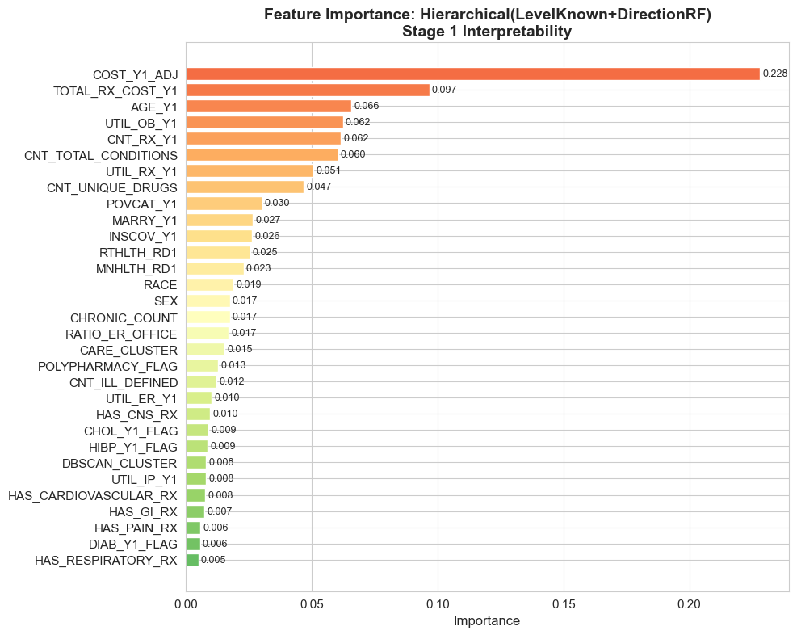

```
=== Top 10 Most Important Features ===
  COST_Y1_ADJ              : 0.2281
  TOTAL_RX_COST_Y1         : 0.0967
  AGE_Y1                   : 0.0658
  UTIL_OB_Y1               : 0.0623
  CNT_RX_Y1                : 0.0616
  CNT_TOTAL_CONDITIONS     : 0.0604
  UTIL_RX_Y1               : 0.0506
  CNT_UNIQUE_DRUGS         : 0.0468
  POVCAT_Y1                : 0.0303
  MARRY_Y1                 : 0.0266

=== Statistical Summary: Feature Importance by Group ===
```

|  | Group | N_Features | Importance Sum | Share |
| --- | --- | --- | --- | --- |
| 5 | Medication | 9 | 0.253397 | 0.253397 |
| 7 | Cost | 1 | 0.228132 | 0.228132 |
| 0 | Demographic | 6 | 0.185272 | 0.185272 |
| 3 | Utilization | 4 | 0.131186 | 0.131186 |
| 4 | Engineered | 3 | 0.089650 | 0.089650 |
| 1 | Health | 2 | 0.048408 | 0.048408 |
| 2 | Chronic | 4 | 0.040573 | 0.040573 |
| 6 | Clusters | 2 | 0.023381 | 0.023381 |

```
Top-1 feature share: 0.2281
Top-5 cumulative share: 0.5145
```

```python
# Feature importance for selected pipeline
importance = None

if selected_pipeline == 'Global':
    if hasattr(best_model, 'feature_importances_'):
        imp = best_model.feature_importances_
    elif hasattr(best_model, 'coef_'):
        imp = np.abs(best_model.coef_).mean(axis=0)
    else:
        imp = None

    if imp is not None:
        feat_imp_df = pd.DataFrame({'Feature': X_train.columns, 'Importance': imp})
        feat_imp_df = feat_imp_df.sort_values('Importance', ascending=True)
        importance = feat_imp_df['Importance'].values
    else:
        feat_imp_df = None

else:
    # Hierarchical: aggregate level-specific importances weighted by level sample size
    level_imp_rows = []

    for lvl, bundle in hier_direction_models.items():
        mdl = bundle['model']
        if mdl is None:
            continue

        if hasattr(mdl, 'feature_importances_'):
            imp = mdl.feature_importances_
        elif hasattr(mdl, 'coef_'):
            imp = np.abs(mdl.coef_).mean(axis=0)
        else:
            continue

        for feat, val in zip(X_train.columns, imp):
            level_imp_rows.append({
                'Level': LEVEL_NAMES[lvl],
                'Feature': feat,
                'Importance': float(val),
                'TrainCount': bundle['train_n']
            })

    level_imp_df = pd.DataFrame(level_imp_rows)

    if len(level_imp_df) == 0:
        feat_imp_df = None
    else:
        # Weighted average across levels
        feat_imp_df = (
            level_imp_df
            .groupby('Feature')
            .apply(lambda g: np.average(g['Importance'], weights=g['TrainCount']))
            .rename('Importance')
            .reset_index()
            .sort_values('Importance', ascending=True)
        )
        importance = feat_imp_df['Importance'].values

        print("=== Level-specific Top Features (Direction Models) ===")
        for lvl, sub in level_imp_df.groupby('Level'):
            top = sub.sort_values('Importance', ascending=False).head(5)
            print(f"\n  Level={lvl}")
            for _, r in top.iterrows():
                print(f"    {r['Feature']:25s}: {r['Importance']:.4f}")

if feat_imp_df is not None:
    fig, ax = plt.subplots(figsize=(10, 8))
    colors = plt.cm.RdYlGn_r(np.linspace(0.2, 0.8, len(feat_imp_df)))
    bars = ax.barh(feat_imp_df['Feature'], feat_imp_df['Importance'], color=colors)
    ax.set_xlabel('Importance', fontsize=12)
    ax.set_title(f'Feature Importance: {selected_model_name}\nStage 1 Interpretability', fontsize=14, fontweight='bold')

    for bar, val in zip(bars, feat_imp_df['Importance']):
        ax.text(bar.get_width() + 0.001, bar.get_y() + bar.get_height()/2,
                f'{val:.3f}', va='center', fontsize=9)

    plt.tight_layout()
    plt.savefig(REPORT_DIR / 'figures' / 'feature_importance_stage1.png', dpi=150)
    plt.show()

    top10 = feat_imp_df.tail(10).iloc[::-1].copy()
    print("\n=== Top 10 Most Important Features ===")
    for _, row in top10.iterrows():
        print(f"  {row['Feature']:25s}: {row['Importance']:.4f}")

    # Group-level contribution
    group_rows = []
    imp_map = feat_imp_df.set_index('Feature')['Importance'].to_dict()
    total_imp = feat_imp_df['Importance'].sum()

    for gname, gfeats in FEATURE_GROUPS.items():
        present = [f for f in gfeats if f in imp_map]
        if not present:
            continue
        group_imp = sum(imp_map[f] for f in present)
        group_rows.append({
            'Group': gname,
            'N_Features': len(present),
            'Importance Sum': group_imp,
            'Share': group_imp / max(total_imp, 1e-12),
        })

    group_imp_df = pd.DataFrame(group_rows).sort_values('Importance Sum', ascending=False)
    print("\n=== Statistical Summary: Feature Importance by Group ===")
    display(group_imp_df)

    top1 = feat_imp_df.iloc[-1]['Importance']
    top5 = feat_imp_df.tail(5)['Importance'].sum()
    print(f"Top-1 feature share: {top1:.4f}")
    print(f"Top-5 cumulative share: {top5:.4f}")
else:
    print("Feature importance not available for selected pipeline.")
```

### Feature Importance Interpretation

This chart should answer one report question clearly: **what is driving prediction beyond Y1 cost?**

Read it in this order:

1. Is `COST_Y1_ADJ` still dominant? It should be important, because healthcare spend is persistent.
2. Which non-cost variables still rank highly after cost is included? Those are the candidates worth discussing as additional predictors.
3. Do those non-cost predictors make clinical sense? For this project the most credible groups are:
   - utilization intensity and mix,
   - medication burden and prescription complexity,
   - chronic condition burden,
   - health-status self-report.

In report language, the key point is not that cost remains predictive. The key point is that **utilization, medication, and disease-burden variables still move the prediction after baseline cost is already known**.

## 6.1 SHAP Analysis (Advanced Interpretability)

```python
# SHAP Analysis
#
# SHAP is intentionally skipped in the default notebook run because Stage 1 already
# has several report-grade visuals and the tree explainer adds substantial runtime.
# If a deeper interpretability appendix is needed, rerun this section manually.
print("SHAP skipped in default run to keep Stage 1 reproducible and fast.")
SHAP_AVAILABLE = False
```

```
SHAP skipped in default run to keep Stage 1 reproducible and fast.
```

### SHAP Interpretation

Use SHAP to answer:

- Which features push patients toward worse transition classes within the same Year 1 cost level?
- Are those pushes clinically plausible, such as higher inpatient use, heavier medication burden, or worse self-rated health?
- Do the non-cost drivers agree with the simpler feature-importance ranking above?

If SHAP does not add a clearer story than the simpler importance ranking, it should stay as supporting material, not as a headline figure.

## 7. Generate Leakage-Safe OOF Latent Factors and Decision-Layer Fields

OOF outputs are generated with panel-aware CV and feed Stage 2.

This step now produces:

- Per-class probabilities: `PROB_*` and alias columns `P_*`
- Latent factors: `LATENT_RISK_SCORE_MANUAL`, `EXPECTED_DELTA_SCORE`, `LATENT_RISK_SCORE`
- Uncertainty: `PRED_ENTROPY`, `uncertainty_score`
- Decision outputs:
  - `pred_class_hard`
  - `pred_class_policy` (can be `-1` for REVIEW)
  - `review_flag` (`0/1`)
  - compatibility aliases: `STAGE1_PRED_CLASS`, `STAGE1_PRED_CLASS_TUNED`

```python
# Generate leakage-safe OOF probabilities, latent factors, and policy outputs
print("Generating OOF Stage 1 probabilities...")
print(f"Selected pipeline for OOF: {selected_pipeline}")

class_ids = np.array(sorted(CLASS_NAMES.keys()))
class_to_idx = {cls: i for i, cls in enumerate(class_ids)}

# CV scheme
if 'PANEL' in df.columns and df['PANEL'].nunique() >= 3:
    n_splits = min(5, df['PANEL'].nunique())
    cv = GroupKFold(n_splits=n_splits)
    split_iter = cv.split(X_raw, y, groups=df['PANEL'])
    cv_name = f'GroupKFold(n_splits={n_splits}, group=PANEL)'
else:
    n_splits = 5
    cv = StratifiedKFold(n_splits=n_splits, shuffle=True, random_state=42)
    split_iter = cv.split(X_raw, y)
    cv_name = f'StratifiedKFold(n_splits={n_splits})'

print(f"CV scheme: {cv_name}")

oof_proba = np.full((len(X_raw), len(class_ids)), np.nan, dtype=float)
oof_expected_delta = np.full(len(X_raw), np.nan, dtype=float)


def train_hier_fold_models(X_tr_proc, y_tr, level_tr):
    models = {}
    for lvl, tiers in LEVEL_TO_TIERS.items():
        mask = (level_tr == lvl)
        X_l = X_tr_proc.loc[mask]
        y_l_local = y_tr.loc[mask].map(TIER_TO_LOCAL[lvl]).astype(int)

        if len(X_l) == 0:
            models[lvl] = {'model': None, 'constant_local_class': 0, 'tiers': tiers}
            continue

        if y_l_local.nunique() <= 1:
            models[lvl] = {
                'model': None,
                'constant_local_class': int(y_l_local.iloc[0]),
                'tiers': tiers,
            }
        else:
            mdl = RandomForestClassifier(
                n_estimators=300,
                max_depth=12,
                class_weight='balanced',
                random_state=42,
                n_jobs=-1,
            )
            mdl.fit(X_l, y_l_local)
            models[lvl] = {'model': mdl, 'constant_local_class': None, 'tiers': tiers}
    return models


for fold, (tr_idx, va_idx) in enumerate(split_iter, start=1):
    X_tr_raw = X_raw.iloc[tr_idx].copy()
    X_va_raw = X_raw.iloc[va_idx].copy()
    y_tr = y.iloc[tr_idx]

    fold_prep = fit_preprocessor(X_tr_raw)
    X_tr = apply_preprocessor(X_tr_raw, fold_prep)
    X_va = apply_preprocessor(X_va_raw, fold_prep)

    if selected_pipeline == 'Global':
        fold_model = clone(best_model)
        fold_model.fit(X_tr, y_tr)

        pred = fold_model.predict_proba(X_va)
        fold_class_to_col = {cls: i for i, cls in enumerate(fold_model.classes_)}

        aligned = np.zeros((len(va_idx), len(class_ids)), dtype=float)
        for out_col, cls in enumerate(class_ids):
            if cls in fold_class_to_col:
                aligned[:, out_col] = pred[:, fold_class_to_col[cls]]

    else:
        level_tr = df.iloc[tr_idx]['Y1_LEVEL'].astype(int)
        level_va = df.iloc[va_idx]['Y1_LEVEL'].astype(int)

        hier_models_fold = train_hier_fold_models(X_tr, y_tr, level_tr)
        aligned = np.zeros((len(va_idx), len(class_ids)), dtype=float)

        for lvl, bundle in hier_models_fold.items():
            loc = np.where(level_va.values == lvl)[0]
            if len(loc) == 0:
                continue

            X_l_va = X_va.iloc[loc]
            tiers = bundle['tiers']

            if bundle['model'] is None:
                local_proba = np.zeros((len(loc), len(tiers)), dtype=float)
                local_proba[:, bundle['constant_local_class']] = 1.0
            else:
                raw = bundle['model'].predict_proba(X_l_va)
                local_proba = np.zeros((len(loc), len(tiers)), dtype=float)
                for k, cls_local in enumerate(bundle['model'].classes_):
                    local_proba[:, int(cls_local)] = raw[:, k]

            for local_i, tier in LOCAL_TO_TIER[lvl].items():
                aligned[loc, tier] = local_proba[:, local_i]

    oof_proba[va_idx] = aligned

    delta_mu = (
        df.iloc[tr_idx]
          .groupby('RISK_TIER')['DELTA_BIN']
          .mean()
          .reindex(class_ids)
          .fillna(0.0)
          .to_numpy()
    )
    oof_expected_delta[va_idx] = aligned @ delta_mu

    print(f"  Fold {fold}: train={len(tr_idx):,}, valid={len(va_idx):,}")

if np.isnan(oof_proba).any() or np.isnan(oof_expected_delta).any():
    raise ValueError("OOF outputs contain NaNs. Check fold training loop.")

# Normalize rows defensively
row_sum = oof_proba.sum(axis=1, keepdims=True)
oof_proba = np.divide(oof_proba, np.clip(row_sum, 1e-12, None))

# Save per-class OOF probabilities under both prefixes (for compatibility)
prob_cols = []
p_alias_cols = []
for col_idx, cls in enumerate(class_ids):
    name = CLASS_NAMES[cls].upper()
    prob_col = f'PROB_{name}'
    p_col = f'P_{name}'
    df[prob_col] = oof_proba[:, col_idx]
    df[p_col] = oof_proba[:, col_idx]
    prob_cols.append(prob_col)
    p_alias_cols.append(p_col)

# Latent scores
weight_map = {0: 0, 1: 0, 2: 1, 3: 3, 4: 0, 5: 1, 6: 2, 7: 0, 8: 2, 9: 3}
weights = np.array([weight_map[c] for c in class_ids], dtype=float)
df['LATENT_RISK_SCORE_MANUAL'] = oof_proba @ weights
df['EXPECTED_DELTA_SCORE'] = oof_expected_delta
df['LATENT_RISK_SCORE'] = df['EXPECTED_DELTA_SCORE']

# Uncertainty fields
entropy = -np.sum(oof_proba * np.log(np.clip(oof_proba, 1e-12, None)), axis=1)
df['PRED_ENTROPY'] = entropy
df['uncertainty_score'] = entropy / np.log(len(class_ids))

# Hard prediction
pred_hard = class_ids[oof_proba.argmax(axis=1)]

# Apply selected policy template from Section 5.1A (if available)
if 'SELECTED_POLICY_FOR_OOF' in globals():
    policy_cfg = SELECTED_POLICY_FOR_OOF
else:
    policy_cfg = {
        'source_experiment': 'fallback_default',
        'thresholds': {3: 0.30, 9: 0.30},
        'tau_maxprob': 0.26,
        'tau_margin': 0.05,
    }

policy_out = apply_decision_policy(
    oof_proba,
    thresholds=policy_cfg['thresholds'],
    tau_maxprob=policy_cfg['tau_maxprob'],
    tau_margin=policy_cfg['tau_margin'],
)

pred_policy = policy_out['policy_pred']
pred_eval = policy_out['eval_pred']
review_flag = policy_out['review_flag']

# Public API fields requested
df['pred_class_hard'] = pred_hard.astype(int)
df['pred_class_policy'] = pred_policy.astype(int)
df['review_flag'] = review_flag.astype(int)

# Backward-compatibility aliases used by older downstream cells
df['STAGE1_PRED_CLASS'] = df['pred_class_hard']
df['STAGE1_PRED_CLASS_TUNED'] = pred_eval.astype(int)

print("\n=== OOF Latent Features Generated ===")
print(f"CV used: {cv_name}")
print(f"Pipeline used: {selected_pipeline}")
print(f"OOF policy source: {policy_cfg['source_experiment']}")

print("\nLATENT_RISK_SCORE (expected delta):")
print(f"  mean={df['LATENT_RISK_SCORE'].mean():.3f}, std={df['LATENT_RISK_SCORE'].std():.3f}")
print(f"  range: [{df['LATENT_RISK_SCORE'].min():.3f}, {df['LATENT_RISK_SCORE'].max():.3f}]")

base_agreement = (df['pred_class_hard'] == df['RISK_TIER']).mean()
policy_coverage = 1.0 - df['review_flag'].mean()
policy_eval_f1 = f1_score(df['RISK_TIER'], df['STAGE1_PRED_CLASS_TUNED'], average='macro')

print(f"\nOOF hard agreement: {base_agreement:.3f}")
print(f"OOF policy coverage (non-REVIEW): {policy_coverage:.3f}")
print(f"OOF policy macro-F1 (REVIEW->hard fallback for eval): {policy_eval_f1:.3f}")
print("\nPolicy parameters:")
print(policy_cfg)
```

```
Generating OOF Stage 1 probabilities...
Selected pipeline for OOF: Hierarchical
CV scheme: GroupKFold(n_splits=5, group=PANEL)
```

```
  Fold 1: train=49,636, valid=10,966
```

```
  Fold 2: train=49,938, valid=10,664
```

```
  Fold 3: train=50,405, valid=10,197
```

```
  Fold 4: train=50,430, valid=10,172
```

```
  Fold 5: train=41,999, valid=18,603

=== OOF Latent Features Generated ===
CV used: GroupKFold(n_splits=5, group=PANEL)
Pipeline used: Hierarchical
OOF policy source: Baseline_Selected_HardOnly

LATENT_RISK_SCORE (expected delta):
  mean=0.107, std=0.650
  range: [-1.696, 1.541]

OOF hard agreement: 0.505
OOF policy coverage (non-REVIEW): 1.000
OOF policy macro-F1 (REVIEW->hard fallback for eval): 0.460

Policy parameters:
{'source_experiment': 'Baseline_Selected_HardOnly', 'thresholds': {}, 'tau_maxprob': 0.0, 'tau_margin': 0.0}
```

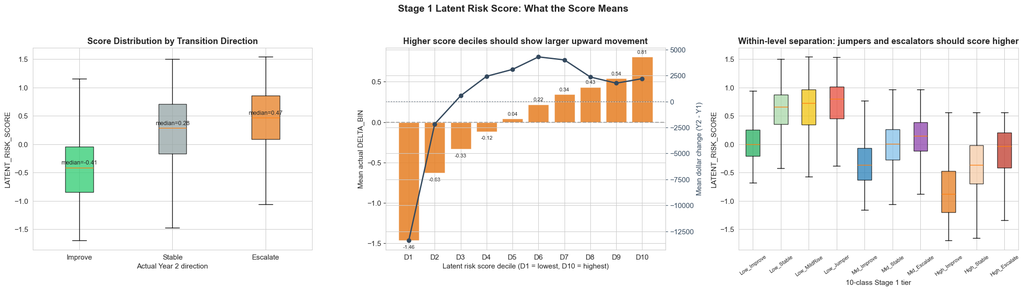

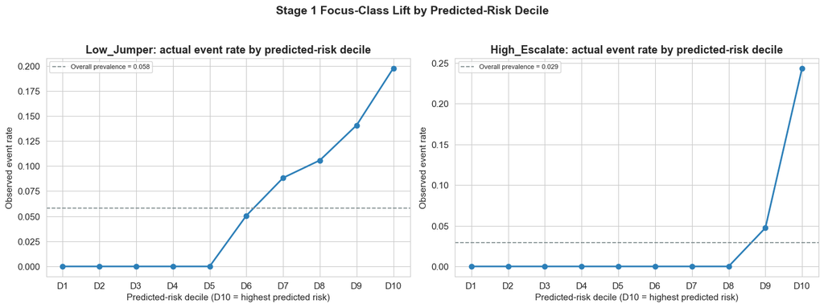

```
=== Stage 1 Latent Validation Summary ===
```

|  | _score_decile | mean_delta | mean_cost_y1 | mean_cost_y2 | n | mean_dollar_change |
| --- | --- | --- | --- | --- | --- | --- |
| 0 | D1 | -1.463455 | 22930.432292 | 9555.266443 | 6061 | -13375.165849 |
| 1 | D2 | -0.629043 | 14484.992134 | 12323.943713 | 6060 | -2161.048421 |
| 2 | D3 | -0.333663 | 10788.293536 | 11345.091649 | 6060 | 556.798112 |
| 3 | D4 | -0.116337 | 6049.234550 | 8480.783525 | 6060 | 2431.548975 |
| 4 | D5 | 0.044224 | 3175.478429 | 6270.057305 | 6060 | 3094.578876 |
| 5 | D6 | 0.220792 | 3592.292335 | 7892.101210 | 6060 | 4299.808875 |
| 6 | D7 | 0.344389 | 2393.660335 | 6403.646234 | 6060 | 4009.985899 |
| 7 | D8 | 0.433993 | 860.454736 | 3224.265594 | 6060 | 2363.810858 |
| 8 | D9 | 0.541419 | 294.304257 | 2063.070838 | 6060 | 1768.766581 |
| 9 | D10 | 0.807293 | 171.661901 | 2375.931572 | 6061 | 2204.269672 |

```
Spearman(decile, mean DELTA_BIN): 1.000
Spearman(decile, mean dollar change): 0.442

Focus-class lift summary:
```

|  | Class | BaseRate | TopDecileRate | TopDecileLift |
| --- | --- | --- | --- | --- |
| 0 | Low_Jumper | 0.058315 | 0.197657 | 3.389479 |
| 1 | High_Escalate | 0.029124 | 0.243854 | 8.372832 |

```
Recall Low_Jumper      : hard=0.140, policy_eval=0.140
Recall High_Escalate   : hard=0.493, policy_eval=0.493
Review rate: 0.000
Uncertainty score (mean): 0.458
```

```python
# Latent score validation: readable plots for routing and healthcare interpretation
from scipy.stats import spearmanr

fig, axes = plt.subplots(1, 3, figsize=(22, 6))
fig.suptitle('Stage 1 Latent Risk Score: What the Score Means', fontsize=15, fontweight='bold', y=1.03)

direction_palette = {'Improve': '#2ecc71', 'Stable': '#95a5a6', 'Escalate': '#e67e22'}
trans_colors = {
    0: '#27ae60', 1: '#a8d8a8', 2: '#f1c40f', 3: '#e74c3c',
    4: '#2980b9', 5: '#85c1e9', 6: '#8e44ad',
    7: '#e67e22', 8: '#f5cba7', 9: '#c0392b',
}

plot_df = df[['RISK_TIER', 'LATENT_RISK_SCORE', 'DELTA_BIN', 'COST_Y1_ADJ', 'COST_Y2_ADJ']].copy()
plot_df['Direction3'] = plot_df['RISK_TIER'].map(DIRECTION3_MAP)

# Panel 1: score by direction (readable summary of whether score tracks worsening)
ax1 = axes[0]
dir_order = ['Improve', 'Stable', 'Escalate']
dir_data = [plot_df.loc[plot_df['Direction3'] == d, 'LATENT_RISK_SCORE'] for d in dir_order]
bp1 = ax1.boxplot(dir_data, labels=dir_order, patch_artist=True, showfliers=False)
for patch, d in zip(bp1['boxes'], dir_order):
    patch.set_facecolor(direction_palette[d])
    patch.set_alpha(0.75)
ax1.set_title('Score Distribution by Transition Direction', fontweight='bold')
ax1.set_xlabel('Actual Year 2 direction')
ax1.set_ylabel('LATENT_RISK_SCORE')
medians = plot_df.groupby('Direction3')['LATENT_RISK_SCORE'].median().reindex(dir_order)
for x, val in enumerate(medians, start=1):
    ax1.text(x, val + 0.06, f'median={val:.2f}', ha='center', fontsize=9)

# Panel 2: decile monotonicity with both delta-bin movement and dollar change
ax2 = axes[1]
plot_df['_score_decile'] = pd.qcut(
    plot_df['LATENT_RISK_SCORE'].rank(method='first'),
    10,
    labels=[f'D{i}' for i in range(1, 11)]
)
decile_stats = plot_df.groupby('_score_decile').agg(
    mean_delta=('DELTA_BIN', 'mean'),
    mean_cost_y1=('COST_Y1_ADJ', 'mean'),
    mean_cost_y2=('COST_Y2_ADJ', 'mean'),
    n=('DELTA_BIN', 'size')
).reset_index()
decile_stats['mean_dollar_change'] = decile_stats['mean_cost_y2'] - decile_stats['mean_cost_y1']

ax2.bar(decile_stats['_score_decile'], decile_stats['mean_delta'], color='#e67e22', alpha=0.85)
ax2.axhline(0, color='gray', ls='--', alpha=0.6)
for x, v in enumerate(decile_stats['mean_delta']):
    ax2.text(x, v + (0.04 if v >= 0 else -0.10), f'{v:.2f}', ha='center', fontsize=8)
ax2.set_xlabel('Latent risk score decile (D1 = lowest, D10 = highest)')
ax2.set_ylabel('Mean actual DELTA_BIN')
ax2.set_title('Higher score deciles should show larger upward movement', fontweight='bold')

ax2b = ax2.twinx()
ax2b.plot(decile_stats['_score_decile'], decile_stats['mean_dollar_change'], color='#34495e', marker='o', lw=2)
ax2b.axhline(0, color='#34495e', ls=':', alpha=0.5)
ax2b.set_ylabel('Mean dollar change (Y2 - Y1)', color='#34495e')
ax2b.tick_params(axis='y', colors='#34495e')

# Panel 3: score separation by 10-class tier
ax3 = axes[2]
ordered_tiers = sorted(plot_df['RISK_TIER'].unique())
score_data = [plot_df.loc[plot_df['RISK_TIER'] == t, 'LATENT_RISK_SCORE'] for t in ordered_tiers]
bp3 = ax3.boxplot(
    score_data,
    labels=[CLASS_NAMES[t] for t in ordered_tiers],
    patch_artist=True,
    showfliers=False,
)
for patch, t in zip(bp3['boxes'], ordered_tiers):
    patch.set_facecolor(trans_colors.get(t, 'gray'))
    patch.set_alpha(0.75)
ax3.set_xlabel('10-class Stage 1 tier')
ax3.set_ylabel('LATENT_RISK_SCORE')
ax3.set_title('Within-level separation: jumpers and escalators should score higher', fontweight='bold')
ax3.tick_params(axis='x', rotation=35, labelsize=8)

plt.tight_layout()
plt.savefig(REPORT_DIR / 'figures' / 'latent_risk_score_analysis.png', dpi=150, bbox_inches='tight')
plt.show()

# Focus-class lift chart: easier to interpret than reliability curves
fig, axes = plt.subplots(1, 2, figsize=(14, 5))
fig.suptitle('Stage 1 Focus-Class Lift by Predicted-Risk Decile', fontsize=14, fontweight='bold', y=1.03)
lift_summary_rows = []

for ax, cls in zip(axes, [3, 9]):
    label = CLASS_NAMES[cls]
    prob_col = f'PROB_{label.upper()}'
    tmp = df[[prob_col, 'RISK_TIER']].copy()
    tmp['is_event'] = (tmp['RISK_TIER'] == cls).astype(int)
    tmp['prob_decile'] = pd.qcut(
        tmp[prob_col].rank(method='first'),
        10,
        labels=[f'D{i}' for i in range(1, 11)]
    )
    dec = tmp.groupby('prob_decile').agg(
        observed_rate=('is_event', 'mean'),
        mean_pred=('is_event', 'size')
    ).reset_index()
    prevalence = tmp['is_event'].mean()
    top_decile_rate = dec.loc[dec['prob_decile'] == 'D10', 'observed_rate'].iloc[0]
    lift = top_decile_rate / max(prevalence, 1e-12)
    lift_summary_rows.append({
        'Class': label,
        'BaseRate': prevalence,
        'TopDecileRate': top_decile_rate,
        'TopDecileLift': lift,
    })

    ax.plot(dec['prob_decile'], dec['observed_rate'], marker='o', lw=2, color='#2c7fb8')
    ax.axhline(prevalence, color='#7f8c8d', ls='--', lw=1.2, label=f'Overall prevalence = {prevalence:.3f}')
    ax.set_title(f'{label}: actual event rate by predicted-risk decile', fontweight='bold')
    ax.set_xlabel('Predicted-risk decile (D10 = highest predicted risk)')
    ax.set_ylabel('Observed event rate')
    ax.legend(fontsize=8)

plt.tight_layout()
plt.savefig(REPORT_DIR / 'figures' / 'stage1_reliability_focus_classes.png', dpi=150, bbox_inches='tight')
plt.show()

rho_delta = spearmanr(decile_stats.index + 1, decile_stats['mean_delta']).statistic
rho_change = spearmanr(decile_stats.index + 1, decile_stats['mean_dollar_change']).statistic
lift_summary_df = pd.DataFrame(lift_summary_rows)

print("\n=== Stage 1 Latent Validation Summary ===")
display(decile_stats)
print(f"Spearman(decile, mean DELTA_BIN): {rho_delta:.3f}")
print(f"Spearman(decile, mean dollar change): {rho_change:.3f}")
print("\nFocus-class lift summary:")
display(lift_summary_df)

for cls in [3, 9]:
    y_true = (df['RISK_TIER'] == cls)
    rec_hard = ((df['pred_class_hard'] == cls) & y_true).sum() / max(y_true.sum(), 1)
    rec_eval = ((df['STAGE1_PRED_CLASS_TUNED'] == cls) & y_true).sum() / max(y_true.sum(), 1)
    print(f"Recall {CLASS_NAMES[cls]:16s}: hard={rec_hard:.3f}, policy_eval={rec_eval:.3f}")

print(f"Review rate: {df['review_flag'].mean():.3f}")
print(f"Uncertainty score (mean): {df['uncertainty_score'].mean():.3f}")
```

### Latent Score Interpretation

These plots should answer three very specific questions.

**1. Does the latent score represent worsening risk, not just high cost?**

- In the first panel, patients who truly escalate should sit higher on `LATENT_RISK_SCORE` than stable or improving patients.
- In the second panel, the mean observed `DELTA_BIN` should rise as score decile increases. That is the direct test that the score is ranking transition severity, not just reproducing Year 1 spending.

**2. Does the score track spending change in dollars?**

- The dark line in the second panel shows mean **dollar change (`Y2 - Y1`)** by score decile.
- This is more faithful to the modeling goal than plotting raw Year 2 cost, because the latent score is supposed to rank **worsening**, not merely expensive patients.

**3. Are the focus-class probabilities usable as screening signals?**

- The lift charts replace the earlier reliability curves because they are easier to explain.
- Each point shows the **actual event rate** inside one predicted-risk decile.
- If the line rises sharply toward `D10`, then the model is concentrating true `Low_Jumper` or `High_Escalate` cases into the highest-risk patients.
- That does **not** mean the probability is perfectly calibrated; it means the score is useful for ranking patients for manual review or downstream soft routing.

**Healthcare reading**

- `LATENT_RISK_SCORE` is not a final clinical decision rule.
- Its main value is as a leakage-safe Stage 2 routing signal and as an interpretable “expected worsening” axis that uses more than prior cost alone.

```python
# Save updated dataset with latent features for Stage 2
output_path = OUTPUT_STAGE1_PATH
output_path.parent.mkdir(parents=True, exist_ok=True)
df.to_parquet(output_path, index=False)

print("=== Stage 1 Output Saved ===")
print(f"Path: {output_path}")
print(f"Rows: {len(df):,}")
print(f"Run version: {STAGE1_NOTEBOOK_VERSION}")

new_cols = [
    c for c in df.columns
    if c.startswith('PROB_')
    or c.startswith('P_')
    or c in [
        'LATENT_RISK_SCORE', 'LATENT_RISK_SCORE_MANUAL', 'EXPECTED_DELTA_SCORE',
        'PRED_ENTROPY', 'uncertainty_score',
        'pred_class_hard', 'pred_class_policy', 'review_flag',
        'STAGE1_PRED_CLASS', 'STAGE1_PRED_CLASS_TUNED',
    ]
]
print(f"New Columns ({len(new_cols)}): {new_cols}")

# Save benchmark results with version marker
results_to_save = results_df.copy()
results_to_save['RunVersion'] = STAGE1_NOTEBOOK_VERSION
results_to_save.to_csv(REPORT_DIR / 'tables' / 'stage1_model_benchmark.csv', index=False)
print(f"\nBenchmark saved to: {REPORT_DIR / 'tables' / 'stage1_model_benchmark.csv'}")

# Save baseline lock table for reproducibility control
baseline_locked = results_to_save.copy()
baseline_locked['SelectedPipeline'] = selected_pipeline
baseline_locked['SelectedModelName'] = selected_model_name
baseline_locked['MajorityBaselineAccuracy'] = majority_acc
baseline_locked.to_csv(REPORT_DIR / 'tables' / 'baseline_locked_metrics.csv', index=False)
print(f"Baseline lock saved to: {REPORT_DIR / 'tables' / 'baseline_locked_metrics.csv'}")

# Save feature importance
if importance is not None:
    feat_imp_df.sort_values('Importance', ascending=False).to_csv(
        REPORT_DIR / 'tables' / 'stage1_feature_importance.csv', index=False
    )
    print(f"Feature importance saved to: {REPORT_DIR / 'tables' / 'stage1_feature_importance.csv'}")

# Save run metadata for quick freshness checks
meta = {
    'version': STAGE1_NOTEBOOK_VERSION,
    'saved_at_utc': datetime.utcnow().isoformat(),
    'selected_pipeline': selected_pipeline,
    'selected_model_name': selected_model_name,
    'rows': int(len(df)),
    'n_columns': int(len(df.columns)),
    'cv_scheme_oof': cv_name if 'cv_name' in globals() else 'unknown',
    'has_policy_template': bool('SELECTED_POLICY_FOR_OOF' in globals()),
    'policy_template': SELECTED_POLICY_FOR_OOF if 'SELECTED_POLICY_FOR_OOF' in globals() else None,
}
meta_path = REPORT_DIR / 'tables' / 'stage1_run_metadata.json'
meta_path.write_text(json.dumps(meta, indent=2))
print(f"Run metadata saved to: {meta_path}")
```

```
=== Stage 1 Output Saved ===
Path: /Users/duanduan/Documents/NEU/ALY6980/healthcare_repo/data/processed_v2/model_ready_stage1.parquet
Rows: 60,602
Run version: stage1_decisionlayer_v2026_03_17_r1
New Columns (30): ['PROB_LOW_IMPROVE', 'P_LOW_IMPROVE', 'PROB_LOW_STABLE', 'P_LOW_STABLE', 'PROB_LOW_MILDRISE', 'P_LOW_MILDRISE', 'PROB_LOW_JUMPER', 'P_LOW_JUMPER', 'PROB_MID_IMPROVE', 'P_MID_IMPROVE', 'PROB_MID_STABLE', 'P_MID_STABLE', 'PROB_MID_ESCALATE', 'P_MID_ESCALATE', 'PROB_HIGH_IMPROVE', 'P_…

Benchmark saved to: /Users/duanduan/Documents/NEU/ALY6980/healthcare_repo/reports/tables/stage1_model_benchmark.csv
Baseline lock saved to: /Users/duanduan/Documents/NEU/ALY6980/healthcare_repo/reports/tables/baseline_locked_metrics.csv
Feature importance saved to: /Users/duanduan/Documents/NEU/ALY6980/healthcare_repo/reports/tables/stage1_feature_importance.csv
Run metadata saved to: /Users/duanduan/Documents/NEU/ALY6980/healthcare_repo/reports/tables/stage1_run_metadata.json
```

## Summary

**Stage 1 now serves two distinct purposes**

**What we intentionally removed from the narrative**

- We no longer present a long list of near-duplicate policy experiments.
- We do not treat extremely low rare-class recall as an operational recommendation.
- We do not rely on threshold tuning as evidence of new signal; the stronger evidence is the gap between the cost-only model and the full model, plus the non-cost features that remain important after baseline cost is included.

**Stage 1 outputs passed to Stage 2**

- `PROB_*` / `P_*`: leakage-safe out-of-fold class probabilities
- `LATENT_RISK_SCORE`, `EXPECTED_DELTA_SCORE`
- `pred_class_hard`
- `pred_class_policy`, `review_flag` for sensitivity analysis only
- `uncertainty_score`

**Main storytelling takeaway**

Stage 1 confirms that Year 1 cost is powerful, but it is not the whole story. Utilization mix, medication burden, chronic burden, and engineered transition signals contribute additional information that supports Stage 2 expenditure prediction.

# 5.2 Stage 1.5 and Stage 2 Modeling

Source notebook: `5.2_stage1_5_and_stage2_modeling.ipynb`

# 5.2 Stage 1.5 & Stage 2: Feature Enrichment -> Cost Prediction

**Pipeline:** Stage 0 (Feature Engineering) -> Stage 1 (2D Classification, 10-class) -> **Stage 1.5 (Feature Enrichment)** -> **Stage 2 (Cost Prediction)**

**Stage 1.5 rationale:** Stage 1 classifies patients into 10 transition-aware classes. Within each class, costs still vary. Stage 1.5 enriches with:

- **ENGAGEMENT_SCORE**: Utilization pattern (proactive vs crisis-oriented care)
- **ESCALATION_MAGNITUDE**: Predicted cost-bin movement (`DELTA_BIN` regression)
- **Raw Rx timeline features**: `RX_DENSITY`, `RX_GAP_RATIO`, `RX_TRAILING_GAP`, `RX_REGULARITY`

**Stage 2 approach:**

- Train class-specific regressors using true training labels.
- Route inference-time predictions by **Stage 1 predicted class** (`STAGE1_PRED_CLASS`), not true class labels.
- Use a global model as fallback for classes without a stable class-specific model.

## Data Leakage Prevention

- All features use **Year 1 data only**
- Stage 1 tier probabilities generated via **out-of-fold** prediction
- Stage 1.5 latent factors use **cross-validated** predictions
- Train/val/test split is **stratified by panel** (7:2:1)

```python
# SETUP & IMPORTS
import pandas as pd
import numpy as np
import matplotlib.pyplot as plt
import seaborn as sns
from pathlib import Path
import warnings
import json

# Sklearn imports
from sklearn.model_selection import (
    train_test_split, cross_val_predict, StratifiedKFold, GridSearchCV
)
from sklearn.preprocessing import StandardScaler
from sklearn.linear_model import (
    LogisticRegression, TweedieRegressor, Ridge
)
from sklearn.ensemble import (
    RandomForestClassifier, RandomForestRegressor,
    GradientBoostingClassifier, GradientBoostingRegressor,
    StackingClassifier, StackingRegressor
)
from sklearn.metrics import (
    classification_report, confusion_matrix, roc_auc_score,
    f1_score, accuracy_score, mean_squared_error, mean_absolute_error,
    r2_score
)

# XGBoost
from xgboost import XGBClassifier, XGBRegressor

warnings.filterwarnings('ignore')
sns.set_style('whitegrid')
plt.rcParams['figure.dpi'] = 120
plt.rcParams['font.size'] = 11
np.random.seed(42)

STAGE2_NOTEBOOK_VERSION = 'stage2_softroute_v2026_03_17_r1'

# Paths (robust to repo root or notebooks cwd)
CWD = Path.cwd()
if (CWD / 'data' / 'processed_v2').exists():
    REPO_ROOT = CWD
elif (CWD.parent / 'data' / 'processed_v2').exists():
    REPO_ROOT = CWD.parent
else:
    REPO_ROOT = CWD

DATA_PATH = REPO_ROOT / 'data' / 'processed_v2' / 'model_ready_stage1.parquet'
DATA_PATH_BACKUP = REPO_ROOT / 'data' / 'processed_v2' / 'model_ready_v2.parquet'
REPORT_DIR = REPO_ROOT / 'reports'
(REPORT_DIR / 'figures').mkdir(parents=True, exist_ok=True)
(REPORT_DIR / 'tables').mkdir(parents=True, exist_ok=True)

print("Setup complete.")
print(f"Stage2 notebook version: {STAGE2_NOTEBOOK_VERSION}")
print(f"Repo root: {REPO_ROOT}")
print(f"Primary input: {DATA_PATH}")
```

```
Setup complete.
Stage2 notebook version: stage2_softroute_v2026_03_17_r1
Repo root: /Users/duanduan/Documents/NEU/ALY6980/healthcare_repo
Primary input: /Users/duanduan/Documents/NEU/ALY6980/healthcare_repo/data/processed_v2/model_ready_stage1.parquet
```

## 1. Load Data from Stage 1

```python
# Try to load Stage 1 output; fallback to base processed data
if DATA_PATH.exists():
    df = pd.read_parquet(DATA_PATH)
    print(f"Loaded Stage 1 output: {DATA_PATH}")
    has_stage1_output = 'LATENT_RISK_SCORE' in df.columns
else:
    df = pd.read_parquet(DATA_PATH_BACKUP)
    print(f"Loaded base processed data: {DATA_PATH_BACKUP}")
    has_stage1_output = False

CLASS_NAMES = {
    0: 'Low_Improve',   1: 'Low_Stable',    2: 'Low_MildRise',  3: 'Low_Jumper',
    4: 'Mid_Improve',   5: 'Mid_Stable',    6: 'Mid_Escalate',
    7: 'High_Improve',  8: 'High_Stable',   9: 'High_Escalate',
}

print(f"\nDataset: {len(df):,} rows, {len(df.columns)} columns")
print(f"Stage 1 Latent Factors Available: {has_stage1_output}")

print(f"\nColumns: {list(df.columns)}")
```

```
Dataset: 60,602 rows, 73 columns
Stage 1 Latent Factors Available: True

Columns: ['DUPERSID', 'PANEL', 'START_YEAR', 'AGE_Y1', 'SEX', 'RACE', 'MARRY_Y1', 'POVCAT_Y1', 'INSCOV_Y1', 'MNHLTH_RD1', 'RTHLTH_RD1', 'DIAB_Y1_FLAG', 'HIBP_Y1_FLAG', 'CHOL_Y1_FLAG', 'CHRONIC_COUNT', 'UTIL_ER_Y1', 'UTIL_IP_Y1', 'UTIL_OB_Y1', 'UTIL_RX_Y1', 'CNT_TOTAL_CONDITIONS', 'CNT_ILL_DEFINED', …
```

# STAGE 1.5: Feature Enrichment

Stage 1.5 keeps only enrichment variables that add signal beyond original Year 1 features and Stage 1 latent outputs.

**Kept modules:**

- 1.5B: `ENGAGEMENT_SCORE` (direct utilization-pattern construct)
- 1.5C: `ESCALATION_MAGNITUDE` (OOF regression on `DELTA_BIN`)
- 1.5E: Raw Rx timeline variables (`RX_DENSITY`, `RX_GAP_RATIO`, `RX_TRAILING_GAP`, `RX_REGULARITY`)

**Removed from prior versions:**

- `PROB_CRISIS_MODE`, `ESCALATION_SCORE`, `HAZARD_DISCONTINUE` (high redundancy with existing features/Stage 1 outputs)

| Factor | What it captures | Method | Input variables |
| --- | --- | --- | --- |
| `ENGAGEMENT_SCORE` | Proactive vs crisis care pattern | Direct formula | `UTIL_ER_Y1`, `UTIL_OB_Y1`, `UTIL_IP_Y1` |
| `ESCALATION_MAGNITUDE` | Expected bin movement | 5-fold OOF regression | Clinical/utilization + `COST_Y1_ADJ` + engagement |
| `RX_*` timeline | Fill consistency and gaps | Direct extraction | Prescribed medicines timeline |

## Stage 1.5B: Healthcare Engagement Score

**What:** Composite score measuring whether a patient's Y1 care pattern is proactive (regular office visits) or reactive/crisis-oriented (ER/IP dependent).

**Formula:** `ENGAGEMENT_SCORE = Norm(Office) - Norm(ER_ratio) - 0.5 * Norm(IP)`, range approximately `[-1, 1]`.

Higher score = more office-centered care pattern; lower score = more ER/IP-centered pattern.

```python
# STAGE 1.5B: Healthcare Engagement Score (Direct Calculation)
#
# Methodology: No predict_proba needed - directly calculate from Y1 data
#
# ENGAGEMENT_SCORE = Composite metric, range [-1, 1]:
#   +1 = Very proactive (high office visits, low ER)
#   -1 = Crisis-oriented (high ER/IP, low office)
#

print("STAGE 1.5B: Healthcare Engagement Score (Direct Calculation)")

# Calculate Engagement Score directly from Y1 utilization data
if all(c in df.columns for c in ['UTIL_ER_Y1', 'UTIL_OB_Y1', 'UTIL_IP_Y1']):

    # --- Normalization function ---
    def normalize_0_1(series):
        """Min-max normalize to [0, 1]"""
        min_val, max_val = series.min(), series.max()
        if max_val == min_val:
            return series * 0
        return (series - min_val) / (max_val - min_val)

    # --- Calculate components ---

    # 1. ER dependency: ER / (ER + Office + 1), high=bad
    total_visits = df['UTIL_ER_Y1'] + df['UTIL_OB_Y1'] + 1
    er_dependency = df['UTIL_ER_Y1'] / total_visits
    er_score = normalize_0_1(er_dependency)

    # 2. IP intensity: hospitalization=high risk, high=bad
    ip_score = normalize_0_1(df['UTIL_IP_Y1'].clip(upper=5))  # cap at 5

    # 3. Office engagement: moderate=good, but too many may indicate issues
    ob_optimal = df['UTIL_OB_Y1'].clip(upper=df['UTIL_OB_Y1'].quantile(0.9))
    ob_score = normalize_0_1(ob_optimal)

    # --- Calculate Engagement Score ---
    # Formula: Office(+) - ER_dependency(-) - IP_intensity(-)
    raw_score = ob_score - er_score - ip_score * 0.5

    # Normalize to [-1, 1]
    df['ENGAGEMENT_SCORE'] = raw_score / max(raw_score.abs().max(), 0.001)

    # --- Classification (for visualization only) ---
    def classify_engagement(score):
        if score > 0.3:
            return 'Proactive'
        elif score < -0.3:
            return 'Crisis-Mode'
        else:
            return 'Reactive'

    df['ENGAGEMENT_TYPE'] = df['ENGAGEMENT_SCORE'].apply(classify_engagement)

    # --- Output ---
    print(f"\n=== Engagement Score (Direct Calculation) ===")
    print(f"Formula: Score = Normalized(Office) - Normalized(ER_ratio) - 0.5×Normalized(IP)")
    print(f"\nStatistics:")
    print(f"  Mean:   {df['ENGAGEMENT_SCORE'].mean():.3f}")
    print(f"  Std:    {df['ENGAGEMENT_SCORE'].std():.3f}")
    print(f"  Range:  [{df['ENGAGEMENT_SCORE'].min():.3f}, {df['ENGAGEMENT_SCORE'].max():.3f}]")

    print(f"\nEngagement Type Distribution:")
    for t in ['Proactive', 'Reactive', 'Crisis-Mode']:
        n = (df['ENGAGEMENT_TYPE'] == t).sum()
        print(f"  {t}: {n:,} ({n/len(df)*100:.1f}%)")

else:
    print("⚠ Utilization columns not available. Setting ENGAGEMENT_SCORE = 0")
    df['ENGAGEMENT_SCORE'] = 0.0
    df['ENGAGEMENT_TYPE'] = 'Unknown'
```

```
STAGE 1.5B: Healthcare Engagement Score (Direct Calculation)
```

```
=== Engagement Score (Direct Calculation) ===
Formula: Score = Normalized(Office) - Normalized(ER_ratio) - 0.5×Normalized(IP)

Statistics:
  Mean:   0.151
  Std:    0.236
  Range:  [-1.000, 0.667]

Engagement Type Distribution:
  Proactive: 12,960 (21.4%)
  Reactive: 45,857 (75.7%)
  Crisis-Mode: 1,785 (2.9%)
```

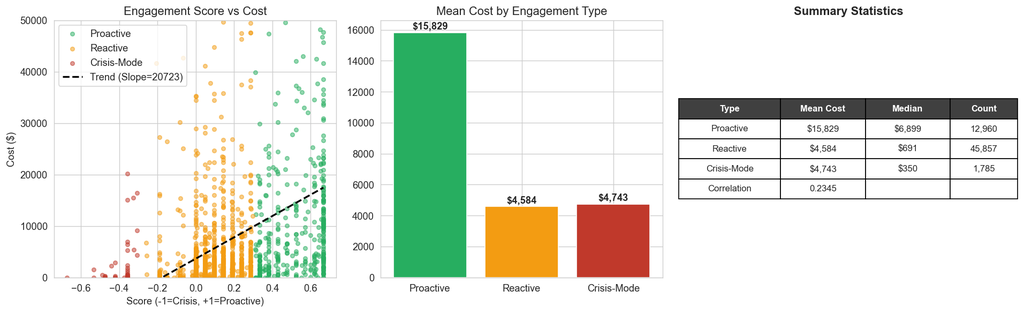

```python
# VISUALIZATION: Stage 1.5B - Healthcare Engagement Score

if 'ENGAGEMENT_SCORE' in df.columns:

    fig, axes = plt.subplots(1, 3, figsize=(16, 5))

    # --- Panel 1: Scatter Plot ---
    ax1 = axes[0]
    sample = df.sample(min(2000, len(df)), random_state=42)

    # Color mapping
    colors = {'Proactive': '#27ae60', 'Reactive': '#f39c12', 'Crisis-Mode': '#c0392b'}
    for label, color in colors.items():
        subset = sample[sample['ENGAGEMENT_TYPE'] == label]
        ax1.scatter(subset['ENGAGEMENT_SCORE'], subset['COST_Y2_ADJ'],
                   c=color, alpha=0.5, s=20, label=label)

    # Trend line
    z = np.polyfit(sample['ENGAGEMENT_SCORE'], sample['COST_Y2_ADJ'], 1)
    p = np.poly1d(z)
    x_range = np.linspace(sample['ENGAGEMENT_SCORE'].min(), sample['ENGAGEMENT_SCORE'].max(), 100)
    ax1.plot(x_range, p(x_range), 'k--', linewidth=2, label=f'Trend (Slope={z[0]:.0f})')

    ax1.set_title('Engagement Score vs Cost')
    ax1.set_xlabel('Score (-1=Crisis, +1=Proactive)')
    ax1.set_ylabel('Cost ($)')
    ax1.legend()
    ax1.set_ylim(0, 50000)

    # --- Panel 2: Mean Cost by Type ---
    ax2 = axes[1]
    stats = df.groupby('ENGAGEMENT_TYPE')['COST_Y2_ADJ'].agg(['mean', 'median', 'count']).reset_index()
    # Reorder
    order = ['Proactive', 'Reactive', 'Crisis-Mode']
    stats['ENGAGEMENT_TYPE'] = pd.Categorical(stats['ENGAGEMENT_TYPE'], categories=order, ordered=True)
    stats = stats.sort_values('ENGAGEMENT_TYPE')

    bars = ax2.bar(stats['ENGAGEMENT_TYPE'], stats['mean'], color=[colors[x] for x in stats['ENGAGEMENT_TYPE']])

    for bar, val in zip(bars, stats['mean']):
        ax2.text(bar.get_x() + bar.get_width()/2, bar.get_height() + 200,
                 f'${val:,.0f}', ha='center', fontweight='bold')

    ax2.set_title('Mean Cost by Engagement Type')

    # --- Panel 3: Real Table ---
    ax3 = axes[2]
    ax3.axis('off')

    corr = df['ENGAGEMENT_SCORE'].corr(df['COST_Y2_ADJ'])

    table_data = [['Type', 'Mean Cost', 'Median', 'Count']]
    for _, row in stats.iterrows():
        table_data.append([
            row['ENGAGEMENT_TYPE'],
            f"${row['mean']:,.0f}",
            f"${row['median']:,.0f}",
            f"{row['count']:,}"
        ])

    table_data.append(['Correlation', f'{corr:.4f}', '', ''])

    table = ax3.table(cellText=table_data, loc='center', cellLoc='center', colWidths=[0.3, 0.25, 0.25, 0.2])
    table.scale(1.2, 1.8)
    table.auto_set_font_size(False)
    table.set_fontsize(10)

    for i in range(4):
        table[(0, i)].set_facecolor('#404040')
        table[(0, i)].set_text_props(color='white', fontweight='bold')

    ax3.set_title('Summary Statistics', fontweight='bold')

    plt.tight_layout()
    plt.show()
```

### Interpretation: Healthcare Engagement Score

**What the x-axis means**

- Higher `ENGAGEMENT_SCORE` = more office-centered, proactive care.
- Lower `ENGAGEMENT_SCORE` = more ER/IP-centered, crisis-driven care.

**Why this matters in healthcare**

Two patients can have the same total utilization count but very different care patterns. A patient with regular office follow-up and medication refills is clinically different from a patient whose contact is dominated by emergency or inpatient use. This engineered score captures that distinction in one variable.

**What to look for in the figure**

- If crisis-mode patients cluster at worse outcomes or higher instability, the score is separating care style, not just volume.
- If proactive patients still have non-trivial cost, that is not a contradiction. In chronic disease management, structured outpatient care can be expensive but still preferable to avoidable crisis escalation.

**How we use it**

`ENGAGEMENT_SCORE` is not a label. It is a compact proxy for care pattern that can help Stage 2 distinguish patients with similar baseline spend but different utilization behavior.

## Stage 1.5C: Escalation Magnitude Prediction

**What:** Predict expected cost-bin movement (`DELTA_BIN`) as a continuous feature.

**Method used in code:**

- `GradientBoostingRegressor`
- 5-fold **out-of-fold** predictions for leakage-safe feature generation

**Why this replaces binary jumper modeling:**

- A continuous movement target carries more information than a strict yes/no jumper label.
- OOF regression output is better suited as a Stage 2 feature than a sparse binary probability.

```python
# STAGE 1.5C: Escalation Magnitude Prediction (Regression on DELTA_BIN)
#
# Previous approach: Binary classification (IS_JUMPER yes/no) → PROB_UNDIAGNOSED
# Problem: Negative correlation with cost, nearly all patients got near-zero probability
#
# New approach: Regression predicting DELTA_BIN (continuous cost bin change)
# This produces ESCALATION_MAGNITUDE — a score indicating how many bins
# the model expects a patient to jump, based on clinical signals.
#

print("STAGE 1.5C: Escalation Magnitude Prediction")

from sklearn.ensemble import GradientBoostingRegressor
from sklearn.model_selection import cross_val_predict, KFold

if 'DELTA_BIN' in df.columns:
    print(f"\nTarget: DELTA_BIN (cost bin change Y2 - Y1)")
    print(f"  Mean: {df['DELTA_BIN'].mean():.3f}, Std: {df['DELTA_BIN'].std():.3f}")
    print(f"  Range: [{df['DELTA_BIN'].min()}, {df['DELTA_BIN'].max()}]")

    escalation_features = [
        'AGE_Y1', 'SEX',
        'CNT_ILL_DEFINED',
        'CNT_TOTAL_CONDITIONS',
        'UTIL_OB_Y1', 'UTIL_ER_Y1', 'UTIL_IP_Y1',
        'MNHLTH_RD1', 'RTHLTH_RD1',
        'CHRONIC_COUNT',
        'CNT_RX_Y1',
        'COST_Y1_ADJ',
        'ENGAGEMENT_SCORE'
    ]
    escalation_features = [f for f in escalation_features if f in df.columns]
    print(f"\nFeatures used ({len(escalation_features)}): {escalation_features}")

    X_esc = df[escalation_features].fillna(0)
    y_esc = df['DELTA_BIN']

    esc_model = GradientBoostingRegressor(
        n_estimators=200, max_depth=5, learning_rate=0.05,
        subsample=0.8, random_state=42
    )

    cv = KFold(n_splits=5, shuffle=True, random_state=42)
    esc_preds = cross_val_predict(esc_model, X_esc, y_esc, cv=cv)
    df['ESCALATION_MAGNITUDE'] = esc_preds

    esc_model.fit(X_esc, y_esc)

    r_delta = np.corrcoef(esc_preds, y_esc)[0, 1]
    r_cost = np.corrcoef(df['ESCALATION_MAGNITUDE'], df['COST_Y2_ADJ'])[0, 1]

    print(f"\nLatent Factor Created: ESCALATION_MAGNITUDE")
    print(f"  Mean: {df['ESCALATION_MAGNITUDE'].mean():.3f}")
    print(f"  Std:  {df['ESCALATION_MAGNITUDE'].std():.3f}")
    print(f"  Correlation with actual DELTA_BIN: r = {r_delta:.3f}")
    print(f"  Correlation with COST_Y2_ADJ: r = {r_cost:.3f}")

    esc_importance = pd.DataFrame({
        'Feature': escalation_features,
        'Importance': esc_model.feature_importances_
    }).sort_values('Importance', ascending=False)

    print(f"\nTop Features for Escalation Magnitude Prediction:")
    print(esc_importance.head(6).to_string(index=False))

else:
    print("WARNING: DELTA_BIN not available. Setting ESCALATION_MAGNITUDE = 0")
    df['ESCALATION_MAGNITUDE'] = 0.0
```

```
STAGE 1.5C: Escalation Magnitude Prediction

Target: DELTA_BIN (cost bin change Y2 - Y1)
  Mean: -0.015, Std: 1.139
  Range: [-4, 4]

Features used (13): ['AGE_Y1', 'SEX', 'CNT_ILL_DEFINED', 'CNT_TOTAL_CONDITIONS', 'UTIL_OB_Y1', 'UTIL_ER_Y1', 'UTIL_IP_Y1', 'MNHLTH_RD1', 'RTHLTH_RD1', 'CHRONIC_COUNT', 'CNT_RX_Y1', 'COST_Y1_ADJ', 'ENGAGEMENT_SCORE']
```

```
Latent Factor Created: ESCALATION_MAGNITUDE
  Mean: -0.015
  Std:  0.673
  Correlation with actual DELTA_BIN: r = 0.598
  Correlation with COST_Y2_ADJ: r = -0.095

Top Features for Escalation Magnitude Prediction:
             Feature  Importance
         COST_Y1_ADJ    0.513984
           CNT_RX_Y1    0.267414
CNT_TOTAL_CONDITIONS    0.053957
    ENGAGEMENT_SCORE    0.039498
          UTIL_IP_Y1    0.036469
              AGE_Y1    0.031481
```

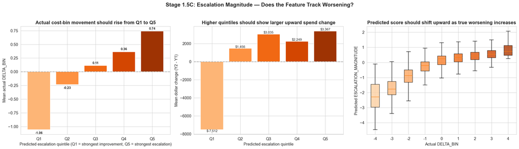

```python
# VISUALIZATION: Stage 1.5C - Escalation Magnitude

if 'ESCALATION_MAGNITUDE' in df.columns:

    fig, axes = plt.subplots(1, 3, figsize=(20, 5.5))
    fig.suptitle('Stage 1.5C: Escalation Magnitude — Does the Feature Track Worsening?', fontsize=15, fontweight='bold', y=1.03)

    viz = df[['ESCALATION_MAGNITUDE', 'DELTA_BIN', 'COST_Y1_ADJ', 'COST_Y2_ADJ']].copy()
    viz['DOLLAR_CHANGE'] = viz['COST_Y2_ADJ'] - viz['COST_Y1_ADJ']
    viz['_esc_quintile'] = pd.qcut(
        viz['ESCALATION_MAGNITUDE'].rank(method='first'),
        q=5,
        labels=['Q1', 'Q2', 'Q3', 'Q4', 'Q5']
    )

    stats = viz.groupby('_esc_quintile').agg(
        mean_delta=('DELTA_BIN', 'mean'),
        mean_dollar_change=('DOLLAR_CHANGE', 'mean'),
        mean_y1_cost=('COST_Y1_ADJ', 'mean'),
        mean_y2_cost=('COST_Y2_ADJ', 'mean'),
        count=('DELTA_BIN', 'count')
    ).reset_index()

    # Panel 1: actual delta by predicted quintile
    ax1 = axes[0]
    colors = plt.cm.Oranges(np.linspace(0.35, 0.9, 5))
    bars = ax1.bar(stats['_esc_quintile'], stats['mean_delta'], color=colors, edgecolor='white')
    ax1.axhline(0, color='gray', linestyle='--', alpha=0.6)
    for bar, val in zip(bars, stats['mean_delta']):
        ax1.text(bar.get_x() + bar.get_width()/2, val + (0.03 if val >= 0 else -0.08), f'{val:.2f}', ha='center', fontsize=9, fontweight='bold')
    ax1.set_xlabel('Predicted escalation quintile (Q1 = strongest improvement, Q5 = strongest escalation)')
    ax1.set_ylabel('Mean actual DELTA_BIN')
    ax1.set_title('Actual cost-bin movement should rise from Q1 to Q5', fontweight='bold')

    # Panel 2: dollar change rather than raw Y2 cost
    ax2 = axes[1]
    bars2 = ax2.bar(stats['_esc_quintile'], stats['mean_dollar_change'], color=colors, edgecolor='white')
    ax2.axhline(0, color='gray', linestyle='--', alpha=0.6)
    for bar, val in zip(bars2, stats['mean_dollar_change']):
        ax2.text(bar.get_x() + bar.get_width()/2, val, f'${val:,.0f}', ha='center', va='bottom' if val >= 0 else 'top', fontsize=9)
    ax2.set_xlabel('Predicted escalation quintile')
    ax2.set_ylabel('Mean dollar change (Y2 - Y1)')
    ax2.set_title('Higher quintiles should show larger upward spend change', fontweight='bold')

    # Panel 3: predicted magnitude by true delta bin
    ax3 = axes[2]
    delta_order = sorted(viz['DELTA_BIN'].dropna().unique())
    box_data = [viz.loc[viz['DELTA_BIN'] == d, 'ESCALATION_MAGNITUDE'].values for d in delta_order]
    bp = ax3.boxplot(box_data, labels=[str(d) for d in delta_order], patch_artist=True, showfliers=False)
    for patch, c in zip(bp['boxes'], plt.cm.Oranges(np.linspace(0.25, 0.85, len(delta_order)))):
        patch.set_facecolor(c)
        patch.set_alpha(0.8)
    ax3.set_xlabel('Actual DELTA_BIN')
    ax3.set_ylabel('Predicted ESCALATION_MAGNITUDE')
    ax3.set_title('Predicted score should shift upward as true worsening increases', fontweight='bold')

    plt.tight_layout()
    plt.savefig(REPORT_DIR / 'figures' / 'stage1_5c_escalation_magnitude.png', dpi=150, bbox_inches='tight')
    plt.show()
```

### Interpretation: Escalation Magnitude Feature

This figure is validating an engineered predictor, not a final model output.

**Axes and meaning**

- In panel 1, the x-axis is the predicted escalation quintile:
  - `Q1` = patients predicted to improve the most
  - `Q5` = patients predicted to worsen the most
- The y-axis is the **actual mean `DELTA_BIN`**. If the feature works, this should rise steadily from negative to positive.
- In panel 2, the y-axis is **mean dollar change (`Y2 - Y1`)**, not raw Year 2 cost. That is a more useful healthcare quantity here because the feature is supposed to capture **movement**, not simply absolute spend level.
- In panel 3, each box shows the distribution of predicted `ESCALATION_MAGNITUDE` for one true `DELTA_BIN` group. If the boxes shift upward as actual `DELTA_BIN` increases, the feature is ranking worsening correctly.

**Healthcare insight**

`ESCALATION_MAGNITUDE` is useful because it separates two very different situations that raw Y1 cost alone cannot:

- expensive patients who are likely to improve or stabilize,
- moderate-cost patients who are likely to jump upward next year.

That is exactly the kind of feature Stage 2 needs when expenditure is highly skewed and transition direction matters as much as baseline cost.

## Stage 1.5D: Removed Composite Escalation Score

A prior deterministic composite (`ESCALATION_SCORE`) was removed because:

1. Its components already existed directly in the base feature set.
2. It was highly redundant with Stage 1 latent outputs.
3. `ESCALATION_MAGNITUDE` (OOF model-based) captures nonlinear structure more effectively.

```python
# STAGE 1.5D: REMOVED (Previously: Cost Escalation Pattern Score)
#
# ESCALATION_SCORE was a weighted average of normalize(CHRONIC_COUNT),
# normalize(CNT_ILL_DEFINED), normalize(UTIL_IP_Y1), normalize(POLYPHARMACY_FLAG).
#
# Why removed:
# 1. Correlation with LATENT_RISK_SCORE: r=0.73 (highly redundant with Stage 1)
# 2. All its components (CHRONIC_COUNT, UTIL_IP_Y1, etc.) are already in the
#    original feature set — wrapping them in a mean adds no new information.
# 3. The new ESCALATION_MAGNITUDE (1.5C) is model-based and more powerful.
#
print("STAGE 1.5D: REMOVED — ESCALATION_SCORE was redundant with Stage 1 features.")
print("  Replaced by ESCALATION_MAGNITUDE (regression-based, captures nonlinear interactions).")
```

```
STAGE 1.5D: REMOVED — ESCALATION_SCORE was redundant with Stage 1 features.
  Replaced by ESCALATION_MAGNITUDE (regression-based, captures nonlinear interactions).
```

## Stage 1.5E: Medication Adherence — Raw Feature Pass-Through

**Previous approach:** Trained a GradientBoosting classifier on Rx features + clinical features to predict P(Rising or Shock). The resulting HAZARD_DISCONTINUE had r=0.91 with LATENT_RISK_SCORE — nearly identical to Stage 1.

**New approach:** Skip the model entirely. The 4 raw Rx timeline features (RX_DENSITY, RX_GAP_RATIO, RX_TRAILING_GAP, RX_REGULARITY) extracted from MEPS prescribed medicines files are passed directly to Stage 2. These contain genuinely new information — temporal prescription patterns — that no other feature in the dataset captures.

```python
# STAGE 1.5E: MEDICATION ADHERENCE RISK - Data Preparation
#
# Goal: Extract medication timeline from Rx data to construct adherence features
#
# Key Concepts:
# - TIME: Time from observation start to event (months)
# - EVENT: Whether event occurred (1=yes, 0=censored)
# - CENSORING: Observation ended but event didn't occur; we don't know if it will happen later
#

print("="*60)
print("STAGE 1.5E: Survival Analysis - Treatment Discontinuation")
print("="*60)

# Panel mapping for medication files
PANEL_MEDS_MAP = {
    18: {'meds': 'h160a', 'year1': 2013},
    19: {'meds': 'h168a', 'year1': 2014},
    20: {'meds': 'h178a', 'year1': 2015},
    21: {'meds': 'h188a', 'year1': 2016},
    22: {'meds': 'h206a', 'year1': 2017},
    23: {'meds': 'h206a', 'year1': 2018},
}

# Data directories
MEDS_DIR = Path('../archive_v1/data/processed')
MEDS_DIR_V2 = Path('../data/processed_v2')

def extract_medication_timeline(panel_id, panel_info):
    """
    Extract medication timeline from prescription files for each patient

    Returns: DataFrame with columns:
    - DUPERSID: Patient ID
    - FIRST_RX_MONTH: First prescription month (1-24, 1=Year1 Jan, 13=Year2 Jan)
    - LAST_RX_MONTH: Last prescription month
    - RX_MONTHS: List of months with prescriptions
    - TOTAL_RX_COUNT: Total prescription count
    - GAP_MAX: Maximum consecutive gap without prescriptions (months)
    """
    meds_file = MEDS_DIR / f"{panel_info['meds']}.parquet"
    if not meds_file.exists():
        meds_file = MEDS_DIR_V2 / f"{panel_info['meds']}.parquet"

    if not meds_file.exists():
        print(f"  Panel {panel_id}: Medication file not found, skipping")
        return None

    try:
        meds = pd.read_parquet(meds_file)
    except Exception as e:
        print(f"  Panel {panel_id}: Error reading file - {e}")
        return None

    year1 = panel_info['year1']
    year2 = year1 + 1

    # Look for time columns - MEPS prescription files typically have RXBEGMM (month) and RXBEGYR (year)
    # Or date-formatted variables
    time_cols_mm = [c for c in meds.columns if 'RXBEG' in c.upper() and 'MM' in c.upper()]
    time_cols_yr = [c for c in meds.columns if 'RXBEG' in c.upper() and 'YR' in c.upper()]

    if not time_cols_mm or not time_cols_yr:
        # Try other naming patterns
        time_cols_mm = [c for c in meds.columns if 'PURCHMM' in c.upper() or 'FILLMM' in c.upper()]
        time_cols_yr = [c for c in meds.columns if 'PURCHYR' in c.upper() or 'FILLYR' in c.upper()]

    if not time_cols_mm:
        print(f"  Panel {panel_id}: No time columns found. Available: {list(meds.columns)[:10]}...")
        return None

    mm_col = time_cols_mm[0]
    yr_col = time_cols_yr[0] if time_cols_yr else None

    print(f"  Panel {panel_id}: Using time columns {mm_col}, {yr_col}")

    # Calculate relative month (1 = Year1 January, 13 = Year2 January, 24 = Year2 December)
    def calc_relative_month(row):
        month = row[mm_col]
        if pd.isna(month) or month < 1 or month > 12:
            return None

        if yr_col and yr_col in row.index:
            year = row[yr_col]
            if year == year1:
                return int(month)  # 1-12
            elif year == year2:
                return int(month) + 12  # 13-24
            else:
                return None
        else:
            # If no year info, assume sequential order
            return int(month)

    meds['REL_MONTH'] = meds.apply(calc_relative_month, axis=1)
    meds = meds.dropna(subset=['REL_MONTH', 'DUPERSID'])

    if len(meds) == 0:
        print(f"  Panel {panel_id}: No valid records after time processing")
        return None

    # Aggregate by patient
    patient_timeline = meds.groupby('DUPERSID').agg({
        'REL_MONTH': ['min', 'max', 'count', lambda x: sorted(x.unique().tolist())]
    }).reset_index()

    patient_timeline.columns = ['DUPERSID', 'FIRST_RX_MONTH', 'LAST_RX_MONTH',
                                 'TOTAL_RX_COUNT', 'RX_MONTHS']

    # Calculate maximum gap
    def calc_max_gap(months_list):
        if len(months_list) < 2:
            return 0
        months_sorted = sorted(months_list)
        max_gap = 0
        for i in range(1, len(months_sorted)):
            gap = months_sorted[i] - months_sorted[i-1] - 1
            max_gap = max(max_gap, gap)
        return max_gap

    patient_timeline['GAP_MAX'] = patient_timeline['RX_MONTHS'].apply(calc_max_gap)
    patient_timeline['PANEL'] = panel_id

    print(f"  Panel {panel_id}: Extracted timeline for {len(patient_timeline)} patients")
    return patient_timeline

# Extract medication timeline for all panels
print("\n--- Extracting Medication Timelines ---")
all_timelines = []

for panel_id, panel_info in PANEL_MEDS_MAP.items():
    timeline = extract_medication_timeline(panel_id, panel_info)
    if timeline is not None:
        all_timelines.append(timeline)

if all_timelines:
    medication_timeline_df = pd.concat(all_timelines, ignore_index=True)
    print(f"\n✓ Total patients with medication timeline: {len(medication_timeline_df):,}")
else:
    print("\n⚠ No medication timeline data extracted. Creating dummy variables.")
    medication_timeline_df = None
```

```
============================================================
STAGE 1.5E: Survival Analysis - Treatment Discontinuation
============================================================

--- Extracting Medication Timelines ---
```

```
  Panel 18: Using time columns RXBEGMM, RXBEGYRX
```

```
  Panel 18: Extracted timeline for 14063 patients
  Panel 19: Using time columns RXBEGMM, RXBEGYRX
```

```
  Panel 19: Extracted timeline for 13390 patients
  Panel 20: Using time columns RXBEGMM, RXBEGYRX
```

```
  Panel 20: Extracted timeline for 13674 patients
  Panel 21: Using time columns RXBEGMM, RXBEGYRX
```

```
  Panel 21: Extracted timeline for 12955 patients
  Panel 22: Using time columns RXBEGMM, RXBEGYRX
```

```
  Panel 22: Extracted timeline for 13998 patients
  Panel 23: Using time columns RXBEGMM, RXBEGYRX
```

```
  Panel 23: Extracted timeline for 12268 patients

✓ Total patients with medication timeline: 80,348
```

```python
# STAGE 1.5E: Construct Medication Adherence Risk Score
#
# Problem with original approach: MEPS medication data covers Year 1 only for most
# patients, so with observation_end=24 months, 100% of patients "discontinue"
# (no one has fills in months 13-24 if only Y1 Rx data exists).
#
# Revised approach: Construct a MEDICATION ADHERENCE RISK score from Year 1 Rx
# timeline features. Patients with poor adherence (large gaps, early drop-off,
# low fill density) are at higher risk of adverse outcomes in Year 2.
#
# This is clinically grounded: medication non-adherence is one of the strongest
# predictors of hospitalization and cost escalation (Sokol et al., 2005;
# Roebuck et al., 2011).

print("\n--- Constructing Medication Adherence Risk Score ---")

def construct_adherence_variables(timeline_df):
    """
    Construct medication adherence risk variables from Year 1 Rx timeline.

    Output variables:
    - RX_DENSITY: Proportion of Y1 months with at least one fill (0-1)
    - RX_GAP_RATIO: Max gap / observation months (0-1, higher = worse adherence)
    - RX_TRAILING_GAP: Months from last fill to end of Y1 (higher = dropped off)
    - RX_REGULARITY: Std dev of inter-fill gaps (higher = more erratic)
    """
    if timeline_df is None or len(timeline_df) == 0:
        return None

    survival_data = timeline_df.copy()

    def calc_adherence(row):
        rx_months = row['RX_MONTHS']
        first_rx = row['FIRST_RX_MONTH']
        last_rx = row['LAST_RX_MONTH']
        max_gap = row['GAP_MAX']

        if not rx_months or len(rx_months) == 0:
            return 0.0, 1.0, 12.0, 0.0

        # Only consider Year 1 months (1-12)
        y1_months = sorted([m for m in rx_months if 1 <= m <= 12])

        if len(y1_months) == 0:
            return 0.0, 1.0, 12.0, 0.0

        unique_months = len(set(y1_months))
        observation_span = 12  # Year 1 = 12 months

        # RX_DENSITY: fraction of Y1 months with at least one fill
        density = unique_months / observation_span

        # RX_GAP_RATIO: max gap relative to observation
        y1_max_gap = 0
        for i in range(1, len(y1_months)):
            gap = y1_months[i] - y1_months[i-1] - 1
            y1_max_gap = max(y1_max_gap, gap)
        gap_ratio = y1_max_gap / observation_span

        # RX_TRAILING_GAP: months from last Y1 fill to end of Y1
        trailing = 12 - max(y1_months)

        # RX_REGULARITY: std of inter-fill intervals (0 if only 1 month)
        if len(y1_months) > 1:
            intervals = [y1_months[i] - y1_months[i-1] for i in range(1, len(y1_months))]
            regularity = float(np.std(intervals))
        else:
            regularity = 0.0

        return density, gap_ratio, float(trailing), regularity

    results = survival_data.apply(calc_adherence, axis=1, result_type='expand')
    survival_data['RX_DENSITY'] = results[0]
    survival_data['RX_GAP_RATIO'] = results[1]
    survival_data['RX_TRAILING_GAP'] = results[2]
    survival_data['RX_REGULARITY'] = results[3]

    return survival_data

if medication_timeline_df is not None:
    survival_df = construct_adherence_variables(medication_timeline_df)

    if survival_df is not None:
        print(f"\n=== Medication Adherence Summary ===")
        print(f"Total patients with Rx data: {len(survival_df):,}")

        for col in ['RX_DENSITY', 'RX_GAP_RATIO', 'RX_TRAILING_GAP', 'RX_REGULARITY']:
            s = survival_df[col]
            print(f"\n  {col}:")
            print(f"    Mean: {s.mean():.3f}, Std: {s.std():.3f}, Range: [{s.min():.2f}, {s.max():.2f}]")
else:
    survival_df = None
    print("Warning: Survival data not available. Skipping.")
```

```
--- Constructing Medication Adherence Risk Score ---
```

```
=== Medication Adherence Summary ===
Total patients with Rx data: 80,348

  RX_DENSITY:
    Mean: 0.119, Std: 0.087, Range: [0.00, 0.83]

  RX_GAP_RATIO:
    Mean: 0.206, Std: 0.333, Range: [0.00, 1.00]

  RX_TRAILING_GAP:
    Mean: 5.664, Std: 4.036, Range: [0.00, 12.00]

  RX_REGULARITY:
    Mean: 0.166, Std: 0.559, Range: [0.00, 4.50]
```

```python
# STAGE 1.5E: Medication Adherence - Raw Feature Pass-Through
#
# Previous approach wrapped Rx timeline variables into a classifier output
# that was highly redundant with Stage 1 latent risk.
#
# Current approach passes raw timeline variables directly and tracks whether
# each row required default imputation after merge.

print()
print("Stage 1.5E: Merging Raw Rx Timeline Features (No Model Wrapper)")

RX_FEATS = ['RX_DENSITY', 'RX_GAP_RATIO', 'RX_TRAILING_GAP', 'RX_REGULARITY']

if survival_df is not None and len(survival_df) > 100:

    survival_df['DUPERSID'] = survival_df['DUPERSID'].astype(str)
    df['DUPERSID'] = df['DUPERSID'].astype(str)

    merge_cols = ['DUPERSID', 'PANEL'] + RX_FEATS
    df_surv = df.merge(
        survival_df[merge_cols],
        on=['DUPERSID', 'PANEL'],
        how='left',
    )

    matched = df_surv['RX_DENSITY'].notna()
    match_rate = matched.mean() * 100
    print(f"  Match rate: {match_rate:.1f}%")

    panel_match = df_surv.groupby('PANEL')['RX_DENSITY'].apply(lambda s: s.notna().mean()).round(3)
    print("  Match rate by panel:")
    print(panel_match.to_string())

    # Track rows without timeline data
    df_surv['RX_TIMELINE_IMPUTED'] = (~matched).astype(int)

    # Fill unmatched rows with conservative defaults
    fill_defaults = {
        'RX_DENSITY': 0.0,
        'RX_GAP_RATIO': 1.0,
        'RX_TRAILING_GAP': 12.0,
        'RX_REGULARITY': 0.0,
    }
    for col, default in fill_defaults.items():
        df_surv[col] = df_surv[col].fillna(default)

    for col in RX_FEATS + ['RX_TIMELINE_IMPUTED']:
        df[col] = df_surv[col].values

    if match_rate < 50:
        print("  Warning: Rx timeline merge coverage is low; imputation flag kept for Stage 2.")

    print()
    print("  Raw Rx features merged (no model wrapper):")
    for col in RX_FEATS:
        print(f"    {col}: mean={df[col].mean():.3f}, std={df[col].std():.3f}")
    print(f"    RX_TIMELINE_IMPUTED: mean={df['RX_TIMELINE_IMPUTED'].mean():.3f}")

    print()
    print("  Correlation with COST_Y2_ADJ:")
    for col in RX_FEATS + ['RX_TIMELINE_IMPUTED']:
        r = df[col].corr(df['COST_Y2_ADJ'])
        print(f"    {col}: r = {r:.3f}")

else:
    print("  Warning: No medication timeline data. Setting Rx features to defaults + imputed flag.")
    df['RX_DENSITY'] = 0.0
    df['RX_GAP_RATIO'] = 1.0
    df['RX_TRAILING_GAP'] = 12.0
    df['RX_REGULARITY'] = 0.0
    df['RX_TIMELINE_IMPUTED'] = 1

print()
print("  Done. Raw Rx features available for Stage 2.")
```

```
Stage 1.5E: Merging Raw Rx Timeline Features (No Model Wrapper)
  Match rate: 43.8%
  Match rate by panel:
PANEL
18    0.420
19    0.427
20    0.430
21    0.415
22    0.500
23    0.439
  Warning: Rx timeline merge coverage is low; imputation flag kept for Stage 2.

  Raw Rx features merged (no model wrapper):
    RX_DENSITY: mean=0.054, std=0.085
    RX_GAP_RATIO: mean=0.648, std=0.451
    RX_TRAILING_GAP: mean=9.167, std=4.135
    RX_REGULARITY: mean=0.078, std=0.392
    RX_TIMELINE_IMPUTED: mean=0.562

  Correlation with COST_Y2_ADJ:
    RX_DENSITY: r = 0.199
    RX_GAP_RATIO: r = -0.142
    RX_TRAILING_GAP: r = -0.166
    RX_REGULARITY: r = 0.115
    RX_TIMELINE_IMPUTED: r = -0.183

  Done. Raw Rx features available for Stage 2.
```

```
--- Rx Timeline Feature Visualizations ---
```

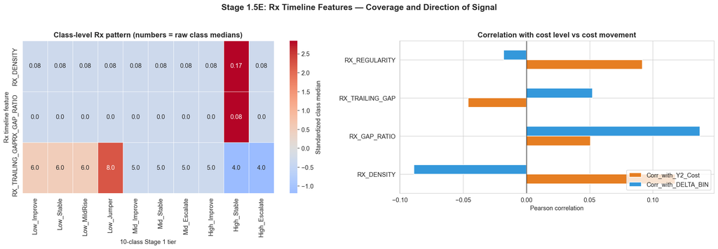

```python
# STAGE 1.5E: Raw Rx Feature Visualization (readable summary)

print()
print("--- Rx Timeline Feature Visualizations ---")

RX_VIZ_FEATS = ['RX_DENSITY', 'RX_GAP_RATIO', 'RX_TRAILING_GAP', 'RX_REGULARITY']

if all(f in df.columns for f in RX_VIZ_FEATS) and df['RX_DENSITY'].notna().sum() > 100:

    hv = df[df['RX_TIMELINE_IMPUTED'] == 0].copy() if 'RX_TIMELINE_IMPUTED' in df.columns else df.copy()
    tier_labels = {t: CLASS_NAMES.get(t, str(t)) for t in sorted(hv['RISK_TIER'].unique())}

    corr_feats = []
    heatmap_feats = []
    for feat in RX_VIZ_FEATS:
        if hv[feat].nunique(dropna=True) > 1 and hv[feat].std() > 1e-8:
            corr_feats.append(feat)
            class_medians = hv.groupby('RISK_TIER')[feat].median().round(3)
            if class_medians.nunique() > 1:
                heatmap_feats.append(feat)

    if len(corr_feats) == 0:
        print("All Rx timeline features are constant after merge; skipping plot.")
    else:
        corr_rows = []
        for feat in corr_feats:
            corr_rows.append({
                'Feature': feat,
                'Corr_with_Y2_Cost': hv[feat].corr(hv['COST_Y2_ADJ']),
                'Corr_with_DELTA_BIN': hv[feat].corr(hv['DELTA_BIN']) if 'DELTA_BIN' in hv.columns else np.nan,
            })
        corr_df = pd.DataFrame(corr_rows).set_index('Feature')

        fig, axes = plt.subplots(1, 2, figsize=(18, 6))
        fig.suptitle('Stage 1.5E: Rx Timeline Features — Coverage and Direction of Signal', fontsize=15, fontweight='bold', y=1.03)

        if heatmap_feats:
            median_table = (
                hv.groupby('RISK_TIER')[heatmap_feats]
                .median()
                .rename(index=tier_labels)
            )

            # Standardize medians for readability across different units
            heatmap_input = median_table.copy()
            for col in heatmap_input.columns:
                col_std = heatmap_input[col].std()
                if col_std > 1e-12:
                    heatmap_input[col] = (heatmap_input[col] - heatmap_input[col].mean()) / col_std
                else:
                    heatmap_input[col] = 0.0

            sns.heatmap(
                heatmap_input.T,
                cmap='coolwarm',
                center=0,
                annot=median_table.T.round(2),
                fmt='',
                linewidths=0.5,
                ax=axes[0],
                cbar_kws={'label': 'Standardized class median'}
            )
            axes[0].set_title('Class-level Rx pattern (numbers = raw class medians)', fontweight='bold')
            axes[0].set_xlabel('10-class Stage 1 tier')
            axes[0].set_ylabel('Rx timeline feature')
        else:
            axes[0].axis('off')
            axes[0].text(
                0.5, 0.5,
                'Class medians were flat after merge;\nshowing only the correlation summary on the right.',
                ha='center', va='center', fontsize=11
            )

        corr_plot = corr_df[['Corr_with_Y2_Cost', 'Corr_with_DELTA_BIN']]
        corr_plot.plot(kind='barh', ax=axes[1], color=['#e67e22', '#3498db'], edgecolor='white')
        axes[1].axvline(0, color='black', lw=0.8)
        axes[1].set_title('Correlation with cost level vs cost movement', fontweight='bold')
        axes[1].set_xlabel('Pearson correlation')
        axes[1].set_ylabel('')
        axes[1].legend(loc='lower right')

        plt.tight_layout()
        plt.savefig(REPORT_DIR / 'figures' / 'stage1_5e_rx_features.png', dpi=150, bbox_inches='tight')
        plt.show()

        dropped = [f for f in RX_VIZ_FEATS if f not in corr_feats]
        if dropped:
            print(f"Dropped from plot because they were constant or visually uninformative: {dropped}")

else:
    print("Rx timeline features not available for visualization.")
```

### Interpretation: Raw Rx Timeline Features (Stage 1.5E)

The earlier boxplots were difficult to read because these variables are on very different scales and some had almost no variation. This revised figure is answering two simpler questions.

**Panel 1: Which risk tiers have different refill patterns?**

- Each cell is one Stage 1 risk tier by one Rx timeline feature.
- The color shows the median relative to other tiers.
- The number inside each cell is the **raw median**, so the plot stays interpretable in the original units.
- If a feature has almost no between-class median variation, we leave it out of the heatmap instead of showing a meaningless row of zeros.

**Panel 2: Are these features related to cost level or cost movement?**

- `Corr_with_Y2_Cost` asks whether the feature is associated with higher or lower Year 2 spending.
- `Corr_with_DELTA_BIN` asks whether it is associated with upward or downward movement in cost bins.

**Healthcare interpretation**

- `RX_DENSITY` and `RX_REGULARITY` are closer to medication continuity.
- `RX_GAP_RATIO` and `RX_TRAILING_GAP` are closer to refill disruption or discontinuation.
- A feature is most useful when it adds information not already contained in baseline cost and when its sign makes clinical sense.

If a feature is constant after merge or too sparse to interpret reliably, we drop it from the visual rather than forcing an empty plot into the notebook.

## Stage 1.5 Summary: All Latent Factors

The correlation matrix below shows how each latent factor relates to the others and to Y2 cost. Key things to look for:

- **Correlation with COST_Y2_ADJ:** Factors with |r| > 0.1 add signal
- **Inter-factor correlation:** Low correlation between Stage 1.5 factors means they capture different aspects of risk (desirable); high correlation means redundancy
- **Correlation with LATENT_RISK_SCORE:** Factors that are independent of the Stage 1 score add the most marginal value to Stage 2

```python
# STAGE 1.5 SUMMARY

print("STAGE 1.5 SUMMARY: Intermediate Latent Factors")


# All Stage 1.5 enrichment features
stage1_5_factors = [
    'ENGAGEMENT_SCORE',       # Stage 1.5B: Healthcare Engagement (direct calc)
    'ESCALATION_MAGNITUDE',   # Stage 1.5C: Predicted cost bin change (regression)
]

# Raw Rx features passed through from 1.5E (not model-wrapped)
rx_pass_through = ['RX_DENSITY', 'RX_GAP_RATIO', 'RX_TRAILING_GAP', 'RX_REGULARITY']

all_enrichment_features = stage1_5_factors + rx_pass_through

# Summary statistics
summary_data = []
for factor in all_enrichment_features:
    if factor in df.columns:
        summary_data.append({
            'Feature': factor,
            'Mean': df[factor].mean(),
            'Std': df[factor].std(),
            'Min': df[factor].min(),
            'Max': df[factor].max()
        })

summary_df = pd.DataFrame(summary_data)
print("\n" + summary_df.to_string(index=False))

# Correlation with target and DELTA_BIN
print("\n\nCorrelation with COST_Y2_ADJ and DELTA_BIN:")
for factor in all_enrichment_features:
    if factor in df.columns:
        r_cost = df[factor].corr(df['COST_Y2_ADJ'])
        r_delta = df[factor].corr(df['DELTA_BIN']) if 'DELTA_BIN' in df.columns else np.nan
        r_latent = df[factor].corr(df['LATENT_RISK_SCORE']) if 'LATENT_RISK_SCORE' in df.columns else np.nan
        print(f"  {factor:25s}: r_cost={r_cost:.3f}, r_delta={r_delta:.3f}, r_latent={r_latent:.3f}")
```

```
STAGE 1.5 SUMMARY: Intermediate Latent Factors

             Feature      Mean      Std       Min       Max
    ENGAGEMENT_SCORE  0.150575 0.236308 -1.000000  0.666667
ESCALATION_MAGNITUDE -0.015314 0.673303 -4.464572  3.338868
          RX_DENSITY  0.054352 0.085387  0.000000  0.833333
        RX_GAP_RATIO  0.647756 0.451065  0.000000  1.000000
     RX_TRAILING_GAP  9.166859 4.134775  0.000000 12.000000
       RX_REGULARITY  0.078343 0.391858  0.000000  4.500000


Correlation with COST_Y2_ADJ and DELTA_BIN:
  ENGAGEMENT_SCORE         : r_cost=0.235, r_delta=-0.058, r_latent=-0.226
  ESCALATION_MAGNITUDE     : r_cost=-0.095, r_delta=0.598, r_latent=0.897
  RX_DENSITY               : r_cost=0.199, r_delta=-0.109, r_latent=-0.229
  RX_GAP_RATIO             : r_cost=-0.142, r_delta=0.125, r_latent=0.251
  RX_TRAILING_GAP          : r_cost=-0.166, r_delta=0.094, r_latent=0.231
  RX_REGULARITY            : r_cost=0.115, r_delta=-0.033, r_latent=-0.080
```

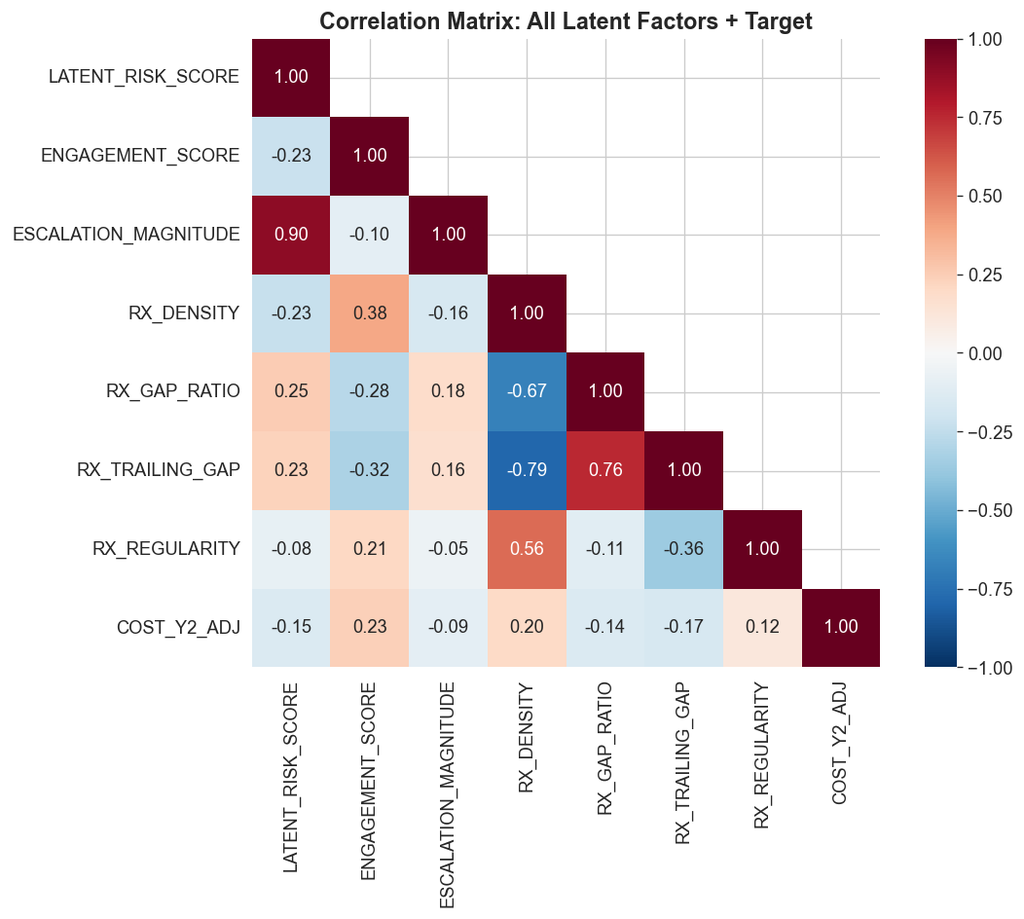

```python
# Correlation heatmap of all latent factors
latent_cols = ['LATENT_RISK_SCORE'] + all_enrichment_features
latent_cols = [c for c in latent_cols if c in df.columns]

if len(latent_cols) > 2:
    fig, ax = plt.subplots(figsize=(10, 8))

    corr_matrix = df[latent_cols + ['COST_Y2_ADJ']].corr()

    mask = np.triu(np.ones_like(corr_matrix, dtype=bool), k=1)
    sns.heatmap(corr_matrix, mask=mask, annot=True, fmt='.2f',
                cmap='RdBu_r', center=0, vmin=-1, vmax=1,
                square=True, ax=ax)

    ax.set_title('Correlation Matrix: All Latent Factors + Target', fontsize=14, fontweight='bold')

    plt.tight_layout()
    plt.savefig(REPORT_DIR / 'figures' / 'latent_factors_correlation.png', dpi=150)
    plt.show()
else:
    print("Insufficient latent factors for correlation heatmap")
```

### Latent Factors Correlation Matrix

This heatmap is a **screening tool**, not a proof by itself.

Use it to answer:

- Which engineered variables are actually related to Year 2 cost?
- Which ones are mostly duplicating `LATENT_RISK_SCORE`?
- Which ones seem to capture a different aspect of risk, such as care pattern, transition direction, or medication continuity?

A good Stage 1.5 feature does not have to dominate cost prediction on its own. It only needs to add a piece of information that is plausibly useful **after baseline cost is already known**.

# STAGE 2: Expenditure Prediction (Transition-Based)

**Goal:** Predict individual Year 2 cost from Year 1 features + Stage 1/1.5 enrichment.

**Design choices in this version:**

1. 10-class transition system (same `RISK_TIER` definition as Stage 1)
2. Leakage-safe inference routing by `STAGE1_PRED_CLASS` (not true tier labels)
3. Class-specific models with class-dependent regularization
4. Global fallback model for missing/unstable class models
5. Duan's smearing correction applied consistently for dollar-scale predictions

**Feature blocks:**

- Original Year 1 features
- Engineered interactions
- Stage 1 outputs (`PROB_*`, `LATENT_RISK_SCORE`)
- Stage 1.5 enrichment (`ENGAGEMENT_SCORE`, `ESCALATION_MAGNITUDE`, `RX_*`, optional imputation flag)

```python
# STAGE 2: Feature Preparation (2D Classification, 10 Classes)
print('STAGE 2: 2D Class-Specific Cost Prediction (Hard vs Soft Routing)')

ORIGINAL_FEATS = [
    'AGE_Y1', 'SEX', 'RACE', 'MARRY_Y1', 'POVCAT_Y1', 'INSCOV_Y1',
    'MNHLTH_RD1', 'RTHLTH_RD1',
    'CHRONIC_COUNT', 'DIAB_Y1_FLAG', 'HIBP_Y1_FLAG', 'CHOL_Y1_FLAG',
    'UTIL_ER_Y1', 'UTIL_IP_Y1', 'UTIL_OB_Y1', 'UTIL_RX_Y1',
    'CNT_TOTAL_CONDITIONS', 'CNT_ILL_DEFINED', 'CNT_RX_Y1',
    'RATIO_ER_OFFICE', 'COST_Y1_ADJ'
]

STAGE1_5_FEATS = [
    'ENGAGEMENT_SCORE',
    'ESCALATION_MAGNITUDE',
    'RX_DENSITY',
    'RX_GAP_RATIO',
    'RX_TRAILING_GAP',
    'RX_REGULARITY',
    'RX_TIMELINE_IMPUTED',
]

# Engineered interaction features
df['LOG_COST_Y1'] = np.log1p(df['COST_Y1_ADJ'].clip(lower=0))
df['COST_X_CHRONIC'] = df['COST_Y1_ADJ'] * df['CHRONIC_COUNT']
df['AGE_X_CHRONIC'] = df['AGE_Y1'] * df['CHRONIC_COUNT']
df['UTIL_TOTAL_Y1'] = df['UTIL_ER_Y1'] + df['UTIL_IP_Y1'] + df['UTIL_OB_Y1'] + df['UTIL_RX_Y1']
df['IP_FLAG'] = (df['UTIL_IP_Y1'] > 0).astype(int)
df['HIGH_COST_FLAG'] = (df['COST_Y1_ADJ'] > df['COST_Y1_ADJ'].quantile(0.75)).astype(int)

INTERACTION_FEATS = [
    'LOG_COST_Y1', 'COST_X_CHRONIC', 'AGE_X_CHRONIC',
    'UTIL_TOTAL_Y1', 'IP_FLAG', 'HIGH_COST_FLAG'
]

# Validate Stage 1 probability columns
class_order = np.array(sorted(CLASS_NAMES.keys()))
prob_cols_primary = [f"PROB_{CLASS_NAMES[c].upper()}" for c in class_order]
prob_cols_alias = [f"P_{CLASS_NAMES[c].upper()}" for c in class_order]

if all(c in df.columns for c in prob_cols_primary):
    stage1_prob_cols = prob_cols_primary
elif all(c in df.columns for c in prob_cols_alias):
    stage1_prob_cols = prob_cols_alias
else:
    missing = [c for c in prob_cols_primary if c not in df.columns]
    raise ValueError(
        "Missing Stage 1 probability columns required for routing: " + ", ".join(missing)
    )

prob_matrix = df[stage1_prob_cols].to_numpy()

# Standardize Stage 1 decision fields for Stage 2
if 'pred_class_hard' not in df.columns:
    df['pred_class_hard'] = class_order[prob_matrix.argmax(axis=1)]
if 'pred_class_policy' not in df.columns:
    df['pred_class_policy'] = df['pred_class_hard']
if 'review_flag' not in df.columns:
    df['review_flag'] = 0
if 'uncertainty_score' not in df.columns:
    if 'PRED_ENTROPY' in df.columns:
        df['uncertainty_score'] = df['PRED_ENTROPY'] / np.log(len(class_order))
    else:
        df['uncertainty_score'] = 0.0

# Keep compatibility label
if 'STAGE1_PRED_CLASS' not in df.columns:
    df['STAGE1_PRED_CLASS'] = df['pred_class_hard']

original_avail = [f for f in ORIGINAL_FEATS if f in df.columns]
stage1_5_avail = [f for f in STAGE1_5_FEATS if f in df.columns]
interact_avail = [f for f in INTERACTION_FEATS if f in df.columns]

# Tier-specific model features
TIER_FEATS = original_avail + interact_avail + ['LATENT_RISK_SCORE'] + stage1_5_avail + ['uncertainty_score']
TIER_FEATS = [f for f in TIER_FEATS if f in df.columns]

# Global model features include per-class probabilities and decision uncertainty
ALL_FEATS = original_avail + interact_avail + stage1_prob_cols + ['LATENT_RISK_SCORE'] + stage1_5_avail + ['uncertainty_score']
ALL_FEATS = [f for f in ALL_FEATS if f in df.columns]

print(f'Tier-specific features ({len(TIER_FEATS)}): {TIER_FEATS}')
print(f'Global features ({len(ALL_FEATS)})')
print(f'Stage 1.5 features: {stage1_5_avail}')

agreement_hard = (df['pred_class_hard'] == df['RISK_TIER']).mean()
policy_coverage = (df['pred_class_policy'] >= 0).mean()
print(f'Stage 1 hard-class agreement vs true tier: {agreement_hard:.3f}')
print(f'Stage 1 policy coverage (non-REVIEW): {policy_coverage:.3f}')
```

```
STAGE 2: 2D Class-Specific Cost Prediction (Hard vs Soft Routing)
Tier-specific features (36): ['AGE_Y1', 'SEX', 'RACE', 'MARRY_Y1', 'POVCAT_Y1', 'INSCOV_Y1', 'MNHLTH_RD1', 'RTHLTH_RD1', 'CHRONIC_COUNT', 'DIAB_Y1_FLAG', 'HIBP_Y1_FLAG', 'CHOL_Y1_FLAG', 'UTIL_ER_Y1', 'UTIL_IP_Y1', 'UTIL_OB_Y1', 'UTIL_RX_Y1', 'CNT_TOTAL_CONDITIONS', 'CNT_ILL_DEFINED', 'CNT_RX_Y1', 'R…
Global features (46)
Stage 1.5 features: ['ENGAGEMENT_SCORE', 'ESCALATION_MAGNITUDE', 'RX_DENSITY', 'RX_GAP_RATIO', 'RX_TRAILING_GAP', 'RX_REGULARITY', 'RX_TIMELINE_IMPUTED']
Stage 1 hard-class agreement vs true tier: 0.505
Stage 1 policy coverage (non-REVIEW): 1.000
```

```python
# Data Split: Stratified by Panel (7:2:1)
print("\n--- Data Split (Stratified by Panel: 70/20/10) ---")

def stratified_panel_split(df, train_ratio=0.7, val_ratio=0.2, test_ratio=0.1, random_state=42):
    """Split data stratified by PANEL to maintain temporal distribution."""
    train_list, val_list, test_list = [], [], []

    for panel in sorted(df['PANEL'].unique()):
        panel_data = df[df['PANEL'] == panel].copy()
        n = len(panel_data)

        # Shuffle
        panel_data = panel_data.sample(frac=1, random_state=random_state)

        # Split indices
        n_train = int(n * train_ratio)
        n_val = int(n * val_ratio)

        train_list.append(panel_data.iloc[:n_train])
        val_list.append(panel_data.iloc[n_train:n_train+n_val])
        test_list.append(panel_data.iloc[n_train+n_val:])

        print(f"  Panel {panel}: Train={n_train}, Val={n_val}, Test={n-n_train-n_val}")

    return pd.concat(train_list), pd.concat(val_list), pd.concat(test_list)

# Perform split
df_train, df_val, df_test = stratified_panel_split(df)

print(f"\nFinal Split:")
print(f"  Train: {len(df_train):,} ({len(df_train)/len(df)*100:.1f}%)")
print(f"  Val:   {len(df_val):,} ({len(df_val)/len(df)*100:.1f}%)")
print(f"  Test:  {len(df_test):,} ({len(df_test)/len(df)*100:.1f}%)")
```

```
--- Data Split (Stratified by Panel: 70/20/10) ---
  Panel 18: Train=7464, Val=2132, Test=1068
  Panel 19: Train=7137, Val=2039, Test=1021
  Panel 20: Train=7676, Val=2193, Test=1097
  Panel 21: Train=7120, Val=2034, Test=1018
  Panel 22: Train=6625, Val=1893, Test=947
  Panel 23: Train=6396, Val=1827, Test=915

Final Split:
  Train: 42,418 (70.0%)
  Val:   12,118 (20.0%)
  Test:  6,066 (10.0%)
```

```python
# STAGE 2: Hard-routing vs Soft-routing with uncertainty fallback
print('=' * 70)
print('STAGE 2: Model Training (Hard vs Soft routing, leakage-safe)')
print('=' * 70)

y_train = df_train['COST_Y2_ADJ'].clip(lower=0)
y_val = df_val['COST_Y2_ADJ'].clip(lower=0)
y_test = df_test['COST_Y2_ADJ'].clip(lower=0)

y_train_log = np.log1p(y_train)
y_val_log = np.log1p(y_val)
y_test_log = np.log1p(y_test)

print('Target: log(1 + COST_Y2_ADJ)')
print(f'  Log mean: {y_train_log.mean():.2f}, Log std: {y_train_log.std():.2f}')

# Stage 1 decision fields on test
stage1_prob_test = df_test[stage1_prob_cols].to_numpy()
stage1_pred_hard_test = df_test['pred_class_hard'].astype(int).to_numpy()
stage1_pred_policy_test = df_test['pred_class_policy'].astype(int).to_numpy()
review_flag_test = df_test['review_flag'].astype(int).to_numpy()
uncertainty_test = df_test['uncertainty_score'].to_numpy()

# keep legacy variable used by downstream cells
stage1_pred_test = stage1_pred_hard_test.copy()


def reg_metrics(y_true, pred_dollar):
    y_true_arr = np.asarray(y_true)
    pred_dollar = np.asarray(pred_dollar)
    pred_dollar = np.clip(pred_dollar, 0, None)

    y_true_log = np.log1p(np.clip(y_true_arr, 0, None))
    pred_log = np.log1p(pred_dollar)

    mae = mean_absolute_error(y_true_arr, pred_dollar)
    rmse = np.sqrt(mean_squared_error(y_true_arr, pred_dollar))
    r2_dollar = r2_score(y_true_arr, pred_dollar)
    r2_log = r2_score(y_true_log, pred_log)
    wmape = np.abs(y_true_arr - pred_dollar).sum() / max(np.abs(y_true_arr).sum(), 1e-12)
    median_ae = float(np.median(np.abs(y_true_arr - pred_dollar)))

    return {
        'R2_log': float(r2_log),
        'R2_dollar': float(r2_dollar),
        'MAE': float(mae),
        'RMSE': float(rmse),
        'Median_AE': median_ae,
        'WMAPE': float(wmape),
        'pred_log': pred_log,
    }


# --- A: Global model (baseline + universal fallback)
print('\n--- A: Global XGBoost ---')
global_xgb = XGBRegressor(
    n_estimators=800,
    max_depth=6,
    learning_rate=0.03,
    subsample=0.8,
    colsample_bytree=0.8,
    reg_alpha=0.5,
    reg_lambda=3.0,
    random_state=42,
    n_jobs=-1,
    early_stopping_rounds=50,
)
global_xgb.fit(
    df_train[ALL_FEATS].fillna(0),
    y_train_log,
    eval_set=[(df_val[ALL_FEATS].fillna(0), y_val_log)],
    verbose=False,
)

global_train_pred_log = global_xgb.predict(df_train[ALL_FEATS].fillna(0))
global_smearing = np.mean(np.exp(y_train_log - global_train_pred_log))

global_pred_log = global_xgb.predict(df_test[ALL_FEATS].fillna(0))
global_pred_dollar = np.clip(np.expm1(global_pred_log) * global_smearing, 0, None)

global_metrics = reg_metrics(y_test, global_pred_dollar)
r2_global_log = global_metrics['R2_log']
r2_global_dollar = global_metrics['R2_dollar']
mae_global = global_metrics['MAE']
print(
    f"  R2_log={r2_global_log:.4f}, R2_$={r2_global_dollar:.4f}, "
    f"MAE=${mae_global:,.0f}, WMAPE={global_metrics['WMAPE']:.3f}, smear={global_smearing:.3f}"
)
if global_smearing > 5 or global_metrics['WMAPE'] > 2:
    print("  Diagnostic only: standalone global fallback is unstable after log-to-dollar retransformation and is excluded from the report comparison.")

# --- B: Train class-specific experts on TRUE training tiers
print('\n--- B: Train class-specific experts ---')
tier_names = CLASS_NAMES
tier_models = {}
smearing_factors = {}

# Hyperparams by class size/risk
default_hp = {'n_estimators': 650, 'max_depth': 5, 'min_child_weight': 5, 'reg_lambda': 3.0}
small_hp = {'n_estimators': 420, 'max_depth': 4, 'min_child_weight': 10, 'reg_lambda': 5.0}
tiny_hp = {'n_estimators': 300, 'max_depth': 3, 'min_child_weight': 20, 'reg_lambda': 8.0}
tier_hyperparams = {
    0: default_hp,
    1: default_hp,
    2: default_hp,
    3: small_hp,
    4: default_hp,
    5: default_hp,
    6: small_hp,
    7: default_hp,
    8: default_hp,
    9: tiny_hp,
}

for tier_val, tier_name in tier_names.items():
    tr_mask = (df_train['RISK_TIER'].to_numpy() == tier_val)
    va_mask = (df_val['RISK_TIER'].to_numpy() == tier_val)
    te_actual_mask = (df_test['RISK_TIER'].to_numpy() == tier_val)

    n_train = int(tr_mask.sum())
    n_val = int(va_mask.sum())
    n_test_actual = int(te_actual_mask.sum())

    if n_train < 30 or n_val < 10:
        print(f'  {tier_name:16s}: SKIPPED (n_train={n_train}, n_val={n_val})')
        continue

    hp = tier_hyperparams.get(tier_val, default_hp)

    xgb_t = XGBRegressor(
        n_estimators=hp['n_estimators'],
        max_depth=hp['max_depth'],
        learning_rate=0.03,
        subsample=0.8,
        colsample_bytree=0.8,
        reg_alpha=0.5,
        reg_lambda=hp['reg_lambda'],
        min_child_weight=hp['min_child_weight'],
        random_state=42,
        n_jobs=-1,
        early_stopping_rounds=50,
    )

    X_tr = df_train.loc[tr_mask, TIER_FEATS].fillna(0)
    y_tr = np.log1p(y_train[tr_mask])
    X_va = df_val.loc[va_mask, TIER_FEATS].fillna(0)
    y_va = np.log1p(y_val[va_mask])

    xgb_t.fit(X_tr, y_tr, eval_set=[(X_va, y_va)], verbose=False)

    train_residuals = y_tr - xgb_t.predict(X_tr)
    smearing = np.mean(np.exp(train_residuals))
    smearing_factors[tier_name] = smearing

    if n_test_actual >= 10:
        X_te_actual = df_test.loc[te_actual_mask, TIER_FEATS].fillna(0)
        pred_actual_dollar = np.clip(np.expm1(xgb_t.predict(X_te_actual)) * smearing, 0, None)
        m_actual = reg_metrics(y_test[te_actual_mask], pred_actual_dollar)
        r2_log_actual = m_actual['R2_log']
        r2_dollar_actual = m_actual['R2_dollar']
        mae_actual = m_actual['MAE']
    else:
        r2_log_actual, r2_dollar_actual, mae_actual = np.nan, np.nan, np.nan

    tier_models[tier_name] = {
        'model': xgb_t,
        'r2_log': r2_log_actual,
        'r2_dollar': r2_dollar_actual,
        'mae': mae_actual,
        'n_train': n_train,
        'n_val': n_val,
        'n_test_actual': n_test_actual,
        'smearing': smearing,
        'importance': pd.Series(xgb_t.feature_importances_, index=TIER_FEATS),
    }

    top3 = tier_models[tier_name]['importance'].sort_values(ascending=False).head(3)
    print(
        f"  {tier_name:16s}: R2_log={r2_log_actual:.4f}, R2_$={r2_dollar_actual:.4f}, "
        f"MAE=${mae_actual:,.0f}, smear={smearing:.3f}"
    )
    print(f"    Top features: {', '.join(top3.index.tolist())}")

# Precompute per-expert predictions on ALL test rows for soft routing
n_test = len(df_test)
class_pred_dollar = np.tile(global_pred_dollar.reshape(-1, 1), (1, len(class_order)))

X_test_tier_all = df_test[TIER_FEATS].fillna(0)
for tier_val, tier_name in tier_names.items():
    if tier_name not in tier_models:
        continue
    mdl = tier_models[tier_name]['model']
    smear = smearing_factors[tier_name]
    pred_all = np.clip(np.expm1(mdl.predict(X_test_tier_all)) * smear, 0, None)
    class_pred_dollar[:, tier_val] = pred_all

# --- C1: Hard routing (policy class, REVIEW->global fallback)
hard_route = stage1_pred_policy_test.copy()
hard_route_missing = hard_route < 0
hard_route[hard_route_missing] = stage1_pred_hard_test[hard_route_missing]

hard_pred_dollar = global_pred_dollar.copy()
hard_source = np.array(['GlobalFallback'] * n_test, dtype=object)
hard_source[hard_route_missing] = 'PolicyReviewFallback'

for tier_val, tier_name in tier_names.items():
    if tier_name not in tier_models:
        continue
    m = (hard_route == tier_val) & (~hard_route_missing)
    if m.sum() == 0:
        continue
    hard_pred_dollar[m] = class_pred_dollar[m, tier_val]
    hard_source[m] = tier_name

hard_metrics = reg_metrics(y_test, hard_pred_dollar)

# --- C2: Soft routing (mixture of experts)
soft_pred_dollar = np.sum(stage1_prob_test * class_pred_dollar, axis=1)
soft_metrics = reg_metrics(y_test, soft_pred_dollar)

# --- C3: Soft routing + uncertainty fallback
uncertainty_cut = np.quantile(uncertainty_test, 0.90)
fallback_mask = (review_flag_test == 1) | (uncertainty_test >= uncertainty_cut)
soft_fb_pred_dollar = soft_pred_dollar.copy()
soft_fb_pred_dollar[fallback_mask] = global_pred_dollar[fallback_mask]
soft_fb_metrics = reg_metrics(y_test, soft_fb_pred_dollar)

# Summary table
reportable_strategy_names = ['HardRouting', 'SoftRouting', 'SoftRoutingWithFallback']
strategy_rows = [
    {'Strategy': 'HardRouting', **{k: v for k, v in hard_metrics.items() if k != 'pred_log'}},
    {'Strategy': 'SoftRouting', **{k: v for k, v in soft_metrics.items() if k != 'pred_log'}},
    {'Strategy': 'SoftRoutingWithFallback', **{k: v for k, v in soft_fb_metrics.items() if k != 'pred_log'}},
]
strategy_summary_df = pd.DataFrame(strategy_rows).sort_values(['MAE', 'R2_log'], ascending=[True, False])

print('\n' + '=' * 70)
print('STAGE 2 STRATEGY SUMMARY')
print('=' * 70)
display(strategy_summary_df)

# Keep legacy variables for downstream cells
r2_tier_log = hard_metrics['R2_log']
r2_tier_dollar = hard_metrics['R2_dollar']
mae_tier = hard_metrics['MAE']

strategy_preds = {
    'GlobalFallback': {'dollar': global_pred_dollar, 'log': global_metrics['pred_log']},
    'HardRouting': {'dollar': hard_pred_dollar, 'log': hard_metrics['pred_log']},
    'SoftRouting': {'dollar': soft_pred_dollar, 'log': soft_metrics['pred_log']},
    'SoftRoutingWithFallback': {'dollar': soft_fb_pred_dollar, 'log': soft_fb_metrics['pred_log']},
}

best_strategy_name = strategy_summary_df.iloc[0]['Strategy']
y_pred_test = strategy_preds[best_strategy_name]['dollar']
y_pred_test_log = strategy_preds[best_strategy_name]['log']

print(f"Best Stage 2 strategy by MAE/R2_log: {best_strategy_name}")

# Routing diagnostics
print('\nHard-routing source distribution on test set:')
route_counts = pd.Series(hard_source).value_counts()
for k, v in route_counts.items():
    print(f'  {k:20s}: {v:>6,} ({v/len(df_test)*100:.1f}%)')

print(f"Soft fallback rate: {fallback_mask.mean():.3f} (review or top-10% uncertainty)")
```

```
======================================================================
STAGE 2: Model Training (Hard vs Soft routing, leakage-safe)
======================================================================
Target: log(1 + COST_Y2_ADJ)
  Log mean: 6.05, Log std: 3.56

--- A: Global XGBoost ---
```

```
  R2_log=-0.1735, R2_$=-29.9685, MAE=$52,622, WMAPE=7.293, smear=19.245
  Diagnostic only: standalone global fallback is unstable after log-to-dollar retransformation and is excluded from the report comparison.

--- B: Train class-specific experts ---
```

```
  Low_Improve     : R2_log=-0.6037, R2_$=0.0462, MAE=$23, smear=5.363
    Top features: UTIL_RX_Y1, CNT_RX_Y1, ESCALATION_MAGNITUDE
```

```
  Low_Stable      : R2_log=0.7865, R2_$=-2.9206, MAE=$405, smear=3.323
    Top features: COST_Y1_ADJ, LOG_COST_Y1, UTIL_TOTAL_Y1
```

```
  Low_MildRise    : R2_log=0.7191, R2_$=0.6167, MAE=$576, smear=1.120
    Top features: COST_Y1_ADJ, LOG_COST_Y1, UTIL_TOTAL_Y1
  Low_Jumper      : R2_log=0.0674, R2_$=0.1047, MAE=$10,737, smear=1.627
    Top features: COST_Y1_ADJ, LOG_COST_Y1, UTIL_TOTAL_Y1
```

```
  Mid_Improve     : R2_log=0.0151, R2_$=-0.5539, MAE=$394, smear=3.158
    Top features: ESCALATION_MAGNITUDE, INSCOV_Y1, LATENT_RISK_SCORE
  Mid_Stable      : R2_log=0.0235, R2_$=0.0423, MAE=$969, smear=1.075
    Top features: LATENT_RISK_SCORE, ESCALATION_MAGNITUDE, ENGAGEMENT_SCORE
```

```
  Mid_Escalate    : R2_log=-0.1345, R2_$=-0.0036, MAE=$13,746, smear=1.410
    Top features: INSCOV_Y1, CHOL_Y1_FLAG, RTHLTH_RD1
```

```
  High_Improve    : R2_log=0.1506, R2_$=-0.9368, MAE=$3,893, smear=3.142
    Top features: CNT_RX_Y1, ESCALATION_MAGNITUDE, INSCOV_Y1
```

```
  High_Stable     : R2_log=0.7105, R2_$=0.3192, MAE=$15,898, smear=1.096
    Top features: COST_Y1_ADJ, LOG_COST_Y1, uncertainty_score
  High_Escalate   : R2_log=-0.2357, R2_$=-0.0147, MAE=$17,910, smear=1.226
    Top features: INSCOV_Y1, MNHLTH_RD1, DIAB_Y1_FLAG

======================================================================
STAGE 2 STRATEGY SUMMARY
======================================================================
```

|  | Strategy | R2_log | R2_dollar | MAE | RMSE | Median_AE | WMAPE |
| --- | --- | --- | --- | --- | --- | --- | --- |
| 0 | HardRouting | 0.286998 | 0.151635 | 7052.211597 | 19250.570238 | 1377.590002 | 0.977367 |
| 1 | SoftRouting | -0.232365 | 0.230490 | 7358.501311 | 18334.087381 | 3404.560197 | 1.019816 |
| 2 | SoftRoutingWithFallback | -0.260550 | 0.182844 | 8072.753428 | 18893.160042 | 3588.454526 | 1.118804 |

```
Best Stage 2 strategy by MAE/R2_log: HardRouting

Hard-routing source distribution on test set:
  Low_Stable          :  1,166 (19.2%)
  Low_Improve         :  1,069 (17.6%)
  High_Improve        :    763 (12.6%)
  Mid_Improve         :    656 (10.8%)
  Mid_Stable          :    642 (10.6%)
  Low_MildRise        :    560 (9.2%)
  High_Stable         :    424 (7.0%)
  High_Escalate       :    301 (5.0%)
  Mid_Escalate        :    274 (4.5%)
  Low_Jumper          :    211 (3.5%)
Soft fallback rate: 0.100 (review or top-10% uncertainty)
```

```python
# Evaluation and soft-vs-hard comparison table
print('\n--- Detailed Evaluation (Selected Strategy) ---')

selected_metrics = reg_metrics(y_test, y_pred_test)
mae = selected_metrics['MAE']
rmse = selected_metrics['RMSE']
r2_log = selected_metrics['R2_log']
r2_dollar = selected_metrics['R2_dollar']
median_ae = selected_metrics['Median_AE']
wmape = selected_metrics['WMAPE']

print(f'  Selected strategy: {best_strategy_name}')
print(f'  R2 (log scale): {r2_log:.4f}')
print(f'  R2 (dollar):    {r2_dollar:.4f}')
print(f'  MAE:            ${mae:,.0f}')
print(f'  Median AE:      ${median_ae:,.0f}')
print(f'  RMSE:           ${rmse:,.0f}')
print(f'  WMAPE:          {wmape:.4f}')

print('\n--- Feature Importance by Tier ---')
for tn, info in tier_models.items():
    imp = info['importance'].sort_values(ascending=False).head(5)
    stage15_in_top = [f for f in imp.index if f in STAGE1_5_FEATS]
    print(f'  {tn}: {", ".join(imp.index.tolist())}')
    if stage15_in_top:
        print(f'    Stage 1.5 in top 5: {", ".join(stage15_in_top)}')

# Soft vs hard comparison (overall + stratified)
comparison_rows = []

for _, row in strategy_summary_df.iterrows():
    comparison_rows.append({
        'Strategy': row['Strategy'],
        'Segment': 'Overall',
        'N': int(len(df_test)),
        'MAE': row['MAE'],
        'R2_log': row['R2_log'],
        'R2_dollar': row['R2_dollar'],
        'WMAPE': row['WMAPE'],
    })

# Stratify by Stage1 hard class
for strategy_name in reportable_strategy_names:
    pred = strategy_preds[strategy_name]['dollar']
    for cls in class_order:
        m = stage1_pred_hard_test == cls
        n = int(m.sum())
        if n < 50:
            continue
        mtr = reg_metrics(y_test[m], pred[m])
        comparison_rows.append({
            'Strategy': strategy_name,
            'Segment': f"Stage1Hard_{CLASS_NAMES[int(cls)]}",
            'N': n,
            'MAE': mtr['MAE'],
            'R2_log': mtr['R2_log'],
            'R2_dollar': mtr['R2_dollar'],
            'WMAPE': mtr['WMAPE'],
        })

# Stratify by REVIEW flag
for strategy_name in reportable_strategy_names:
    pred = strategy_preds[strategy_name]['dollar']
    for flag_val in [0, 1]:
        m = review_flag_test == flag_val
        n = int(m.sum())
        if n < 50:
            continue
        mtr = reg_metrics(y_test[m], pred[m])
        comparison_rows.append({
            'Strategy': strategy_name,
            'Segment': f'ReviewFlag_{flag_val}',
            'N': n,
            'MAE': mtr['MAE'],
            'R2_log': mtr['R2_log'],
            'R2_dollar': mtr['R2_dollar'],
            'WMAPE': mtr['WMAPE'],
        })

stage2_soft_vs_hard_df = pd.DataFrame(comparison_rows)
comparison_path = REPORT_DIR / 'tables' / 'stage2_soft_vs_hard_comparison.csv'
stage2_soft_vs_hard_df.to_csv(comparison_path, index=False)

print(f"\nSoft-vs-hard comparison saved to: {comparison_path}")
print("Top overall strategies:")
display(stage2_soft_vs_hard_df[stage2_soft_vs_hard_df['Segment'] == 'Overall'].sort_values('MAE'))
```

```
--- Detailed Evaluation (Selected Strategy) ---
  Selected strategy: HardRouting
  R2 (log scale): 0.2870
  R2 (dollar):    0.1516
  MAE:            $7,052
  Median AE:      $1,378
  RMSE:           $19,251
  WMAPE:          0.9774

--- Feature Importance by Tier ---
  Low_Improve: UTIL_RX_Y1, CNT_RX_Y1, ESCALATION_MAGNITUDE, ENGAGEMENT_SCORE, CNT_TOTAL_CONDITIONS
    Stage 1.5 in top 5: ESCALATION_MAGNITUDE, ENGAGEMENT_SCORE
  Low_Stable: COST_Y1_ADJ, LOG_COST_Y1, UTIL_TOTAL_Y1, LATENT_RISK_SCORE, uncertainty_score
  Low_MildRise: COST_Y1_ADJ, LOG_COST_Y1, UTIL_TOTAL_Y1, UTIL_OB_Y1, uncertainty_score
  Low_Jumper: COST_Y1_ADJ, LOG_COST_Y1, UTIL_TOTAL_Y1, AGE_Y1, uncertainty_score
  Mid_Improve: ESCALATION_MAGNITUDE, INSCOV_Y1, LATENT_RISK_SCORE, POVCAT_Y1, ENGAGEMENT_SCORE
    Stage 1.5 in top 5: ESCALATION_MAGNITUDE, ENGAGEMENT_SCORE
  Mid_Stable: LATENT_RISK_SCORE, ESCALATION_MAGNITUDE, ENGAGEMENT_SCORE, COST_Y1_ADJ, RATIO_ER_OFFICE
    Stage 1.5 in top 5: ESCALATION_MAGNITUDE, ENGAGEMENT_SCORE
  Mid_Escalate: INSCOV_Y1, CHOL_Y1_FLAG, RTHLTH_RD1, AGE_Y1, POVCAT_Y1
  High_Improve: CNT_RX_Y1, ESCALATION_MAGNITUDE, INSCOV_Y1, UTIL_OB_Y1, IP_FLAG
    Stage 1.5 in top 5: ESCALATION_MAGNITUDE
  High_Stable: COST_Y1_ADJ, LOG_COST_Y1, uncertainty_score, COST_X_CHRONIC, CNT_RX_Y1
  High_Escalate: INSCOV_Y1, MNHLTH_RD1, DIAB_Y1_FLAG, SEX, AGE_X_CHRONIC

Soft-vs-hard comparison saved to: /Users/duanduan/Documents/NEU/ALY6980/healthcare_repo/reports/tables/stage2_soft_vs_hard_comparison.csv
Top overall strategies:
```

|  | Strategy | Segment | N | MAE | R2_log | R2_dollar | WMAPE |
| --- | --- | --- | --- | --- | --- | --- | --- |
| 0 | HardRouting | Overall | 6066 | 7052.211597 | 0.286998 | 0.151635 | 0.977367 |
| 1 | SoftRouting | Overall | 6066 | 7358.501311 | -0.232365 | 0.230490 | 1.019816 |
| 2 | SoftRoutingWithFallback | Overall | 6066 | 8072.753428 | -0.260550 | 0.182844 | 1.118804 |

```python
# Performance by actual 10-class tier for each routing strategy
print()
print('--- Performance by Actual 10-Class Tier ---')

tier_perf_rows = []
for strategy_name in reportable_strategy_names:
    pred_bundle = strategy_preds[strategy_name]
    pred_d = pred_bundle['dollar']
    pred_l = pred_bundle['log']

    for tier_val, tier_name in tier_names.items():
        mask = (df_test['RISK_TIER'].to_numpy() == tier_val)
        n = int(mask.sum())
        if n < 25:
            continue

        y_act = y_test[mask]
        y_act_log = y_test_log[mask]
        tier_perf_rows.append({
            'Tier': tier_name,
            'Strategy': strategy_name,
            'N': n,
            'Mean_Actual_Cost': float(y_act.mean()),
            'R2_log': float(r2_score(y_act_log, pred_l[mask])),
            'R2_dollar': float(r2_score(y_act, pred_d[mask])),
            'MAE': float(mean_absolute_error(y_act, pred_d[mask])),
        })

tier_perf_df = pd.DataFrame(tier_perf_rows)

if tier_perf_df.empty:
    print('No tier had enough test observations for stable within-tier reporting.')
else:
    tier_perf_path = REPORT_DIR / 'tables' / 'stage2_actual_tier_performance.csv'
    tier_perf_df.to_csv(tier_perf_path, index=False)
    print(f'Saved actual-tier comparison to: {tier_perf_path}')

    for tier_name in tier_names.values():
        sub = tier_perf_df[tier_perf_df['Tier'] == tier_name].sort_values('MAE')
        if sub.empty:
            continue
        print()
        print(f'{tier_name} (n={int(sub.iloc[0]["N"]):,}, mean=${sub.iloc[0]["Mean_Actual_Cost"]:,.0f})')
        for _, row in sub.iterrows():
            print(
                f'  {row["Strategy"]:24s} '
                f'MAE=${row["MAE"]:>7,.0f}, '
                f'R2_log={row["R2_log"]:.3f}, '
                f'R2_$={row["R2_dollar"]:.3f}'
            )

    mae_pivot = tier_perf_df.pivot(index='Tier', columns='Strategy', values='MAE')
    ordered_tiers = [tier_names[t] for t in sorted(tier_names)]
    mae_pivot = mae_pivot.reindex([t for t in ordered_tiers if t in mae_pivot.index])
    print()
    print('MAE by actual tier (lower is better):')
    display(mae_pivot.round(0))
```

```
--- Performance by Actual 10-Class Tier ---
Saved actual-tier comparison to: /Users/duanduan/Documents/NEU/ALY6980/healthcare_repo/reports/tables/stage2_actual_tier_performance.csv

Low_Improve (n=432, mean=$18)
  HardRouting              MAE=$    431, R2_log=-2.171, R2_$=-2040.570
  SoftRouting              MAE=$  3,433, R2_log=-15.877, R2_$=-9312.478
  SoftRoutingWithFallback  MAE=$  4,613, R2_log=-16.485, R2_$=-25708.954

Low_Stable (n=1,503, mean=$229)
  HardRouting              MAE=$    833, R2_log=-0.055, R2_$=-42.998
  SoftRouting              MAE=$  2,499, R2_log=-2.576, R2_$=-71.985
  SoftRoutingWithFallback  MAE=$  3,696, R2_log=-2.646, R2_$=-379.922

Low_MildRise (n=714, mean=$1,544)
  HardRouting              MAE=$  1,890, R2_log=-15.879, R2_$=-5.219
  SoftRouting              MAE=$  2,089, R2_log=-0.785, R2_$=-2.849
  SoftRoutingWithFallback  MAE=$  4,585, R2_log=-1.417, R2_$=-54.613

Low_Jumper (n=357, mean=$12,973)
  SoftRouting              MAE=$  9,664, R2_log=-0.315, R2_$=-0.152
  SoftRoutingWithFallback  MAE=$ 10,342, R2_log=-0.250, R2_$=-0.156
  HardRouting              MAE=$ 11,874, R2_log=-22.526, R2_$=-0.266

Mid_Improve (n=548, mean=$476)
  HardRouting              MAE=$  1,638, R2_log=-0.229, R2_$=-93.394
  SoftRouting              MAE=$  4,284, R2_log=-1.701, R2_$=-136.506
  SoftRoutingWithFallback  MAE=$  4,284, R2_log=-1.701, R2_$=-136.506

Mid_Stable (n=603, mean=$2,960)
  SoftRouting              MAE=$  3,874, R2_log=-4.638, R2_$=-13.285
  SoftRoutingWithFallback  MAE=$  3,874, R2_log=-4.638, R2_$=-13.285
  HardRouting              MAE=$  3,907, R2_log=-10.435, R2_$=-29.463

Mid_Escalate (n=421, mean=$19,782)
  SoftRouting              MAE=$ 13,270, R2_log=-0.934, R2_$=-0.195
  SoftRoutingWithFallback  MAE=$ 13,270, R2_log=-0.934, R2_$=-0.195
  HardRouting              MAE=$ 16,256, R2_log=-7.118, R2_$=-0.278

High_Improve (n=746, mean=$3,569)
  HardRouting              MAE=$ 10,269, R2_log=-0.070, R2_$=-17.456
  SoftRouting              MAE=$ 12,728, R2_log=-0.813, R2_$=-12.910
  SoftRoutingWithFallback  MAE=$ 12,728, R2_log=-0.813, R2_$=-12.910

High_Stable (n=569, mean=$32,450)
  SoftRouting              MAE=$ 20,252, R2_log=0.285, R2_$=0.165
  SoftRoutingWithFallback  MAE=$ 20,252, R2_log=0.285, R2_$=0.165
  HardRouting              MAE=$ 24,587, R2_log=-1.046, R2_$=0.109

High_Escalate (n=173, mean=$35,745)
  SoftRouting              MAE=$ 18,306, R2_log=-1.423, R2_$=-0.381
  SoftRoutingWithFallback  MAE=$ 18,306, R2_log=-1.423, R2_$=-0.381
  HardRouting              MAE=$ 23,150, R2_log=-7.094, R2_$=-0.632

MAE by actual tier (lower is better):
```

| Strategy Tier | HardRouting | SoftRouting | SoftRoutingWithFallback |
| --- | --- | --- | --- |
| Low_Improve | 431.0 | 3433.0 | 4613.0 |
| Low_Stable | 833.0 | 2499.0 | 3696.0 |
| Low_MildRise | 1890.0 | 2089.0 | 4585.0 |
| Low_Jumper | 11874.0 | 9664.0 | 10342.0 |
| Mid_Improve | 1638.0 | 4284.0 | 4284.0 |
| Mid_Stable | 3907.0 | 3874.0 | 3874.0 |
| Mid_Escalate | 16256.0 | 13270.0 | 13270.0 |
| High_Improve | 10269.0 | 12728.0 | 12728.0 |
| High_Stable | 24587.0 | 20252.0 | 20252.0 |
| High_Escalate | 23150.0 | 18306.0 | 18306.0 |